# **历史**思维和其他非自然行为

在同一本详尽讲述清教徒故事的书中，嬉皮士群体却不见踪影。尽管书中用整整一章的篇幅描写了20世纪60年代的事件（第13单元，“迈向新时代”），但我们对那个年代的青年运动的了解，仅限于反战示威活动“扰乱总统在公共仪式上的演讲”。 <sup>36</sup>孩子们被蒙在鼓里的是，这些“扰乱”行为实际上根植于人们对权威态度的更大转变之中，这种转变几乎在社会生活的各个领域都带来了深刻的变化，从藐视毒品法到反抗传统的性伦理（推翻了“清教徒”关于“同居”的观念，并公开接受“自由恋爱”）；从探索东方宗教哲学到对着装和发型的更宽松的定义；从受美洲原住民信仰而非犹太教-基督教信仰影响的环境态度，到关于我们“每日面包”（无论是素食、有机食品还是长寿饮食）的新观念，嬉皮士对美国社会生活结构的影响之深远，丝毫不亚于清教徒的民俗。然而，要了解这些变化，今天的学生需要查阅托德·吉特林、斯托顿·林德、芭芭拉·爱泼斯坦等历史学家的专著。莫里斯·伊瑟曼。<sup>37</sup>手边最近的历史资料——学生的教科书——却只留下空白。

In the same book that tells us so much about Pilgrims, the group of people known as Hippies are nowhere to be found. Despite an entire chapter on the events of the 1960s (Unit 13, “Into a New Era”), we learn about the youth movement of that decade only in the context of antiwar demonstrations that “disrupted the president's speeches at public ceremonies.”<sup>36</sup> What remains hidden from children is the notion that these “disruptions” were nested within larger shifts in attitudes toward authority that wrought profound changes in practically every sphere of social life, from flouting drug laws to rebellion against conventional sexual ethics (overturning a “Puritan” notion of “living in sin” and introducing the public embrace of “free love”); from an exploration of Eastern religious philosophies to a looser definition of appropriate dress and hair style; from attitudes about the environment guided more by Native American beliefs than Judeo-Christian ones to new ideas about our “daily bread”—whether in its vegetarian, organic, or macrobiotic form. Indeed, we could make the case that Hippies changed the fabric of American social life in ways no less profound than the folkways of the Pilgrims. To learn about these changes, however, today's students would have to search the monographic literature of historians like Todd Gitlin, Staughton Lynd, Barbara Epstein, and Maurice Isserman.<sup>37</sup> The histories closest at hand—student's textbooks—leave only blank spaces.

这项研究提出的问题与它解答的问题一样多。后续研究可以让我们重返这些课堂，带着学生们的画作，让他们讨论画的内容和原因。这样，我们或许能够识别出学生推理中存在的具体假设。让教师参与类似的绘画任务也很有启发意义，因为教师的态度与学生的理解之间的关系远非显而易见。问卷调查研究为了获得广泛的样本，必然会牺牲一些细节。进一步的研究——专注于学生个体赋予这些画作的意义的研究——将为我们目前提出的问题增添更多层次和清晰度。

This study raises as many questions as it addresses. A follow-up study would have us return to these same classrooms, drawings in hand, and ask students to discuss what they drew and why. In this way we might be able to identify the specific assumptions present in student's reasoning. It would also be illuminating to ask teachers to engage in a parallel drawing task, for the relationship between teacher attitudes and student understanding is far from evident. Questionnaire studies necessarily sacrifice detail in favor of a broad sampling scheme. Further research—research that focuses on the meanings individual students impute to these drawings—would add texture and clarity to the questions we have begun to ask.

结论

CONCLUSION

我们运用一项相对简单的研究任务，提出了关于典型历史课程现状及其未来发展方向的问题。然而，即使是小学生绘制的图画，也能让我们窥见一些难以用语言解释的认知。我们认为，这正是毕加索所说的“艺术是一种谎言，却揭示了现实的真相”的含义所在。如果说我们的研究有什么意义，那就是：在女孩的眼中，历史上的女性形象模糊不清；在男孩的眼中，她们几乎隐形。从历史角度来看，这一发现构成了一种严重的误解。从社会角度来看，它助长了令人担忧且有害的观念。从教育角度来看，我们希望它能带来挑战。

附录：问卷中使用的教科书式段落，第二部分

APPENDIX: TEXTBOOK-LIKE PASSAGES USED IN THE QUESTIONNAIRE, PART 2

朝圣者

Pilgrims

当清教徒来到普利茅斯时，他们饱受寒冷天气、食物短缺和疾病的折磨。种植庄稼也十分困难。印第安人教会了清教徒如何施肥：将鱼与玉米种子一起埋入土中。他们还教导清教徒在田地里守候几个晚上，以防狼和其他野生动物挖走鱼。

When the Pilgrims came to Plymouth they suffered from cold weather, lack of food, and sickness. They also had a hard time growing crops to eat. The Indians taught the Pilgrims how to fertilize the soil by planting a fish in the ground with corn seeds. They also taught the Pilgrims to watch their fields for a few nights to make sure that wolves and other wild animals did not dig up the fish.

请画一幅清教徒耕种土地的图画：[方框在此]。

Please draw a picture of the Pilgrims farming the land: [a box follows].

西部定居者

Western Settlers

1844年，詹姆斯·K·波尔克当选总统。他承诺将美国的领土从大西洋扩展到太平洋。许多人他们收拾行装，乘坐篷车向西迁徙。这些西部拓荒者在旅途中面临诸多困难。他们惧怕野兽、崎岖的地形和恶劣的天气。沿途几乎没有遮荫的地方，而且这些拓荒者常常食物匮乏。

In 1844 James K. Polk was elected president. He promised to expand the territory of the United States from the Atlantic Ocean to the Pacific Ocean. Many people packed up their belongings and moved west in covered wagons. These Western Settlers faced many difficulties in their journey. They feared wild animals, rough terrain, and harsh weather. There was little shade and often these settlers did not have much food.

请画一幅定居者乘坐篷车的图画：[方框后面是]。

Please draw a picture of Settlers riding in a covered wagon: [a box follows].

嬉皮士

Hippies

20世纪60年代，美国卷入了一场名为越南的战争。一些美国人支持这场战争，但另一些人则认为这场战争毫无意义且错误。他们在大学校园和白宫前举行抗议活动，反对这场战争。这些抗议者通常被称为嬉皮士。他们举着反战标语和印有和平标志的横幅。许多嬉皮士衣着邋遢，头戴头巾。

In the 1960s, the United States entered a war in a country called Vietnam. Some Americans supported the war but others felt it was senseless and wrong. They protested against the war at universities and in front of the White House. These protesters were often called Hippies. They carried signs against the war and banners with the peace symbol on it. Many of these hippies wore scruffy clothes and headbands.

请画一幅嬉皮士抗议的图画：[方框在此]。

Please draw a picture of the Hippies at a protest: [a box follows].

笔记

NOTES

本文最初由我与 Janice E. Fournier 合著，发表于*《美国教育杂志》*第 105 期（1997 年），© 1997 芝加哥大学版权所有。保留所有权利。感谢 Janice 同意我为本卷更新本文。同时感谢以下读者对早期草稿提出的宝贵意见：N. L. Gage、Miriam Hirschstein、Peter Seixas 和 Suzanne Wilson。*《美国教育杂志*》编辑 Phil Jackson也帮助我们完善了思路。最后，我要衷心感谢这些充满抱负的艺术家及其老师，没有他们的帮助，这项研究不可能完成。

This essay, which was originally co-authored with Janice E. Fournier, appeared in the *American Journal of Education* 105 (1997), © 1997 by The University of Chicago. All rights reserved. I thank Janice for agreeing to let me update it for this volume. Thanks also go to readers who commented on earlier drafts: N. L. Gage, Miriam Hirschstein, Peter Seixas, and Suzanne Wilson. Phil Jackson, editor of the *American Journal of Education*, also helped us to sharpen our thinking. Finally a word of thanks goes to these aspiring artists and their teachers, without whom this study could not have been completed.

1. Winthrop D. Jordan、Miriam Greenblatt 和 John S. Bowes，*《美国人：一个民族和一个国家的历史》*（伊利诺伊州埃文斯顿，1985 年）。

1. Winthrop D. Jordan, Miriam Greenblatt, and John S. Bowes, *The Americans: The History of a People and a Nation* (Evanston, Ill., 1985).

2.同上，第 69 页。

2. Ibid., 69.

3.请参阅 Mary K. T. Tetreault 在《整合女性历史：以美国高中历史教科书为例》一文中对历史教科书中性别角色的详尽分析，该文章发表于《*历史教师》* 19 (1986)，第 210-261 页。

3. See the exhaustive analysis of gender roles in history textbooks by Mary K. T. Tetreault in “Integrating Women's History: The Case of United States History High School Textbooks,™ *History Teacher* 19 (1986), 210–61”.

4. Jean Roland Martin，*《重拾对话：受过教育的女性的理想》*（纽黑文，1985 年）。

4. Jean Roland Martin, *Reclaiming a Conversation: The Ideal of the Educated Woman* (New Haven, 1985).

5. Laurel Thatcher Ulrich， 《助产士的故事：玛莎·*巴拉德的生平，根据她的日记，1785-1812》*（纽约，1990 年）。

5. Laurel Thatcher Ulrich, *A Midwife's Tale: The Life of Martha Ballard, Based on Her Diary, 1785–1812* (New York, 1990).

6.同上，第 40 页。

6. Ibid., 40.

7. J. Carleton Bell 和 David McCollum，“美国历史中学生成就的研究”，《教育*心理学杂志*》 8 (1917)，257–74。参见现代成就测验之父 Edward L. Thorndike的类似评论， *《教育心理学简明教程》*（纽约，1923 年），274。

7. J. Carleton Bell and David McCollum, “A Study of the Attainments of Pupils in United States History,™ *Journal of Educational Psychology* 8 (1917), 257–74. See similar comments by the father of modern achievement testing, Edward L. Thorndike, *Educational Psychology—Briefer Course* (New York, 1923), 274.

8. Diane Ravitch 和 Chester Finn, Jr.，《我们*的 17 岁青少年知道什么？**关于第一次全国历史和文学评估的报告》*（纽约，1987 年）。

8. Diane Ravitch and Chester Finn, Jr., *What Do Our 17-Year-Olds Know? A Report on the First National Assessment of History and Literature* (New York, 1987).

9. Nel Noddings，“社会研究与女权主义™，*社会教育理论与研究*20 (1992)，230–41”。

9. Nel Noddings, “Social Studies and Feminism,™ *Theory and Research in Social Education* 20 (1992), 230–41”.

10.同上，第 231 页。

10. Ibid., 231.

11.例如，参见 Donna Alvermann 和 Michelle Commeyras，“邀请多种视角：为学生讨论文本中的性别不平等创造机会”，《阅读*杂志》* 37 (1994)，38–42；Terrie Epstein，“有时是闪耀的时刻：高中生在历史背景下的艺术创作”，发表于 1993 年 4 月在亚特兰大举行的美国教育研究协会年会；Marcy Gabella，“历史感的艺术：对形式和理解的探究”，*《课程研究杂志》* 27 (1995)，139–63。

11. See, for example, Donna Alvermann and Michelle Commeyras, “Inviting Multiple Perspectives: Creating Opportunities for Student Talk About Gender Inequalities in Text” *Journal of Reading* 37 (1994), 38–42; Terrie Epstein, “Sometimes a Shining Moment: High School Student's Creations of the Arts in Historical Context” paper presented at the annual meeting of the American Educational Research Association, Atlanta, April 1993; Marcy Gabella, “The Art(s) of Historical Sense: An Inquiry Into Form and Understanding” *Journal of Curriculum Studies* 27 (1995), 139–63.

12.参见B. Light、P. Stanton和P. Bourne，“历史教科书中的性别平等内容”，*《历史与社会研究教师*》25（1989），18-20；Tetreault，“整合女性历史”，210-261 。

12. See B. Light, P. Stanton, and P. Bourne, “Sex Equity Content in History Textbooks” *History and Social Studies Teacher* 25 (1989), 18–20; Tetreault, “Integrating Women's History” 210–61.

13. “教科书是否亏待了女孩？”*社会研究评论*（1992），3-5。

13. “Do Textbooks Shortchange Girls?” *Social Studies Review* (1992), 3–5.

14.例如，参见 Karen Machover，*《人物绘画中的人格投射》*（伊利诺伊州斯普林菲尔德，1949 年）；Elizabeth Koppitz，《*中学学生人物绘画的心理评价》*（纽约，1968 年）；M. Richey，“儿童绘画中‘自我’形象的质量优势”，*《临床心理学杂志*》 21（1965 年），59-61。

14. See, for example, Karen Machover, *Personality Projection in the Drawing of the Human Figure* (Springfield, Ill. 1949); Elizabeth Koppitz, *Psychological Evaluation of Human Figure Drawings by Middle School Pupils* (New York, 1968); M. Richey, “Qualitative Superiority of the ‘self’ Figure in Children's Drawings” *Journal of Clinical Psychology* 21 (1965), 59–61.

15. Richey，“‘自我’形象的优越性” 59-61 。

15. Richey, “Superiority of the ‘self’ Figure” 59–61.

16. Koppitz，《*人体素描》*，第5页。

16. Koppitz, *Human Figure Drawings*, 5.

17.在编写教科书段落时，我们尽量遵循现有小学教科书的风格。我们参考了以下书籍：T. Helmus、V. Arnsdorf、E. Toppin 和 N. Pounds合著的《*世界及其人民：美国及其邻国》*（新泽西州莫里斯敦，1982 年）；S. Klein著的*《学乐社会研究：我们国家的历史》*（纽约，1981 年）；J. Ralph Randolph 和 James W. Pohl合著*的《美国人民：他们来自许多地方*》（德克萨斯州奥斯汀，1973 年）。

17. In composing textbook passages, we tried to stick to the style of existing elementary school textbooks. We looked to these books for guidance: T. Helmus, V. Arnsdorf, E. Toppin, and N. Pounds, *The World and Its People: The United States and Its Neighbors* (Morristown, N.J., 1982); S. Klein, *Scholastic Social Studies: Our Country's History* (New York, 1981); J. Ralph Randolph and James W. Pohl, *People of America: They Came from Many Lands* (Austin, Tex., 1973).

18.我们使用大约 20% 的问卷测试了我们编码方案的评分者间信度，结果显示信度很高，Cohen's Kappa *=* .91，p < .001。

18. We tested the interrater reliability of our coding scheme using approximately 20 percent of the questionnaires, which yielded a high reliability, Cohen's *Kappa* = .91, p < .001.

19.卡方分析表明，这些数据按历史提示的差异具有统计学意义，x <sup>2</sup> ( 6, N = 80) = 40.1，p < .001。

19. A chi-square analysis showed that the differences in these data by historical prompt were statistically significant, x<sup>2</sup> (6, N = 80) = 40.1, p < .001.

20.这些发现与 K. K. McNiff 的《儿童艺术中的性别差异》（波士顿大学博士论文，1981 年）中的发现相似。

20. These findings are similar to those of K. K. McNiff, “Sex Differences in Children's Art” (Ph.D. diss., Boston University, 1981).

21.为了进一步验证我们的分析，我们使用重复测量方差分析法分析了学生对问卷第一部分和第二部分的回答，考察了男生和女生对这两部分的回答。（这需要使用二元女性/非女性编码系统记录学生的绘画作品，其中模糊的绘画作品——通常是简笔画——被编码为“非女性”）。该方差分析结果显示，性别的主效应显著，F(1,130) = 12.71，p < .0005，且性别与问卷部分（第一部分与第二部分）的交互作用也显著，F(1,130) = 4.95，p < .05，这进一步表明，问卷第一部分和第二部分提示语的差异对男生的影响相对较小，而对女生的影响则较大。

22. Ellen Langer，*《正念》*（马萨诸塞州雷丁，1989 年）。

22. Ellen Langer, *Mindfulness* (Reading, Mass., 1989).

23.参见 Fiona Terry 在英国背景下的类似发现，“女性历史与儿童对性别的认知”，《*历史教学》* 17 (1988)，20-24。

23. See similar findings in a British context by Fiona Terry, “Women's History and Children's Perceptions of Gender” *Teaching History* 17 (1988), 20–24.

24. Sandra Weber 和 Claudia Mitchell，*《真有趣，你看起来不像个老师》*（伦敦，1995 年）。

24. Sandra Weber and Claudia Mitchell, *That's Funny, You Don't Look Like a Teacher* (London, 1995).

25.同上，第28页。

25. Ibid., 28.

26. Tetreault，“整合女性历史” 。

26. Tetreault, “Integrating Women's History.”

27. Light、Stanton 和 Bourne，“性别平等内容” 19 。

27. Light, Stanton, and Bourne, “Sex Equity Content” 19.

28. Linda K. Kerber，“‘意见的保证’：女性历史的挑战”*历史杂志*2 (1989)，30–34（引自第31 页）。

28. Linda K. Kerber, “‘Opinionative Assurance’: The Challenge of Women's History” *Magazine of History* 2 (1989), 30–34 (quotation from p. 31).

29. Gerda Lerner，“将女性置于历史中：定义和挑战”，《*女权主义研究*》3（1975），5-14。

29. Gerda Lerner, “Placing Women in History: Definitions and Challenges” *Feminist Studies* 3 (1975), 5–14.

30.这段引文出自美国历史教科书市场领导者之一（Harcourt Brace & Jovanovich），Lewis Paul Todd 和 Merle Curti 著，《美国*民族的崛起》*（佛罗里达州奥兰多，1982 年），第 131 页。

30. This quotation is from one of the market leaders in U.S. history textbooks (Harcourt Brace & Jovanovich), Lewis Paul Todd and Merle Curti, *Rise of the American Nation* (Orlando, Fla., 1982), 131.

31.例如，参见迈克尔·弗里施（Michael Frisch）的《美国历史与集体记忆的结构：经验图像学的初步实践》（“American History and the Structure of Collective Memory: A Modest Exercise in Empirical Iconography”），载于《美国历史杂志》（Journal *of American History*）第75卷（1989年），第1130-1155页；大卫·洛文塔尔（David Lowenthal ）的*《过去是一个异国他乡》（The Past Is a Foreign Country* ）（英国剑桥，1985年）；乔治·利普西茨（George Lipsitz）的《*时间流逝：集体记忆与美国大众文化*》（Time Passages: Collective Memory and American Popular Culture ）（明尼阿波利斯，1993年）；大卫·西兰（David Thelan）的《记忆与美国历史》（“Memory and American History”），*载于《美国历史杂志*》（Journal of American History ）第75卷（1989年），第1117-1129页；薇薇安·索布恰克（Vivian Sobchack ）的*《历史的延续：电影、电视与现代事件》（The Persistence of History: Cinema, Television, and the Modern Event*）（纽约，1996年）。另见詹姆斯·沃奇（James Wertsch）在*《叙事与生活史杂志》（Journal of Narrative and Life History）*第4卷第4期（1994年）上汇编的一系列文章，以及罗伯特·法尔（Robert Farr）在*《文化与心理学*》（Culture and Psychology）第4卷第1期特刊上汇编的文章。3（1998 年 9 月），“一百年的集体和社会表征”。

31. See, for example, the work of Michael Frisch, “American History and the Structure of Collective Memory: A Modest Exercise in Empirical Iconography” *Journal of American History* 75 (1989), 1130–55; David Lowenthal, *The Past Is a Foreign Country* (Cambridge, England, 1985); George Lipsitz, *Time Passages: Collective Memory and American Popular Culture* (Minneapolis, 1993); David Thelan, “Memory and American History” *Journal of American History* 75 (1989), 1117–29; Vivian Sobchack, *The Persistence of History: Cinema, Television, and the Modern Event* (New York, 1996). See, as well, the series of articles assembled by James Wertsch in the *Journal of Narrative and Life History* 4, no. 4 (1994), as well as those assembled by Robert Farr in a special issue of *Culture and Psychology* 4, no. 3 (September 1998), “One Hundred Years of Collective and Social Representations.”

32.参见彼得·塞克斯的大胆原创作品，他对比了青少年对*《搜索者》*和《*与狼共舞》*的反应。彼得·塞克斯，“流行电影与年轻人对美洲原住民与白人关系史的理解”，*《历史教师*》26（1993），351-69。

32. See the boldly original work of Peter Seixas, who contrasted adolescent's responses to *The Searchers* and *Dances with Wolves*. Peter Seixas, “Popular Film and Young People's Understanding of the History of Native American-White Relations” *History Teacher* 26 (1993), 351–69.

33. Mary K. T. Tetreault，“这太主观了”教育*杂志*168 (1986)，78-95。

33. Mary K. T. Tetreault, “It's So Opinioney” *Journal of Education* 168 (1986), 78–95.

34.同上，第 81-82 页。

34. Ibid., 81–82.

35. Todd 和 Curti，《*美国民族的崛起》*。

35. Todd and Curti, *Rise of the American Nation*.

36.同上，762 。

36. Ibid., 762.

37. Todd Gitlin，*《六十年代：希望的岁月，愤怒的日子》*（纽约，1981 年）；Staughton Lynd，《*美国激进主义的知识起源》*（纽约，1968 年）；Barbara Epstein，*《政治抗议与文化革命：20 世纪 70 年代和 80 年代的非暴力直接行动》*（伯克利，1993 年）；Maurice Isserman，《*如果我有一把锤子：旧左派的消亡和新左派的诞生》*（纽约，1987 年）。

37. Todd Gitlin, *The Sixties: Years of Hope, Days of Rage* (New York, 1981); Staughton Lynd, *Intellectual Origins of American Radicalism* (New York, 1968); Barbara Epstein, *Political Protest and Cultural Revolution: Nonviolent Direct Action in the 1970s and 1980s* (Berkeley, 1993); Maurice Isserman, *If I Had a Hammer: Death of the Old Left and the Birth of the New Left* (New York, 1987).

## 三

## III

## 教师面临的挑战

## CHALLENGES FOR THE TEACHER

## 6

## 6

## 从不同视角审视历史

## Peering at History Through Different Lenses

*学科视角在历史教学中的作用*

*The Role of Disciplinary Perspectives in Teaching History*

*与苏珊娜·M·威尔逊*

*With Suzanne M. Wilson*

**四位**新教师坐下来合作规划一个关于大萧条的单元。我们加入他们的讨论时，他们正在进行中：

**F**our novice teachers sit down to collaborate on planning a unit on the Great Depression. We join them in the middle of their discussion:

简：我们真的要让孩子们明白，大萧条不仅仅是1929年的股市崩盘。它对所有美国人的生活都产生了深远的影响。不如让他们读读*《愤怒的葡萄》*的部分章节，甚至可以看看兰格拍摄的一些移民工人的照片。

Jane: We really have to convey to the kids that the Depression wasn't just 1929 and the stock market crash. It had a profound impact on the lives of all Americans. Let's have them read parts of *The Grapes of Wrath*, maybe even look at some of Lange's photographs of migrant workers.

凯茜：读斯坦贝克的作品很棒！如果他们不了解土地的影响——你知道，沙尘暴和干旱——他们就会错过重点。

Cathy: Reading Steinbeck is great! If they don't understand the impact of the land—you know, the dust storms and the droughts—they'll miss the main point.

比尔：重点是什么？等等。三十年代的经济和政治问题即便不比沙尘暴更重要，也至少与之同等重要。股市崩盘、融资融券、罗斯福的经济改革——如果不强调资本主义，你怎么能去教授大萧条呢？

Bill: The main point? Now wait just a second. The economic and political issues of the thirties were just as important, if not more so, than the Dust Bowl. The stock market crash, buying on margin, FDR's economic reforms—how can you even think about teaching the Depression without emphasizing capitalism?

弗雷德：抱歉各位，你们都搞错了重点。这些事跟孩子们的生活有什么关系？如果孩子们看不到大萧条对他们生活的影响，那这场大萧条又有什么意义呢？关联性——这才是关键！

Fred: Sorry, folks, but you're all missing the point. How does this stuff relate to the lives of the kids? What difference does the Depression make if the kids can't see how it affected their lives? Relevance—that's the key!

凯茜、比尔、简和弗雷德<sup>1</sup>是四位新晋教师，他们毕业于同一教师教育项目，获得了教育学硕士学位和中学社会研究教师资格证书。如今，他们都在旧金山湾区的不同高中任教。虽然他们不太可能在同一所学校共事，但他们未来与同事进行类似上述的教学计划讨论并非不可能。

Cathy, Bill, Jane, and Fred<sup>1</sup> are four new teachers who graduated from the same teacher education program, from which they received a master's degree in education and secondary school teaching certificates in social studies. Today, all teach social studies at different high schools in the San Francisco Bay area. Although it is unlikely that they will ever teach together on the same faculty, it is not inconceivable that they will participate in planning conversations with their colleagues similar to the one above.

这段虚构的对话凸显了这些老师对历史教学截然不同的看法。考虑到他们的学术背景，这并不令人意外。凯西拥有人类学学士学位，主修考古学。弗雷德主修国际关系和政治学。比尔拥有美国研究学士学位。四人之中，只有简拥有美国历史学士学位。

This fictionalized conversation highlights the fact that these teachers think differently—very differently—about teaching history. Given their academic backgrounds, this comes as no surprise. Cathy holds a B.A. in anthropology with an emphasis in archeology. Fred majored in international relations and political science. Bill has a B.A. in American Studies. Of the four, only Jane holds a bachelor's degree in American history.

他们的背景并非特殊。社会研究教师群体通常来自人文和社会科学的各个学科。除了教授美国和欧洲历史等标准课程外，社会研究教师还需教授从人类学、经济学到性教育和家庭生活等各种课程。一旦获得教师资格证，这些教师就可能被要求教授社会研究课程中的任何课程。但是，当一位人类学专业的学生开始教授美国历史时，究竟会发生什么？或者一位欧洲历史专业的学生开始教授社会学时，又会发生什么？这四位新手教师是否做好了教授社会研究范畴内各种课程的准备？

Their backgrounds are not atypical. As a group, social studies teachers are recruited from the many disciplines that make up the humanities and social sciences. In addition to teaching standard courses in American and European history, social studies teachers are called on to teach anything from anthropology and economics to sex education and family living. Once they receive their teaching credentials, these teachers may be asked to teach any course in the social studies curriculum. But what happens, exactly, when an anthropology major sets out to teach American history? Or a European history major begins teaching sociology? How prepared are our four novices to teach the assortment of courses housed under the rubric of social studies?

我和苏珊娜·威尔逊采访并观察了六位社会研究新手教师，其中四位将作为本章的例证。在观察他们学习教学的过程中，我们很快发现，他们的学科背景对他们的教学决策有着显著且往往是决定性的影响。<sup>2</sup>本文的讨论重点是学科视角对美国历史教学的影响。我们选择美国历史作为研究对象有两个原因。首先，它是许多社会研究系的支柱学科，而且在大多数州，法律规定必须教授美国历史。其次，我们研究的四位教师中有三位在实习或入职第一年就教授过美国历史课程。只有主修人类学的凯西还没有教过历史课，但对她来说，教历史课也指日可待了。

Suzanne Wilson and I interviewed and observed a half-dozen novice social studies teachers, among them the four who serve as the illustrative examples for this chapter. As we watched these people learn to teach, it became apparent to us early on that their disciplinary backgrounds wielded a strong—and often decisive—influence on their instructional decision making.<sup>2</sup> Our discussion here focuses on the influence of disciplinary perspectives on the teaching of American history. Two factors guided our selection of American history. First, it is the mainstay of many social studies departments, and in most states its teaching is mandated by law. Second, three of our four teachers taught classes in American history during their internships or first year on the job. Only Cathy, the anthropology major, had yet to teach a history course, and even for her the prospect of doing so was not far off.

当我们思考那些刚刚完成本科和教师培训的初级人类学家、历史学家和政治学家如何看待历史时，会发现一些问题。本文将探讨这些问题，并讨论我们在观察四位新手教师各自课堂教学时发现的一些教学风格差异。最后，我们将讨论我们的观察结果对教师教育和教学研究的一些启示。

Several issues arise when one reflects on how budding anthropologists, historians, and political scientists, fresh from their undergraduate and teacher training, think about history. We will explore those issues here, and also discuss some of the differences in teaching styles we observed while watching our four novices in their respective classrooms. Finally, we discuss some of the implications of our observations for teacher education and research on teaching.

历史观念

CONCEPTIONS OF HISTORY

我们围绕凯茜、弗雷德、简和比尔四人对历史的不同理解，从历史教学中几个重要的维度展开讨论。这些维度包括事实知识的作用、诠释的地位、时间顺序和连续性的重要性，以及因果关系的意义。我们将逐一探讨这些维度。

We have organized our discussion of the differences in the conceptions of history held by Cathy, Fred, Jane, and Bill along some of the dimensions that figure prominently in the teaching of history. These dimensions include the role of factual knowledge, the place of interpretation, the significance of chronology and continuity, and the meaning of causation. We discuss each of these dimensions in turn.

事实的作用

The Role of Fact

对于政治学家弗雷德来说，历史和事实是同义词：

For Fred, the political scientist, history and fact were synonymous:

我认为了解历史就是了解……事实，了解所有日期。了解所有术语，比如维也纳会议是什么时候召开的，或者二战期间达成的协议条款是什么。

I think knowing history is knowing…the facts, all the dates. Knowing all the terms, knowing when the conference in Vienna was held or what were the terms of the agreement in World War II.

弗雷德承认自己“对历史不感兴趣”。他更喜欢国际关系和政治学，因为他认为这些学科比历史更“概括”和“专题性”。在弗雷德看来，历史只关注具体细节：“如果我学历史，我就会知道更多细节。”

Fred admitted being “no fan of history.” He preferred international relations and political science because he saw these disciplines as more “general” and “thematic” than history. In Fred's mind history dealt only with the particular: “If I were in history, I would know a lot more specifics.”

比尔主修美国研究，他认为事实是历史的基础。他用“建筑”作比喻，将历史比作一座“历史大厦”，它建立在事实信息的基础之上。然而，这座大厦的框架则由对这些具体事实的不同解读构成，也就是看待事实的“不同视角”。比尔还很快指出，传统历史中缺失了许多事实，他区分了教科书式的历史（或者他所谓的“精英历史”）和普通民众的历史。比尔意识到，许多历史著作都聚焦于伟大白人男性的故事，因此他谨慎地指出，历史也关乎其他文化、宗教、社会和种族群体的生活和经历。

Bill, an American Studies major, spoke of facts as the basis of history. He drew an analogy to a “building” a “historical edifice” built on a foundation of factual information. The building's frame, however, consisted of alternative interpretations of those specifics, “alternative ways of looking” at facts. Bill was also quick to note that many facts were missing from traditional history, and he distinguished between textbook history (or what he called “elitist history”) and the history of common people. Aware that much of historical writing has focused on the story of great white men, Bill was careful to acknowledge that history is also about the lives and experiences of other cultural, religious, social, and ethnic groups.

对弗雷德来说，历史就是事实；对比尔来说，历史超越了事实。尽管他们对历史的看法不同，但在对待事实的态度上，弗雷德和比尔却不谋而合：事实都是错误的。两位老师都试图摒弃事实。他们在课堂上迅速转移话题，不再关注具体细节，而是强调对这些细节的解读。比尔曾解释过一些教师在讲授创建国家复兴署（NRA）和农业调整署（AAA）的立法时的做法，这些机构正是新政时期一系列机构的“字母汤”：

For Fred, history is fact; for Bill, history is greater than fact. Although their beliefs about history differed, Fred and Bill were of like mind when it came to facts: They were bad. Both teachers tried to dispense with facts quickly in their classrooms, shifting the spotlight from the specifics and highlighting the interpretation of those specifics. At one point, Bill explained what some teachers did when they taught about the legislation creating the National Recovery Administration (NRA) and the Agricultural Adjustment Administration (AAA), the “alphabet soup” of the New Deal:

我一直觉得孩子们讨厌美国历史的原因是老师让他们学一些死记硬背的东西。老师会给他们布置考试，然后给他们十组字母，让他们“解释这些字母代表什么，以及每个字母的重要性”。我觉得孩子们会想：“呸！这些都不重要！”他们说得对，因为这些死记硬背的东西确实不重要！

I have this conception that the reason why kids hate U.S. history is because teachers make them learn stuff like facts. They give them a test and they give them ten sets of letters and say, “Explain what the letters stand for and the importance of each.” I think kids just go, “Blah! None of this is important!” And they are right because the facts aren't important!

简是我们学校唯一的历史系学生，她对待事实的态度比较温和。对她来说，事实构成了历史的叙事，构成了过去的故事：

Jane, our only history major, treated facts more kindly. For her, facts formed the narrative of history, the story of the past:

历史并非一堆僵化的事实罗列，这种说法虽然不受欢迎，但却是历史的生动写照。历史是事件、人物、动机以及曲折变化交织的展开过程。它丰富多彩，充满*活力*。

History is not a stagnant set of lists of facts, the great unpopular characterization. History is an unfolding of events and people and motivation and twists and turns. It has a great deal of texture, and it *lives*.

对简而言，历史构成了一幅由经典问题和主题、伟人伟女、地理环境和自然灾害交织而成的丰富多彩的“画卷”。此外，历史与背景密不可分：“作为一名历史学家，我接受的训练是将历史与背景联系起来思考……我观察事物，回溯过去，探寻其根源。”在简看来，事实是历史的一部分，它们由主题和问题交织而成，而最重要的是，它们嵌入于赋予其意义和视角的背景之中。

For Jane, history forms a rich “tapestry” of classic questions and themes, great men and women, geography and natural disasters. Moreover, history is bound up with context: “As a historian, I'm trained to think of things historically as contextual…. I see things, I look back in the past, I see what the roots are.” Facts, to Jane, are part of history, woven together by themes and questions, and, most important, embedded in a context that lends meaning and perspective.

解释与证据

Interpretation and Evidence

我们的老师们对诠释的理解以及证据在诠释中的作用也存在差异。对于主修人类学的凯西来说，诠释和证据是密不可分的；理解和诠释过去首先意味着寻找考古证据。这包括挖掘、测定年代和拼凑文物：

Our teachers also differed in their understanding of interpretation and the role of evidence in formulating interpretations. For Cathy, the anthropology major, interpretation and evidence were fused; understanding and interpreting the past involved, above all, a search for archeological evidence. This entailed the excavation, dating, and piecing together of artifacts:

我喜欢发掘那些被埋藏的物品……我喜欢探究人们不为人知的一面。如今，研究一个人，你必须与他们互动。当然，他们留下了文物，但你关注的是这些人现在在做什么，他们现在是如何互动的。你更多地参与到当下……我喜欢过去发生的事情。

I like finding the objects that have been buried…. I like dealing with the hidden side of people. If you study someone nowadays, you have to interact with them. Sure, they have artifacts, but you are focusing on what these people are doing now, how they are interacting now. You are more involved in the present day…. I like what happened before.

“过去发生的事”无法在书中找到。对凯茜来说，过去可以被挖掘出来，触摸到，握在手中。当凯西教九年级的学生如何进行解释，她努力引导他们紧贴证据，因为她认为，只有当假设聚焦于可以确定无疑的事物时，才能最有成效。那些偏离现有实物证据的理论和解释令她感到困惑。

What “happened before” is not to be found in a book. Rather, for Cathy, the past can be unearthed, touched, held in her hand. When Cathy taught her ninth graders about interpretation, she tried to get them to stick close to the evidence, for she believed that hypotheses were most productive when they focused on things that could be known with certainty. Theories and interpretations that strayed far from the available physical evidence baffled her.

凯茜的诠释观念与简的截然不同。对简而言，诠释远不止于现有证据的总和。诠释与史学编纂、历史学家的研究过程和方法紧密相连：“历史的创造，历史学家的工作，需要对论证和逻辑、对证据、以及如何理性地细致分析等问题进行非常清晰的思考。”她将史学编纂描述为分析与综合：

Cathy's notion of interpretation stands in stark contrast to Jane's. For Jane, interpretation went far beyond the sum of the available evidence. Interpretation was bound up with historiography, the processes and modes of inquiry of historians: “The making of history, the task of being a historian, involves very clear thinking about argument and logic, about evidence, about how to split hairs sensibly.” She described historiography as analysis and synthesis:

历史的分析性体现在对事物的拆解和综合分析上。历史写作的过程本身就是一种综合性的思考。你需要将事物拆解开来，然后再重新组合。你需要寻找其中的联系，关注具体细节，收集证据，并提出一般性的假设。所有这些步骤都体现了一种科学精神。

History is analytical in the sense that you go and break things down. It's synthetic when you engage in the process of writing history. You take things apart and then you put them back together. You try to look for connections. You look for specifics, gather evidence, make general hypotheses. You go through all those steps in a sort of scientific spirit.

对简而言，历史诠释围绕着“历史上的经典问题”展开，这些问题将事实信息编织成一个复杂而丰富的故事。历史既是叙事，也是诠释。它既展现了过去的产物，也展现了历史学家重构历史的过程。

Interpretation for Jane revolved around the “classic questions in history” questions that wove factual information into a complex and rich story. History was narrative and interpretation. It represented the products of the past as well as the processes of the historians engaged in reconstructing it.

弗雷德也认识到解释在社会科学中的重要性，但对他来说，解释是政治学家的职责，而不是历史学家的职责：

Fred also recognized the importance of interpretation in social science, but for him interpretation was the purview of political scientists, not historians:

我认为历史就是对已发生事件的基本事实的记录。它记录了究竟*发生*了什么，而不是它是如何发生的。你只需要问：“发生了什么事？”历史作为背景资料非常有用。政治学则不同，它虽然也需要历史，但它对历史的运用更为深入。它不仅关注历史事实，更会探究事件背后的深层原因。

I think history is the basic facts of what happened. What *did* happen. You don't ask how it happened. You just ask, “What are the events?” History is great as background material. Political science is different because it may need history but it takes history much further. It takes history and sees what kinds of causes were behind the event, not just the facts.

政治学中的诠释往往聚焦于政治和经济问题；因此，弗雷德的诠释能力也仅限于与历史的这些维度相关的诠释。比尔同样精通政治和经济诠释，当他谈到诠释时，他的解释中常常夹杂着“左派”和“右派”之类的术语。然而，他将诠释置于历史学家的范畴之内，并承认存在其他与他自身不同的诠释。例如，他认识到……比尔深知社会问题的重要性，并坦言自己对此知之甚少。正因为意识到自身的盲点，他才利用备课时间学习各种不同的解读方式，尤其是那些融入社会史视角的解读。

Interpretation in political science often focuses on questions of politics and economics; hence, Fred's interpretive repertoire was limited to interpretations concerning these dimensions of history. Bill, too, knew a lot about political and economic interpretations, and when he spoke about interpretation his explanations were sprinkled with terms like “the Left” and “the Right.” However, he placed interpretation within the realm of the historian and acknowledged that other interpretations, divergent from his own, were possible. For example, he recognized the importance of social questions and readily admitted that he knew little about them. Because Bill recognized his blind spots, he used his preparation time to learn more about alternative interpretations, especially ones that incorporated aspects of social history.

时间顺序与连续性

Chronology and Continuity

这四位老师对时间顺序和历史连贯性的重视程度也各不相同。对凯西来说，历史*就是*时间顺序。当被问及她会如何从历史的角度讲授九年级的世界研究课程时，她说道：“历史学家会从一个国家刚建立的时候讲起，然后讲它是如何发展壮大的。这完全是一个*时间问题。* ” 由于缺乏历史背景知识，凯西常常无法透过课本上罗列的日期和事件，窥见历史的脉络，无法理解那些塑造历史进程的个体。例如，在教授中国历史时，她感觉自己像个奴隶主，无情地逼着学生们读完课本上关于中国朝代的二十页内容：“你知道，孩子们读起来很吃力，所以我必须谨慎处理，我必须先做一些有趣的事情来平衡一下——他们中的一些人觉得（历史）是这一章里最枯燥的部分。”凯茜认为历史主要是一连串无休止的事件，这些事件往往是孤立的，与当代社会关系不大，因此她看不到历史的连续性和变化。

These four teachers also differed in the emphasis they placed on chronology and continuity. For Cathy, history *was* chronology. When asked how she would present her ninth-grade world studies curriculum from a historical perspective, she remarked, “The historian would start with that country when it was just a little kid and how it has grown. It would be a *time thing.*” Lacking knowledge of historical context, Cathy was often unable to see beyond the parade of dates and events in her textbook to catch a glimpse of the story of history, of individuals acting and shaping the course of their affairs. When teaching about China, for instance, she felt like a slave driver mercilessly pushing her students through twenty pages in the textbook on the Chinese dynasties: “The kids, you know, fight their way through it, so I have to approach it carefully, I have to set up some sort of balance doing something interesting before—some of them think that [history] is the driest part of the chapter.” Viewing history, largely, as an endless string of events, often discrete and bearing little on contemporary society, Cathy could see in it little continuity or change.

比尔和简对时间顺序的理解更为丰富。对他们而言，时间顺序与历史的延续性密不可分。时间顺序并非仅仅是零散的日期——日期之间是由各种趋势、主题、模式和视角串联起来的。虽然比尔和简能够讲述一段历史时期的故事，提及重要的人物、日期和事件，但时间顺序并非他们解释的唯一依据。相反，每位教师都拥有一套丰富的解释性主题和概念，以此来理解过去。对比尔而言，这些主题主要涉及政治和经济。例如，在谈到罗斯福新政与美国历史上其他时期之间的联系时，他会谈到自由放任资本主义的发展以及从农业经济向工业经济的缓慢转型。他还将罗斯福新政与20世纪60年代林登·约翰逊的“伟大社会”计划以及里根政府联系起来。简的兴趣则更多地集中在过去的社会和艺术层面，她关注的是文化趋势。当被问及她对大萧条时期了解多少时，简首先转向一组幻灯片。每张幻灯片都展示了一件艺术品，一幅画作或一张照片。她利用这些幻灯片，追踪了国民心态的变迁，揭示了艺术如何反映政治和社会趋势，例如女性角色的转变或少数群体持续遭受的压迫。她这样阐述时间顺序：

Bill and Jane had richer conceptions of chronology. For these teachers, chronology and continuity were interwoven. Chronology was more than discrete dates—dates were held together by trends and themes, patterns and perspectives. While Bill and Jane could recount the story of a historical period, making reference to important people, dates, and events, chronology was not the only factor that structured their explanations. Rather, each teacher possessed a rich set of explanatory themes and concepts on which they drew to make sense of the past. For Bill, themes were largely political and economic. When talking about the connections between the New Deal and other periods in American history, for example, he spoke of the development of laissez-faire capitalism and the slow transition from an agrarian to an industrial economy. He drew connections to Lyndon Johnson's Great Society in the 1960s and the Reagan administration. Jane, whose interests lay more in the social and artistic aspects of the past, focused on cultural trends. When asked to explain what she knew of the Depression era, Jane turned first to a set of slides, each depicting a piece of artwork, a painting, or a photograph. Using these slides, she tracked changes in the national mind-set, showing how art mirrors political and social trends such as the changing role of women or the continued oppression of minorities. She spoke of chronology thus:

我认为历史是一个不断展开的故事，它对于你建立自我认知以及你在时间、历史中的位置至关重要。它是一种自然而然、没有丝毫刻意安排的编年史，却提供了一个绝妙的框架，让你得以审视自身在宇宙中的位置，以及过往的事物。

I see history as a story unfolding that is important in your acquisition of a sense of yourself and your place in time, your place in history. A sense of chronology unfolding without any terrifically measured gait. But a wonderful sort of framework for seeing yourself in the universe and seeing things in the past.

值得注意的是，简并不把时间顺序等同于时间（它不像凯茜对时间顺序的简单理解那样，具有以年为单位的“有节奏的步伐”）。对简和比尔来说，时间顺序是连续性的基础——它连接着现在与过去，并用简的话说，“向前迈向未来”。

Note that Jane does not equate chronology with time (it does not have the “measured gait” of years that underlies Cathy's simpler conception of chronology). Chronology, for both Jane and Bill, underlies continuity—the way in which the present connects to the past and moves, in Jane's words, “forward into the future.”

因果关系

CAUSATION

“对历史学家而言，发现发生了什么和发现为什么会发生之间没有区别，”罗宾·科林伍德曾这样说过。<sup>3</sup>原因问题是历史探究的核心，在我们四位老师的课堂上都占据了重要地位，但原因问题的含义却因讲台上的老师而异。例如，在凯西的指导下，原因并非是需要无休止地在各种相互矛盾的解释中反复思考的问题。通过探究土地、气候和人类发展之间的相互关系，可以权威地确定原因。在她教授的关于日本的单元概述中，凯西的观点听起来像是一个环境决定论者，她认为地理在塑造人类事务中起着主导作用：

“For the historian there is no difference between discovering what happened and discovering why it happened,” Robin Collingwood once remarked.<sup>3</sup> The question of cause lies at the heart of historical inquiry, and it figured prominently in the classrooms of our four teachers, but the question of cause took on drastically different meanings depending on who was behind the lectern. For instance, with Cathy at the helm, cause was not something to be endlessly pondered over in some kind of pageant of conflicting interpretations. Cause could be determined authoritatively by probing the interrelationships among the land, the climate, and human development. In the following overview of a unit she taught on Japan, Cathy sounds like an environmental determinist, awarding geography the leading role in shaping human affairs:

我们先从地理入手，研究了日本的地理位置、气候以及地质情况。然后，我们进一步探讨了地质和地理如何影响当地居民的生活。例如，日本面临土地资源匮乏的问题，人口密度高，这会如何影响他们的生活方式？这直接影响了他们的生计；自然资源匮乏，他们又是如何应对的呢？他们选择与其他国家进行贸易。他们的贸易额有多大？例如，日本是与美国贸易额最高的国家之一。这是为什么呢？原因就在于日本的气候和地理环境。

We started out with geography, looked at the geography of Japan, where it was located, what the climate was. What the geology of the region was like and from that we went on, how does [geology and geography] influence the people who live there. Well, there is a problem with not enough land, a lot of people on a small island, how does that affect the way they lead their life? It affects their livelihood; they don't have enough natural resources, so what do they do about it? They go and trade with other countries. How much do they trade? Well, they're one of the nations leading in trade with the U.S., for example. Why's that? Because of the climate and geography.

凯茜对人类事务的理解带有她本科阶段在体质人类学和考古学方面接受的训练的鲜明印记。她最喜欢的课程都与土地有关：田野调查课，她在课上挖掘、绘制地图并确定文物的年代；博物馆课程，她在课上学习如何展示出土文物；以及生态人类学课程，这些课程让她关注智人在复杂生态系统中的地位。凯西对社会生活的理解也受到她*所缺乏的*训练的影响：她没有学习过经济学或政治学，历史课上也只上过一门古埃及史。由于她很少接受“模糊性”社会科学方面的训练，凯西对社会领域因果关系的理解并没有像诠释史学家那样，受到一系列限定条件的约束。在教授日本历史时，凯西缺乏对日本文化和历史的了解，而这些知识或许可以缓和她关于日本现代化的“自然资源不足，因此……”的论调。凯西对历史背景问题知之甚少，她对变革的解释充斥着从人类学中摘取的泛泛之谈，并直接套用到特定国家。她眼中的历史仅仅是时间顺序，或者如她所说，仅仅是“时间问题”。历史作为故事，作为人类主体基于动机和激情而行动并影响人类事件进程的叙事，并不在凯西的认知或教学范畴之内。

Cathy's understanding of human affairs bears the stamp of her undergraduate training in physical anthropology and archeology. Her favorite classes all dealt with the land: field courses in which she excavated, plotted, and dated artifacts; museum courses in which she learned how to display objects that had been unearthed; and courses in ecological anthropology that focused her attention on the place of Homo sapiens in a complex ecosystem. Cathy's understanding of social life was also influenced by the type of training she *didn't* have: She had no courses in economics or political science and but a single course, Ancient Egypt, in history. Because she received little training in the “fuzzier” social sciences, Cathy's notions of causation in the social sphere were not marked by the strings of qualifications that characterize the explanations of, say, the interpretive historian. Teaching about Japan, Cathy lacked the historical knowledge of Japanese culture and history that might have tempered her “not enough natural resources, therefore…” account of Japanese modernization. Largely unfamiliar with issues of historical context, Cathy offered explanations of change studded with generic ideas lifted from anthropology and applied directly to specific countries. When she thought of history, she thought only of chronology, or, as she put it, a “time thing.” History as story, as a narrative of human agents who acted on motives and passions and so influenced the course of human events, was not part of Cathy's intellectual or instructional repertoire.

简和比尔对因果关系的理解与凯茜截然不同。当被问及大萧条的起因时，比尔回答说：“当然，原因绝非单一”，并列举了导致1929年金融恐慌的诸多事件。与比尔一样，简也认为那段时期过于复杂，无法用股市崩盘之类的单一事件，甚至一系列独立事件来解释：“历史并非线性发展。并非一个伟大的白人男性做出一个又一个决定，砰砰砰。其中充满了各种各样的奇特之处，最终会呈现出丰富多彩的故事。”对简和比尔来说，因果关系是一个“棘手”的问题。单一事件的发生有很多原因，而这些原因并非都能通过挖掘泥土来发现。一些因果解释依赖于人类动机和心理学理论；另一些则借鉴了社会学和经济学理论；还有一些则运用了诸如“美国思维模式”之类的模糊概念。对比尔和简而言，原因远不止饥荒和干旱。因果关系成为一个需要思考、研究、争论和倡导的问题，但永远无法被确切地知道。

Jane's and Bill's conceptions of causation differed radically from Cathy's. When asked to discuss the causes of the Depression, Bill responded, “Well, of course, there is never just one cause” and went on to list the myriad events that contributed to the financial panic of 1929. Like Bill, Jane believed that the period was too complicated to be accounted for by a single event like the stock market crash, or even by a string of independent events: “History is not a linear progression. A great white man making decisions bang, bang, bang. There are all kinds of quirks and a rich narrative that can emerge.” Causation to Jane and Bill was a “messy” issue. Single events occur for many reasons, and these reasons are not all discovered by digging up earth. Some causal explanations rely on theories of human motivation and psychology; others draw on sociological and economic theories; still others make use of wooly constructs like the “American mind-set.” For Bill and Jane, cause extended far beyond famines and droughts. Causation became a problem to be pondered, studied, argued, and advocated, but never to be known with certainty.

历史重演

HISTORY ENACTED

在我们四位老师的课堂上，历史的意义和作用各不相同。在凯西的社会研究课堂上，历史最显著的特点就是它的缺失。她向九年级学生介绍的国家似乎存在于时间真空之中，与过去脱离了语境，仅仅机械地遵循一套通用的地理和地质规律。然而，当这些通用规律应用于具体案例时，必然只能部分正确——而且几乎可以肯定的是，在某些方面是*错误的*。凯西缺乏相关的背景知识，常常导致她无法发现其中的错误，例如在她教授中国单元时就出现了这种情况。

History carried different meanings and functioned in different ways in the classrooms of our four teachers. In Cathy's social studies classroom, history was most frequently distinguished by its absence. The countries she presented to her ninth graders seemed to exist in a temporal vacuum, decontextualized in relation to the past and responding lockstep to a generic set of geographical and geological imperatives. The generic, when applied to a specific case, is bound to be only partly correct—and in places will almost certainly be *incorrect*. Cathy's lack of contextual knowledge often prevented her from detecting inaccuracies, as was the case with a unit she taught on China.

At the beginning of the unit, Cathy asked her students to generate a list of the problems that a country would face as a result of overpopulation. Soon the blackboard was covered with a list ranging from a lack of food to a shortage of housing. When one student suggested that overpopulation would impair domestic transportation, another student raised her hand and asked why. Cathy turned to her students and asked rhetorically, “Will the government spend money on roads if people are dying from starvation?” Unencumbered by knowledge of China's pursuit of nuclear weapons development amid abject poverty, and unaware, say, of the $200 million anniversary celebration of the Marxist coup in Ethiopia, held while a famine of ghastly proportions enveloped that country, Cathy could portray governments as institutions that always acted in the best interests of their citizens.

尽管弗雷德的美国历史课上并非没有历史，但历史的丰富性和复杂性却被忽视了。弗雷德的每一节课都以热烈地讨论当日新闻头条开始。二十分钟后，他几乎是恋恋不舍地结束讨论，开始当天的主要活动。课堂上，他的发言充斥着政治学的概念。政治和经济的解读占据主导，事实信息被弱化，历史的社会和文化层面也鲜少提及。在为期两周的工业革命单元中，弗雷德着重讲解了美国经济体系的变革，特别是从家庭手工业向工厂的过渡。不出所料，他还讨论了“强盗大亨”及其金融帝国——“垄断”、“托拉斯”和“自由放任”等词汇频频出现。然而，与金融和工业变革相伴而生的社会变迁却被他避而不谈。

Although history was not absent from Fred's U.S. history class, its richness and complexity were uncelebrated. Each period of Fred's class started with a lively discussion of the day's headlines. Almost reluctantly, he stopped this conversation after 20 minutes to begin the day's main activities. During class, his comments were peppered with concepts drawn from political science. Political and economic interpretations were showcased, factual information deemphasized, and social and cultural dimensions of history rarely mentioned. During a two-week unit on the Industrial Revolution, Fred dwelled on changes in the American economic system, especially the transition from cottage industries to factories. Not surprisingly, he also discussed the Robber Barons and their financial empires—“monopoly,” “trusts,” and “laissez-faire” were frequently heard. The social changes that paralleled the financial and industrial shifts went unmentioned.

在弗雷德的笔下，工业革命成了所有革命——无论是政治革命还是经济革命——的代表。他将美国革命和法国革命与美国内战以及当时中美洲的动荡联系起来，从而跨越数个世纪进行了广泛的比较。由于缺乏对这些事件差异远大于相似之处的背景因素的了解，弗雷德将*所有*革命都视为近亲。弗雷德既缺乏广博的历史知识，又缺乏对历史背景的理解，因此，和凯茜一样，他对自己的论述中的诸多错误视而不见。

In Fred's hands, the Industrial Revolution became representative of all revolutions, political and economic, and Fred drew sweeping comparisons across centuries by linking the American and French revolutions to the Civil War and to contemporary upheavals in Central America. Lacking knowledge of the contextual factors that make these events more different than similar, Fred presented *all* revolutions as close cousins. Possessing neither a wide knowledge of history nor an appreciation for context, Fred, like Cathy, was mostly blind to the inaccuracies he presented.

表面上看，比尔的美国历史课和弗雷德的课很像。他的课不仅以讨论时事新闻开场，而且讲课内容也大量涉及政治和经济史。然而，仔细观察就会发现，两者之间存在着显著差异。在讲授大萧条和罗斯福新政的单元时，比尔像大多数历史老师一样，进行了一系列小型讲座。不过，他的讲座辅以其他活动。其中一节课，学生们分组进行一项名为“你是总统”的活动。学生们面对一系列问题，包括失业、银行倒闭、营养不良和农场止赎，并提出解决方案和可能的行动方案。比尔利用这项活动为接下来关于富兰克林·罗斯福面临的问题以及为解决这些问题而提出的立法提案的讲座做了铺垫。另一天，比尔利用农业安全管理局摄影师拍摄的照片，引发了关于农民困境的讨论。还有一节课，他复印了*《愤怒的葡萄》*的部分章节，让学生们朗读。比尔通过向学生们介绍社会和文化视角，力图平衡自己在政治和经济史方面的优势。

On the surface, Bill's U.S. history class looked much like Fred's. Not only did his classes begin with a discussion of current events, but his lectures also contained numerous references to political and economic history. On closer inspection, though, major differences emerged. During a unit on the Depression and the New Deal, Bill delivered a series of mini-lectures, as most history teachers do. However, the lectures were supplemented with alternative activities. During one period, students worked in small groups on an activity entitled “You Are the President.” Presented with a series of problems, among them unemployment, bank failures, malnutrition, and farm foreclosures, students generated solutions and possible courses of action. Bill used this activity to foreshadow a lecture on the problems Franklin Roosevelt faced and the legislation proposed to deal with those problems. On another day, Bill used pictures taken by Farm Security Administration photographers to spark a discussion on the plight of the farmers. In another class, he xeroxed portions of *The Grapes of Wrath* and had students read them aloud. By presenting his students with social and cultural perspectives, Bill sought to balance his own strengths in political and economic history.

简在课堂上也采用了类似的教学策略，但她并没有像其他人那样以讨论时事新闻开始每一节课，而是通过关灯、放映一系列幻灯片来吸引学生的注意力。她用幻灯片展示了“咆哮的二十年代”的场景，包括时髦女郎、音乐家、像盖茨比那样的豪宅、加州淘金者、福特T型车以及“尘暴”时期的农民。她播放了一段爵士乐磁带，并就爵士乐的文化起源做了简短的讲解。

Jane used similar instructional strategies in her classroom, but rather than start each class with a discussion of current events, she grabbed her student's attention by turning off the lights and projecting a series of slides. She introduced a unit on the Roaring Twenties with slides of flappers, musicians, mansions like Gatsby's, California gold diggers, Model T's, and Dust Bowl farmers. She played a jazz tape and gave a short lecture on the cultural origins of jazz.

她解释说，爵士乐融合了布鲁斯和拉格泰姆，为了说明这一点，她让学生们分别聆听了这两种音乐的选段。课程结束时，简再次播放了爵士乐录音带，并让学生们找出其中可以听出这两种早期音乐传统的段落。第二天，她用这个音乐比喻来解释……20世纪20年代——“爵士时代”。她解释说，一方面是“时髦女郎和她们的男伴”，她们赊账购物，跳着查尔斯顿舞；另一方面则是受压迫的黑人、贫困的农民和被剥削的移民。经过两天的介绍，简开设了一个单元，内容包括关于赊购的讲座、*《了不起的盖茨比》*和*《愤怒的葡萄》*的节选阅读，以及关于“尘暴”的幻灯片展示。学生们学习了社会、文化、政治和经济问题。他们阅读一手和二手资料，研究照片，分析图表，并参与辩论。简以爵士乐为隐喻构建了整个单元，并在各个章节中穿插了人物、地点和事件的描述。通过图片、音乐、艺术和舞蹈，她赋予了历史事实以生命。在她的课堂上，过去是一出上演的戏剧，而不是死记硬背的剧本。事实不仅被讲述，还被歌唱、见证和体验。

Jazz, she explained, melded blues and ragtime, and to convey this, she had her students listen to selections of each. To cap the lesson, Jane replayed the jazz tape and asked her students to identify points where they could hear either of the two earlier musical traditions. The following day, she used this musical metaphor to frame her explanation of the 1920s—the “Jazz Age.” At one extreme, she explained, were the “flappers and their fellas” buying on credit and dancing the Charleston. At the other were oppressed blacks, impoverished farmers, and exploited immigrants. After this two-day introduction, Jane presented a unit that included lectures on buying on margin, readings from *The Great Gatsby* and *The Grapes of Wrath*, and a presentation of slides of the Dust Bowl. Students learned about social, cultural, political, and economic issues. They read primary and secondary source materials, studied photographs, analyzed graphs, and engaged in debate. After structuring the unit with the jazz metaphor, Jane filled individual periods with references to people, places, events. Through pictures, music, art, and dance, she breathed life into the facts of history. In her classroom the past was a drama enacted rather than a script learned by rote. Facts were not just told but sung, witnessed, and experienced.

学科视角的影响

THE INFLUENCE OF DISCIPLINARY PERSPECTIVES

我们对这四位教师的对比表明，他们的本科训练在某种程度上影响了他们的教学过程和内容。对他们而言，学习教学意味着发展一种包含教学目标和教学策略的理念，但这同时也意味着学习学科知识和教学法。凯西精通人类学，但她却要教九年级的“社会研究”，正如她的教科书所说，这门课融合了“七门不同的社会科学”。<sup>4</sup>弗雷德精通政治学，却要教美国历史、亚洲历史和入门代数。简的本科专业是20世纪初，但她却被要求教授一门美国历史概论课程，内容涵盖从*“五月花号”*登陆到登月的历史。

The contrasts we have drawn among these four teachers suggest some ways in which their undergraduate training influenced the process and content of their instruction. For them, learning to teach involved developing a philosophy that embraced their goals for instruction as well as their strategies of instruction, but this meant learning about subject matter as well as about pedagogy. Cathy knew anthropology, but she had to teach ninth-grade “social studies,” an amalgam, as her textbook put it, of “seven distinct social sciences.”<sup>4</sup> Fred knew political science but had to teach American history, Asian history, and introductory algebra. Jane's undergraduate specialty was the early 1900s, but she was expected to teach a survey course in U.S. history, from the landing of the *Mayflower* to the landing on the moon.

任何一个准备成为社会研究教师的人都不可能精通所有可能被要求教授的科目。没有哪个本科专业能够完全涵盖典型的社会研究课程要求。因此，凯茜和弗雷德开始教历史时，我们发现他们处于劣势也就不足为奇了。比尔和简也一样，他们不得不手忙脚乱地准备教授一些他们从未接触过的美国历史时期；比尔对杰克逊时代的民主知之甚少，而简在讲授大萧条时期的经济学时几乎惊慌失措。我们所有的老师都需要学习大量的学科内容，以及大量的教学方法。

No one who prepares to become a social studies teacher can know all of the subjects he or she may be called on to teach. No single undergraduate major corresponds to the demands of the typical social studies curriculum. So it is not surprising that we found Cathy and Fred at a disadvantage when they began to teach history. Bill and Jane had to scramble too as they prepared to teach units on periods of American history that they had never studied; Bill knew little about Jacksonian democracy, and Jane almost panicked when she had to lecture on the economics of the Depression. All of our teachers had as much to learn about content as about the teaching of it.

我们这位老师的本科训练如何影响他们的教学尤其值得关注。他们所接受的课程以及后来教授的课程都受到他们已知和未知知识的影响。弗雷德的美国历史课变成了政治学研究——他不仅强调政治和经济，而且围绕这些主题组织了整个课程。由于不了解历史的整体结构，他借用了政治学的框架来组织和梳理他阅读并随后教授的美国历史新信息。<sup>5</sup>同样，凯西也运用她对人类学和考古学结构的了解来理解她同时学习和教授的社会科学。在运用这些结构时，凯西和弗雷德都倾向于过度概括，例如弗雷德声称所有革命都是一样的，以及凯西认为政府会以公民的最大利益为出发点行事。两位老师都犯了一个历史学家不断抨击的错误：忽略了历史背景。

How our teacher's undergraduate training influenced their teaching is especially interesting. The curriculum they were given and the courses they subsequently taught were shaped by what they did and did not know. Fred's U.S. history course became the study of political science—he not only emphasized politics and economics but organized the entire course around those themes. Unaware of the broad structures of history, he borrowed a framework from political science to organize and sequence the new information in American history that he read about and then later taught.<sup>5</sup> In much the same way, Cathy used her knowledge of the structures of anthropology and archeology to make sense of the social sciences she was simultaneously learning and teaching. In using those structures, both Cathy and Fred tended to overgeneralize, as in Fred's claim that all revolutions are the same and Cathy's belief that governments act in their citizen's best interests. Generalizing across periods and events, both teachers committed a sin against which historians constantly rail: the failure to consider context.

从某种意义上说，弗雷德的政治学知识和凯茜的人类学及考古学知识主导了他们的课程选择，但从另一个重要的意义上说，正是他们知识的*匮乏*对他们的教学产生了决定性的影响。由于不了解历史既包含事实也包含诠释，他们缺乏足够的知识去寻求其他的诠释。凯茜和弗雷德对比尔德和贝林、摩根和米勒等人一无所知，他们误以为只要掌握了教科书中的人名、日期和事件，就等于学会了历史。正如他们的学科知识限制了他们教授历史的方式一样，他们对历史知识的*匮乏*也限制了他们学习和理解新学科的能力。认识到自身的无知是学习过程中一个重要的初始阶段。在某种程度上，弗雷德和凯茜尚未达到这个阶段。

In a sense, Fred's knowledge of political science and Cathy's knowledge of anthropology and archeology dominated their curricular choices, but in another important sense, it was their *lack* of knowledge that was most decisive in their instruction. Not knowing that history is as much interpretation as fact, they did not know enough to seek out alternative interpretations. Unaware of Beard and Bailyn, Morgan and Miller, Cathy and Fred believed that they had learned history once they had accumulated the names, dates, and events they read about in textbooks. Just as their disciplinary knowledge limited the ways in which they taught history to their students, so their *lack* of knowledge about history limited their ability to learn and understand new subject matter. The cognizance of ignorance is an important first stage in learning. In some ways, Fred and Cathy had not yet reached this stage.

另一方面，比尔和简则拥有丰富的历史知识。尽管这些新手常常需要摸索着学习新的学科知识，但他们对历史学科更广泛、更准确的理解帮助他们寻找新的信息。他们各自拥有一套精心设计的组织框架<sup>6</sup>——比尔的框架主要侧重于政治和经济，简的框架则侧重于社会和文化。这些框架对两位老师都同样适用。每学习一个新单元，他们都需要掌握大量知识，但他们能够将这些新信息融入到本科历史学习中获得的框架之中。他们意识到解释和多重因果关系的重要性，因此也能够主动寻找……他们会考虑对历史事件的不同解释，并将这些观点融入教学中。例如，比尔对罗斯福经济政策的政治解读了解颇多，但对新政中涉及少数族裔的问题却知之甚少。然而，他对多元视角的了解使他意识到需要去寻找这类信息。弗雷德和凯西则缺乏这种敏感性，他们把备课时间都花在阅读教科书和教师指南上，结果被大量的史实信息淹没，难以用他们最熟悉的学科视角去理解这些史实。

Bill and Jane, on the other hand, were steeped in historical knowledge. Although these novices often had to learn new subject matter by the seat of their pants, their broader and more accurate conceptions of the discipline of history aided them in their search for new information. Each possessed an elaborate organizing scheme<sup>6</sup>—Bill's being primarily political and economic, Jane's social and cultural. These frameworks served each teacher equally well. With every new unit, they had a great deal to learn, but they placed this new information in frameworks they had acquired through their undergraduate training in history. Aware of the importance of interpretation and multiple causation, they were also able to seek out competing explanations for historical events and incorporate these views in their teaching. For instance, Bill knew a great deal about the political interpretations of Roosevelt's economic programs but little about minority issues related to the New Deal. His knowledge of multiple perspectives, however, made him aware of the need to search out such information. Fred and Cathy, lacking that sensitivity, spent their planning time reading textbooks and teacher's guides, becoming mired in factual information, and struggling to find ways—using the disciplinary lenses most familiar to them—to make sense of the facts.

老师们的学科视角也影响了他们的教学目标。简热爱历史，欣赏历史的复杂性和延续性。她坚信学生需要接触过去，并从历史遗产中汲取诸多经验。作为一名历史学家，她希望学生热爱并欣赏历史。比尔同样欣赏历史的丰富内涵，但他主要从政治角度研究历史，认为学生应该了解过去如何影响我们当今的政治体系。对他而言，历史知识意味着赋予学生政治力量。比尔的目标反映了他对政治的关注；他较少谈论历史遗产，而更多地强调共同的政治和经济主题。弗雷德则将他对当下的热情发挥到了极致。他致力于培养有教养、有责任感的公民，认为历史的重要性仅限于服务于这一目标。如果他无法看出某个历史事件与学生的生活有何关联，他就会尽可能快速地略过它。他致力于培养有良知的公民，这种想法值得称赞，但具有讽刺意味的是，他缺乏历史知识，这使他无法认识到并建立他所珍视的过去与现在之间的联系。

Our teacher's disciplinary perspectives also influenced their goals for instruction. Jane loved history and appreciated its complexity and continuity. She fervently believed that students needed to be exposed to the past and could learn much from its legacy. As a historian, she wanted students to love and appreciate history. Bill, equally appreciative of history's richness, studied history primarily from a political perspective and thought that students should be aware of the ways in which the past has influenced our present political system. For him, knowledge of history meant politically empowering students. Bill's goals reflected his concern for politics; he spent less time talking about the legacy of history and more time emphasizing common political and economic themes. Fred took his passion for the present to an extreme. Dedicated to creating educated, committed citizens, he thought history important only insofar as it served this goal. If he could not see a relationship between a past event and his student's lives, he glossed over it as quickly as possible. His concern for developing conscientious citizens was laudable, but, ironically, his lack of historical knowledge prevented him from recognizing and then forging the connections between past and present that he so valued.

凯西最初是以人类学家的身份进入教职的，起初她的教学目标也与她的学科紧密相关。然而，在她全职教学的第一年，她被分配到九年级社会研究课，拿到的教材却侧重于七门社会科学，而不仅仅是人类学。由于她对许多地区并不熟悉，教科书成了她教学的核心工具。开学两个月后，她感慨道：

Cathy entered teaching as an anthropologist, and initially her goals for instruction were wedded to her discipline. However, in her first year of full-time teaching, she was assigned a ninth-grade social studies class and handed curricular materials that placed heavy emphasis on seven social sciences, not just anthropology. Given her lack of familiarity with many regions, the textbook emerged as the central tool in her instruction. Two months into the school year she remarked:

我有时确实很依赖教科书。我的意思是，我需要这样的东西，它能让我专注于前进的方向。它非常详尽……我得上四年大学才能完全了解中东历史，而我们现在只需要……应该让他们对中东有一个整体的了解……我现在正在非常仔细地阅读这本书，因为我不确定这本书会提供什么，所以我正在逐章阅读有关中东的内容。

I really do depend [on the textbook] at times. I mean, I need something like this, I mean, it keeps me focused on what direction I should be moving in. It's very detailed…. I would have to go to college for four years to understand completely the history of the Middle East, and here we're just supposed to give them an overall feeling for the Middle East…I'm following the book pretty closely right now because I'm not sure what the book has to offer and so I'm taking the Middle East and going through it chapter by chapter.

面对兼顾其他学科视角的课程材料，凯西不得不重新思考她对社会世界的理解。她的教科书声称，要理解人类发展，必须考虑七个知识领域：地理、历史、政治学、心理学、人类学、社会学和经济学。这种影响对凯西的思维方式显而易见。开学三个月后，她就认为书中的七部分结构“自然而然”，并认为从这七个角度研究每一种文化都是“常识”。凯西对九年级学生的教学目标也发生了更大的转变。受教科书学科融合理念的影响，这位在实习期间希望将学生培养成“小小人类学家”的老师，如今却希望将他们培养成“小小社会科学家”，让他们“能够从这七个方面审视文化，并告诉我每个方面一两个重要的关键概念”。

Presented with curricular materials that gave equal time to other disciplinary perspectives, Cathy was forced to rethink her understanding of the social world. Her textbook claimed that to understand human development, seven areas of knowledge must be considered: geography, history, political science, psychology, anthropology, sociology, and economics. The influence on Cathy's thinking was evident. Three months into the school year, she already viewed the book's seven-part organization as “natural” and thought that it was “common sense” to study every culture from these seven vantage points. An even greater transformation occurred in Cathy's goals for her ninth graders. Influenced by her textbook's disciplinary ecumenicalism, a woman who during her student teaching wanted to turn her students into “mini-anthropologists” now wanted to turn them into “mini-social scientists” who “can look at the culture through all seven aspects and tell me one or two of the important key concepts of each.”

教授认知之道

TEACHING THE WAYS OF KNOWING

这四个故事对教师培训和教学研究都具有重要意义。凯茜、弗雷德、比尔和简对社会科学的各个学科有着截然不同的认知和信念。这里我们以历史为例进行说明。然而，这四位教师在其社会研究教学生涯中都将需要教授多个社会科学学科。他们的困境表明，了解所教学科的结构对教学至关重要。如果弗雷德和凯茜对历史学科有更深入的了解，他们或许会更容易学习历史，也更不容易向学生误解历史学科。

These four stories have implications for both teacher training and research on teaching in general. Cathy, Fred, Bill, and Jane know and believe very different things about the disciplines that represent the social sciences. Here we have used history as an illustrative example. Yet these four individuals will be expected to teach several of these disciplines throughout their careers as social studies teachers. Their travails suggest that knowing the structures of the disciplines they teach is critical to teaching. Had Fred and Cathy known more about history as a discipline, they might have found it easier to learn about history and been less likely to misrepresent that discipline to their students.

学习学科并非仅仅是获取新知识，它还包含对先前持有的信念进行审视。凯茜和弗雷德作为社会研究教师，接触了大量的历史资料，但他们对历史的幼稚甚至有时扭曲的理解，如同强有力的筛子，过滤掉了新信息。弗雷德对历史事实的认知根深蒂固，以至于当他在历史教科书中看到一系列对罗斯福的不同解读时，他想当然地认为这些解读出自一位政治学家之手。一位开明的教科书作者决定引用。这种观念根深蒂固，要根除它们，需要的不是一把锄头，而是一台推土机。

Learning about disciplines is not simply a matter of acquiring new knowledge; it entails examining previously held beliefs. Cathy and Fred were exposed to a great deal of historical information as social studies teachers, but their naive and, at times, distorted conceptions of history acted as powerful sieves through which new information was filtered. Fred's view of history as fact was so entrenched that, when exposed to a series of alternative interpretations of Roosevelt in a history textbook, he assumed that they were written by a political scientist whom some enlightened textbook writer had decided to cite. Such beliefs run deep, and uprooting them may require not the equivalent of a garden hoe, but a bulldozer.

本文报告的结果也对教师知识研究具有重要意义。我们这位教师对学科的“知识”与其说是事实和诠释的积累，不如说是其信念的产物。弗雷德教了一年美国历史后，掌握了大量的历史信息。他以优异的成绩通过了全国教师历史考试。但这是否意味着弗雷德*就懂*历史了呢？

The results reported here also have implications for research on teacher knowledge. Our teacher's “knowledge” of the subject matter was as much a product of their beliefs as an accumulation of facts and interpretations. After a year of teaching American history, Fred had learned vast amounts of historical information. He took and passed with flying colors the National Teachers Examination in history. Does this mean that Fred *knows* history?

历史远不止于对过去的了解。它既不能握在手中，也不能放在图书馆的书架上。虽然过去是历史的原材料，但历史远远超越了过去。雅克·巴尔赞解释道：

History extends beyond knowledge of the past. It can neither be held in one's hand nor put on a shelf in a library. While the raw material of history is the past, history goes well beyond that past. Jacques Barzun explains:

历史感并非存在于任何一套装订成册的书籍中。它存在于人的头脑中；这种头脑虽然源于天生的好奇心，却需要通过阅读真正的历史作品来加以培养。让我再次重申一下公认的历史学家们一直以来所理解的：真正的历史是一种叙述，它展现了动机、行动和结果之间的链条。时间顺序——年表——必须清晰明了。日期之所以重要，仅仅是为了在动机、行动和结果的链条中起到定位作用。这条链条不必很长……但必须足够复杂，因为动机和行动涉及众多个体，总是错综复杂，只有全面了解之前的错综复杂，才能理解最终的结果。<sup>7</sup>

A sense of history does not reside in any set of bound books. It is something in someone's head; and that something, though born of natural curiosity, has to be cultivated in a certain way, by reading genuine history. Let me say once again what recognized, acknowledged historians have always understood to be genuine: it is a narrative that sets forth a chain of motive, action, result. The sequence in time—chronology—must be clear. Dates are important solely for this purpose of orientation in the stream of motives, actions, results. The chain need not be long…but it must be thick, for the motives and actions, being those of many individuals, are always tangled, and the results cannot be understood unless a full view of that preceding tangle is given.<sup>7</sup>

我们相信所有新老师都是聪明能干、口齿伶俐、富有爱心的人，他们勤奋钻研教学技艺。然而，并非所有人都具备扎实的历史知识。由于我们选择以历史为讨论重点，凯西和弗雷德的表现显得不够出色；但如果我们选择人类学，对凯西教学的描述将会更加精彩。同样，如果我们选择政治学作为讨论重点，弗雷德的表现也会更加出彩。

We believe that all of our new teachers were bright, articulate, caring individuals who worked hard at learning their craft. Still, not all of them possessed a robust sense of history. By choosing to use history as the focus of our discussion, we have made Cathy and Fred look less than competent, but had we chosen anthropology, our accounts of Cathy's teaching would have sparkled. Likewise, Fred would have shone had our focus been political science.

社会研究教师需要掌握诸多知识，指望年轻教师精通历史*、*人类学*、*社会学*和*经济学，从而能够准确地呈现这些学科并有效地进行教学，是不现实的。学习并非仅仅是接触新信息，因为新信息往往难以撼动根深蒂固的信念。事实上，我们每位教师都是充满热情的学习者。当一个人对自身学科之外的认知方式感到陌生时，新信息就会沦为旧有观念和基本信念的奴隶。保持现状。教授认知方式远不止于方法论课程，而且显然，教师教育者无法独自完成这项工作。然而，培养未来教师对不同认知方式的意识是我们努力的目标。这是一个值得追求的目标。

Social studies teachers have to know many things, and it is unreasonable to expect that young teachers will know enough about history *and* anthropology *and* sociology *and* economics to represent them accurately and teach them effectively. Learning is not merely an encounter with new information, for new information is often no match for deeply held beliefs. Indeed, each of our teachers is an enthusiastic learner. When one is unfamiliar with the ways of knowing in disciplines other than one's own, new information becomes a slave to the old, and fundamental beliefs go unaltered. Teaching the ways of knowing encompasses more than a methods course, and, clearly, teacher educators cannot do it alone. Creating in prospective teachers an awareness of different ways of knowing is, however, within our sights. It is a worthy goal.

笔记

NOTES

本章的实地调研工作于1985年至1987年进行，是“教学知识增长项目”（Knowledge Growth in Teaching Project）的一部分，该项目由李·舒尔曼（Lee S. Shulman）担任首席研究员，并由斯宾塞基金会（Spencer Foundation）资助。该项目为期三年，旨在研究新任高中教师学科知识的发展。凯西和弗雷德都是该项目的受访者，他们的访谈从进入教师教育项目开始，一直持续到他们正式任教的第一年。在整个项目期间，他们每人接受了大约十四次访谈，并且分别在各自的课堂上接受了多次教学观察。

The fieldwork for this chapter was conducted in 1985–87 under the Knowledge Growth in Teaching Project, for which Lee S. Shulman was principal investigator, and funded by the Spencer Foundation. This project was a three-year study investigating the development of subject matter knowledge in new high school teachers. Both Cathy and Fred were informants in this project, beginning with their entry into their teacher education programs and continuing through their first year of full-time teaching. Each was interviewed approximately fourteen times throughout the project, and both were observed several times in their respective classrooms.

本章最初由我与苏珊娜·威尔逊（Suzanne Wilson）合著，并以第一作者身份发表于*《教师学院记录》（Teachers College Record* ）第89卷（1988年），第525-539页。本书对此章略作编辑和更新。自本文最初发表以来，历史和社会研究教学方面的研究已显著扩展；参见弗吉尼亚·理查森（Virginia Richardson）主编的《教学研究手册》（*Handbook of Research on Teaching*）第四版（纽约，2001年）中苏珊娜·威尔逊关于“历史教学”的章节和彼得·塞克斯（Peter Seixas）关于“社会研究教学”的章节。另请参阅克里斯·哈斯班兹（Chris Husbands）撰写的非常实用的概述性著作：《*什么是历史教学？学习过去的语言、思想和意义》*（英国白金汉，1996年），该书主要面向中学教师。

This chapter was originally co-written with Suzanne Wilson and appeared with her as first author in *Teachers College Record* 89 (1988), 525–39. It has been slightly edited and updated for this volume. Research on history and social studies teaching has expanded considerably since this paper originally appeared; see Suzanne Wilson's chapter on “History Teaching” and Peter Seixas's chapter on “Social Studies Teaching” in Virginia Richardson, ed., *Handbook of Research on Teaching*, 4th ed. (New York, 2001). See, as well, the very useful overview, geared primarily to teachers at the secondary level, by Chris Husbands: *What Is History Teaching? Language, Ideas, and Meaning in Learning About the Past* (Buckingham, England, 1996).

1.此处使用的名字均为化名。大段引语和带引号的文字摘自访谈记录和实地笔记。

1. The names used here are pseudonyms. Block quotations and words within quotation marks are excerpts from transcribed interview and field notes.

2. Sigrun Gudmundsdottir、Neil B. Carey 和 Suzanne M. Wilson，“先前学科知识在学习教授社会研究中的作用”，职业知识增长项目技术报告第CC-05 号（斯坦福：斯坦福大学教育学院，1985 年）。

2. Sigrun Gudmundsdottir, Neil B. Carey, and Suzanne M. Wilson, “Role of Prior Subject Knowledge in Learning to Teach Social Studies,” Knowledge Growth in a Profession Project Technical Report No. CC-05 (Stanford: Stanford University, School of Education, 1985).

3. Robin G. Collingwood，*《历史的观念》*（牛津，1946 年），第 177 页。

3. Robin G. Collingwood, *The Idea of History* (Oxford, 1946), 177.

4.*探索世界文化*（纽约，1984 年）。

4. *Exploring World Cultures* (New York, 1984).

5.我们采用 Joseph J. Schwab 在 Ian Westbury 和 Neil J. Wilkof 编辑的《*科学、课程和博雅教育*》 （芝加哥，1978 年）一书中提出的“结构”概念。

5. We use “structure” in the sense suggested by Joseph J. Schwab, “Education and the Structure of the Disciplines,” in Ian Westbury and Neil J. Wilkof, eds., *Science, Curriculum, and Liberal Education* (Chicago, 1978).

6. Richard C. Anderson，“图式概念与教育事业™”，载于 Richard C. Anderson、Rand S. Spiro 和 William E. Montagne编，《*学校教育与知识获取》*（新泽西州希尔斯代尔，1979 年），第 415-31 页。

6. Richard C. Anderson, “The Notion of Schemata and the Educational Enterprise,™ in Richard C. Anderson, Rand S. Spiro, and William E. Montagne, eds., *Schooling and the Acquisition of Knowledge* (Hillsdale, N.J., 1979), 415–31.

7. Jacques Barzun，“沃尔特·普雷斯科特·韦伯与历史的命运™”，载于 Dennis Rinehart 和 Stephen E. Maizlish 编，《*沃尔特·普雷斯科特·韦伯与历史教学论文集》*（德克萨斯州大学城，1985 年）。有关此引文所提出问题的更详细讨论，请参见 Richard J. Evans，*《为历史辩护*》（伦敦，1997 年）。

7. Jacques Barzun, “Walter Prescott Webb and the Fate of History,™ in Dennis Rinehart and Stephen E. Maizlish, eds., *Essays on Walter Prescott Webb and the Teaching of History* (College Station, Texas, 1985). For an extended discussion of the issues raised by this quotation, see Richard J. Evans, *In Defence of History* (London, 1997).

## 7

## 7

## 历史教学中的智慧模式

## Models of Wisdom in the Teaching of History

*与苏珊娜·M·威尔逊*

*With Suzanne M. Wilson*

关于历史课堂的负面描述比比皆是。**在**《*我们的17岁学生知道什么？》*一书中，戴安娜·拉维奇和切斯特·芬恩分析了1987年全国教育进步评估的结果，并将典型的历史课堂描述为：学生们……

**G**rim portrayals of history classrooms abound. In *What Do Our 17-Year-Olds Know?*, an analysis of the findings of the 1987 National Assessment of Educational Progress, Diane Ravitch and Chester Finn describe the typical history classroom as one in which students

他们听老师讲解当天的课程，使用课本，参加考试。偶尔他们会看电影。有时他们会背诵信息或阅读有关事件和人物的故事。他们很少与其他同学合作，很少使用原始资料，很少写学期论文，也很少讨论所学内容的意义。<sup>1</sup>

listen to the teacher explain the day's lesson, use the textbook, and take tests. Occasionally they watch a movie. Sometimes they memorize information or read stories about events and people. They seldom work with other students, use original documents, write term papers, or discuss the significance of what they are studying.<sup>1</sup>

这些发现并非个例；令人遗憾的是，这才是常态。20世纪60年代中期对印第安纳州社会研究教学的一项调查也得出了类似的结论，<sup>2</sup>而最近的研究也鲜有例外。<sup>3</sup>

These findings are not the exception; sadly, they are the rule. Similar conclusions emerged from an examination of social studies instruction in Indiana in the mid-sixties,<sup>2</sup> and more recent research has shown few deviations.<sup>3</sup>

鉴于这种一致性，我们或许已经达到了研究“典型”或“代表性”课堂的收益递减点。我们对这类课堂的实际情况已经有了相当清晰的了解。因此，在教师评估项目中，<sup>4</sup>我和我的同事们有意识地避开了寻常的课堂，转而关注非凡的课堂，从研究概率转向深入探究可能性。

In light of this consistency, we may have reached a point of diminishing returns in studying the “typical” or “representative” classroom. We have a fairly good sense of what occurs in such classes. Instead, in our work with the Teacher Assessment Project,<sup>4</sup> my colleagues and I have conscientiously avoided the ordinary to focus on the extraordinary, moving from the study of the probable to a close examination of the possible.

为此，我们对11位经验丰富的高中历史教师开展了一系列“实践智慧”研究。（我们也对11位数学教师进行了类似的研究。）我们的工作基于这样的信念：许多关于优秀教学的知识从未被纳入专业文献，而是留在优秀教师的头脑中。通过一系列深入的访谈和观察，我们试图收集、记录并描述这11位由同行提名的专家教师的知识、思想和实践。以下将介绍其中两位教师及其对历史教学的思考。

To do this, we have undertaken a series of “Wisdom of Practice” studies with eleven experienced high school history teachers. (A similar set of studies was conducted with eleven math teachers.) Our work was guided by the belief that much knowledge about good teaching never finds its way into the professional literature, remaining instead in the minds of good teachers. Through a series of in-depth interviews and observations, we attempted to cull, capture, and describe what these eleven peer-nominated expert practitioners know, think, and do. What follows is an account of two of these teachers and how they think about the history they teach.

隐形教师

THE INVISIBLE TEACHER

星期一上午，伊丽莎白·詹森<sup>5</sup>的美国历史课第一节课开始了。她的学生们，形形色色，有白人、黑人、亚裔和拉丁裔，走进教室，把课桌分成三组。左边是“叛军”；右边是“保皇党”；前面是“法官”。詹森坐在教室一旁，膝上放着一本螺旋笔记本，手里拿着铅笔。她个子不高，三十多岁，嗓门洪亮。今天，她的声音却很轻，因为她的十一年级学生们正在就英国在美洲殖民地征税的合法性展开辩论。黑板上写着这样一句话：*决议——英国政府拥有对美洲殖民地征税的合法权力*。

It is Monday morning in Elizabeth Jensen's<sup>5</sup> first-period American history class. Her students, a collage of white, black, Asian, and Hispanic faces, enter her classroom and arrange their desks into three groups. On the left sits a group of “rebels”; on the right, “loyalists”; and in the front, “judges.” Off to the side, with a spiral notebook in her lap and pencil in hand, sits Jensen, a short woman in her late thirties with a booming voice. Today her voice is silent as her eleventh graders begin a debate on the legitimacy of British taxation in the American colonies. Written on the blackboard is this statement: *Resolved—The British government possesses the legitimate authority to tax the American colonies*.

叛军的第一位发言人是一位有着金色卷发、戴着一只垂坠耳环的女孩，她从笔记本上抽出一张纸，开始发言：

The first speaker for the rebels, a girl with blond curls and one dangling earring, takes a paper from her notebook and begins:

英国人说他们在这里驻扎军队是为了保护我们。乍一看，这似乎合情合理，但他们的说法其实毫无根据。首先，他们认为自己是在保护我们免受谁的侵害？法国人吗？引用我们的朋友贝利先生的话，<sup>6</sup> “1763年巴黎和约签订后，法国的势力就被彻底赶出了北美大陆”……事实上，对我们秩序的唯一威胁是印第安人，但我们自己也有一支不错的民兵……那么，他们为什么要在这里驻扎军队呢？唯一可能的解释就是为了控制我们。随着越来越多的军队到来，我们珍视的每一项自由很快都将被剥夺。<sup>7</sup>

[The British say they keep] troops here for our own protection. On face value, this seems reasonable enough, but there is really no substance to their claims. First of all, who do they think they are protecting us from? The French? Quoting from our friend Mr. Bailey,<sup>6</sup> “By the settlement in Paris in 1763, French power was thrown completely off the continent of North America”…In fact, the only threat to our order is the Indians, but we have a decent militia of our own…. So why are they putting troops here? The only possible reason is to keep us in line. With more and more troops coming over, soon every freedom we hold dear will be stripped away.<sup>7</sup>

另一位叛逆者，浑身散发着自信，站起来发言：

Another rebel, exuding self-confidence, rises to speak:

除了道德和实际问题之外，还有另一个重要事实需要指出。美洲殖民地*已经*自行征税……如果确信征税理由正当，殖民地显然愿意纳税。弗吉尼亚州议会就清楚地证明了这一点。1765年5月30日。<sup>8</sup>我们也愿意承担维护美洲和平所需的费用。然而，由于我们已经税负沉重，我们的能力有限。只有由我们自己决定增税方式，我们才会支付。

Aside from the moral and practical issues involved, there is another important fact to point out. The American colonies *already* tax themselves…. The colonies are clearly willing to pay taxes if they can be assured that the cause is just. This point was clearly demonstrated by the Virginia Legislature on May 30, 1765.<sup>8</sup> We were also willing to pay our share of the expenses necessary to keep peace in America. However, because we already have heavy taxes, our ability is limited. We will pay only if the method of raising taxes is decided by ourselves.

一位身材高挑、留着渐变式发型的非裔美国学生从椅子上站起来，走到效忠派阵营的中央。他开始代表效忠派发表回应：

A tall African American student with a fade haircut rises from his chair and moves to the center of the loyalist contingent. He begins the loyalist's response:

让我们来看看我们为什么要缴税——主要原因可能是英国负债1.4亿英镑……你知道吗，他们一半以上的债务都是因为在法国印第安战争中保卫我们造成的？……没有代表权就不纳税是不公平的。事实上，这是暴政。然而，*虚拟代表制<sup>9</sup>*使你的抱怨显得毫无道理。每个英国公民，无论他是否有投票权，都在议会中拥有代表权。为什么这种代表权不能扩展到美国？……如果这种代表权能覆盖300多英里外的曼彻斯特和伯明翰，为什么不能覆盖3000英里外的美国？难道他们不都是英国臣民和英国人吗？

Let's look at why we're being taxed—the main reason is probably because England has a debt of £140,000,000…. Did you know that over one-half of their debt was caused by defending us in the French and Indian War?…Taxation without representation isn't fair. Indeed, it's tyranny. Yet *virtual representation*<sup>9</sup> makes this whining of yours an untruth. Every British citizen, whether he had a right to vote or not, is represented in Parliament. Why does this representation not extend to America?…If it reaches over 300 miles to Manchester and Birmingham, why can it not reach 3,000 miles to America? Are they not alike British subjects and Englishmen?

一名反叛者站出来质问效忠派在这个问题上的看法。

A rebel rises to question the loyalists on this point.

*反叛者：我们*向王室纳税能得到什么好处？

Rebel: What benefits do *we* get out of paying taxes to the crown?

保皇党：我们受益于这种保护——

Loyalist: We benefit from the protection—

叛逆者：你声称的唯一好处就是保护吗？

Rebel: Is that the only benefit you claim—protection?

保皇党：你有点自私，竟然认为可以只拿别人给的东西而不缴纳税款。你凭什么不向英国纳税？

Loyalist: You're being a bit selfish in thinking it's all right to take what is given and not [pay] taxes that are levied. How can you justify not having to pay taxes to England?

反叛者：我们不是说我们不应该缴税。我们是说，我们不应该在没有议会代表的情况下缴税——缴税却对议会事务没有发言权……

Rebel: We're not saying we shouldn't have to pay taxes. We're saying that we shouldn't have to pay taxes without being represented in Parliament—paying taxes and not having a say in what's going…

在她有机会说完话之前，一群效忠派人士高喊“奶油！奶油！奶油！”，这是他们用来表示对方犯了所谓事实或概念错误的说法。现在，效忠派人士有短暂的时间向法官陈述他们的理由：

Before she has a chance to finish her sentence, a chorus of loyalists shout “cream, cream, cream” the term they use to signal that an alleged factual or conceptual error has been made by the other side. The loyalists now have a brief moment to state their case before the judges:

保皇党：我们在议会里*有*代表——通过*虚拟代表*。我们是英国公民，在议会里有代表。我们本来有机会……在英国*真正*拥有代表权，但你们（指责地指向叛乱分子）却不想……英国很多公民只有虚拟代表权，他们只有这个，所以情况一样——

Loyalist: We *are* represented in Parliament—by *virtual representation*. We are British citizens and are represented in Parliament. We had the opportunity to…be *actually* represented in Britain but you [pointing accusingly at the rebels] did not want to…. Many citizens in Britain have virtual representation, that's all they have so it's the sa—

反叛者：不！他们既有*虚拟*代表，也有*现实*代表。

Rebel: No! They have *virtual* and *actual* representation.

保皇党：不！在大城市里，他们只有虚拟身份，所以你和英国的许多英国公民完全一样。

Loyalist: No! In the larger cities, they have only virtual, so you are exactly the same as many of the British citizens in England.

房间里顿时一片嘈杂，充斥着指责和反驳。“跟伯明翰那边一样！”一名效忠派人士喊道。<sup>10</sup>一名叛乱分子他轻蔑地哼了一声，“虚拟代表制就是扯淡。”三十二名学生似乎同时在争论，而主持审判的法官——一位戴着玳瑁眼镜的瘦削黑人学生——则敲着法槌。但他的同学们——一群争吵不休的保皇派和反叛派——却对他置之不理。詹森仍然站在角落里，膝上还放着螺旋笔记本，发出了她当天唯一的命令。“都给我安静！”她厉声喝道。秩序瞬间恢复，法官们维持了保皇派的“胜利”。

For a moment, the room is a cacophony of charges and countercharges. “It's the same as in Birmingham” shouts a loyalist.<sup>10</sup> A rebel snorts disparagingly, “Virtual representation is bull.” Thirty-two students seem to be talking at once, while the presiding judge, a thin black student with horn-rimmed glasses, bangs his gavel. But his classmates—warring loyalists and rebels—ignore him. Jensen, still in the corner, still with spiral notebook in her lap, issues her sole command of the day. “Hold still!” she thunders. Order is restored instantly, and the judges uphold the loyalist's “cream.”

经过双方的开场陈述和一天半的交叉质询后，辩论在第三天以反叛者和效忠派的总结陈词结束。效忠派的最后一位发言人，留着齐肩长发，身穿褪色的牛仔夹克，站起来向他的同学们发表讲话：

After opening statements by both sides followed by a day and a half of cross-examination, the debate concludes on the third day with closing statements by rebels and loyalists. The final speaker for the loyalists, with shoulder-length hair and faded denim jacket, stands to address his classmates:

我们国家的政府有权向我们征税吗？当然有权。当这个问题这样表述时，任何相反的论点都显得愚蠢至极。然而，我们那些鲁莽的同胞却认为我们应该免除这项责任……他们说，他们没有代表权，所以为什么要纳税？与此同时，他们拒绝在议会中拥有代表权……他们到底想要什么？一个超过半数议会席位的代表力量吗？如果他们试图废除殖民地税收，当然会被否决，就像任何一个试图这样做的英国地区一样。认为他们应该获得如此巨大的代表权是荒谬的，所以他们说税收本身就是个骗局。他们不需要保护，因为英国已经解决了法国和西班牙的问题。他们非常确信，在遭受重创之后，无论是这些国家还是其他任何国家都不会再来攻击他们。但是一旦关系破裂，美洲将再次沦为一片混乱之地……显而易见，纳税比与英国开战要好得多，这能大大减少我们所有人的冲突。因此，我郑重呼吁：请保持理性。我们的国家有权向我们征税吗？当然有权。

Does our country's government have the right to tax us? Of course. When the question is phrased in this manner, arguments to the contrary seem moronic. Yet our rash compatriots have taken to the idea that we should be exempt of this responsibility…. They are not given representation, they say, so why should they pay taxes? Simultaneously, they refused representation in Parliament…What do they want? A representative force that equals over half of Parliament? Of course they will be outvoted if they try to do away with colonial taxation, as would any British district that attempted such a maneuver. It's preposterous to assume that they should get a humongous representative vote, so they say that the taxes themselves are a fraud. They need no protection, seeing that Britain has taken care of France and Spain. They are quite secure in the fact that neither these nor any other countries will attack after the sound beating they received. But once ties are severed, America once again becomes a free-for-all…. It should be painfully clear that paying taxes will produce much less strife for all of us than if we were to commence hostilities with Britain. So I put forth a resounding plea: Please be rational. Does our country have a right to tax us? Yes.

虽然我们没有对她的学生进行课前和课后测试，但我们认为像这样的陈述有力地证明了詹森课堂上学生的学习方式。请注意这位学生在构建这个陈述时所付出的细致努力，以及他为模仿十八世纪语言所付出的辛勤努力。尽管他犯了语言学家所说的“语域错误”（将叛乱分子要求代表权的诉求描述为“ *humongous* ”），但我们仍然可以看出他在其他方面取得的成功。他巧妙地运用了“commence hostilities”（开始敌对行动）和“it's preposterous to assume”（假设是荒谬的）等短语，捕捉到了那个时代精神——在那个时代，信息的风格与意义同等重要。十六岁的孩子通常不会“put out a slecting plea”（提出响亮的请求）。但在詹森的指导下，这位学生做到了。他潜心研究了十八世纪的原始文献，了解到语言本身有着丰富的历史。

While we did not administer pre- and post-tests to her students, we view statements such as this one as powerful evidence of the type of learning that goes on in Jensen's class. Note the care this student has taken in the construction of this statement, the pains he took to imitate the language of the eighteenth century. Because he committed what linguists call a “mistake in register” (calling the rebel's request for representation *humongous*), we can see how successful he has otherwise been. He gracefully uses such phrases as “commence hostilities” and “it's preposterous to assume” to capture the spirit of an age in which the style of a message was deemed as important as its meaning. Sixteen-year-olds do not normally “put forth a resounding plea.” Under Jensen's guidance, this student has immersed himself in the primary documents of the eighteenth century and has learned that language itself has a rich history.

让教师可见

MAKING THE TEACHER VISIBLE

在法官们仔细聆听了三天的证词后，房间里弥漫着紧张的气氛。学生们急切地想知道最终判决，窃窃私语，讨论着他们本可以提出的、肯定能说服法官支持自己的论点。尽管正式辩论已经结束，学生们仍在继续讨论十八世纪关于议会代表制的理念。与此同时，法官们努力将纷繁复杂的论点和反驳意见提炼成一个单一的判决。

While the judges wade through three days of testimony, nervousness pervades the room. Students, eager to learn the final verdict, whisper about points they might have made that would have surely swayed the judges to their side. Even though the formal debate is over, students continue to discuss eighteenth-century conceptions of parliamentary representation. Meanwhile, the judges work to reduce myriad points and counterpoints to a single decision.

三天来，伊丽莎白·詹森就像个隐形人，蜷缩在教室角落里，在笔记本上奋笔疾书。有时，她会抑制不住喜悦，对那些就“有益的忽视”或“自然权利的必要性”提出精辟见解的学生露出微笑。但除了“别动！”之外，她说的唯一一句话，都是提醒法官们时不时敲响法槌，维持秩序。在这三天里，詹森几乎没有做任何传统意义上的“教学”。她不讲课，不在黑板上写字，也不分发练习题、小测验或考试卷。

For three days, Elizabeth Jensen was an invisible presence in this classroom, nestled in the corner, scribbling notes on her pad. Sometimes, unable to contain her delight, she flashed a smile at a student who had made a particularly incisive point about “salutary neglect” or the “imperatives of natural rights.” But the only words she uttered (with the exception of “Hold still!”) were directed to the judges to remind them every so often to sound their gavels and maintain order. During these classes, Jensen did little that would conventionally be called “teaching.” She did not lecture; she did not write on the board; she did not distribute a worksheet, quiz, or test.

人们或许会认为，詹森之所以能高枕无忧，正如她自己所说，是因为她的学生让她可以“扮演上帝”。或许，面对这样一群积极性极高的青少年，任何老师都会如鱼得水。不可否认，詹森的学生确实很有动力。作为自觉选择的优秀学生，他们明知这门课需要付出额外的努力，却依然选择了它。然而，詹森的学生中，近三分之一来自少数族裔，但他们的背景与其他大型城市高中的学生并无显著差异。他们就读的这所综合性高中，甚至连外观和氛围都与其他城市学校别无二致——常见的斑驳油漆、裸露的管道，以及厕所隔间里零星的涂鸦。

One might think, initially, that it is Jensen's students who allow her to sit back and, in her words, “play God.” Perhaps with such seemingly motivated adolescents, any teacher would sparkle. There is no denying that Jensen's students are motivated. As self-selected honors students, they chose this class knowing that it required extra work. But Jensen's students, nearly a third of them from minority groups, are not dramatically different in background from other students in this and other large urban high schools. The comprehensive high school they attend even has the same look and feel as other urban schools—the usual cracked paint, exposed pipes, and scattered graffiti marking the stalls in the restrooms.

詹森在这场活动中似乎只扮演了一个小角色，这恰恰证明了她的艺术造诣。正如我们不会亲眼看到百老汇音乐剧的编舞站在舞台上指挥一群舞者一样，我们也看不到伊丽莎白·詹森的身影，看着她的学生们在关于税收合法性的辩论中构思观点、构建论据。编舞们会孜孜不倦地与舞者们一起训练，为他们准备……他们将独自成为舞台中心的时刻。同样，多年来，詹森也学会了如何培养学生成为忠诚者、反叛者和评判者。

The impression that Jensen played only a small role in this event is a testament to her artistry. For just as we don't see the choreographers of a Broadway musical standing on stage directing a troupe of dancers, so we don't see the hand of Elizabeth Jensen as her students shape ideas and craft arguments in a debate on the legitimacy of taxation. Choreographers work tirelessly with their dancers, preparing them for the moment when they will take center stage, alone. Similarly, Jensen has learned over the years how to prepare students to be loyalists, rebels, and judges.

例如，她知道青少年很难超越自身狭隘的经验，去理解那些与他们世界截然不同的人的问题、情感和动机。学生们之所以能够做到这一点，部分原因在于他们明白活动的成败取决于自己；他们知道，如果他们失败了，老师不会出手相助。有时，这意味着詹森不得不克制自己，让一些看似徒劳无功的事情持续更长时间。但她明白，鱼与熊掌不可兼得。“如果我除了制定规则防止争吵……或者防止课堂秩序崩溃之外，还采取其他措施，”她解释说，“那么他们就会把*所有*事情都指望在我身上。”

For example, she knows that it is not easy for adolescents to transcend the narrow realm of their experience and embrace the issues, emotions, and motivations of people whose world was vastly different from their own. What allows students to do so, in part, is knowing that the success of the activity is up to them; they know that their teacher will not step in to save them if they flounder. Sometimes this means that Jensen has to restrain herself and let a wild goose chase go on longer than it should. But she knows that she can't have it both ways. “If I enter with anything more than regulations to prevent it from becoming a shouting match…or [from] losing the structure” she explains, “then they are going to look to me for *all* of it.”

但詹森之所以能像编舞家一样，精心安排学习体验，引导学生探寻原因和动机，远不止是对青少年有着敏锐的理解。最重要的是，詹森的论述基于他对历史教学意义的*独特见解*，这种见解为课堂活动提供了结构，并赋予其深刻的意义。

But it is much more than a keen understanding of adolescents that allows Jensen to act as choreographer, arranging learning experiences that engage students in the search for cause and motive. Above all else, Jensen's debate rests on a *vision* of what it means to teach history, a vision that provides structure for classroom activities and infuses them with meaning.

在詹森看来，历史是由一些贯穿始终的理念和主题串联起来的，这些理念和主题赋予历史连贯性，并提供了一种理解丰富多彩的人类经验的方式。因此，詹森的学年并非以“大航海时代”单元中列举探险家名单开始，而是以一场关于“人性”的研讨会拉开序幕。学生们阅读哲学家（例如休谟、洛克、柏拉图和亚里士多德）、国家元首和革命家（例如杰斐逊、圣雄甘地和毛泽东）以及暴君（例如阿道夫·希特勒和贝尼托·墨索里尼）的著作节选。然后，他们向同学们展示这些观点。学生们了解到，关于人性的理论支撑着人们的选择，有些理论将人类描绘成开明的存在，仅次于天使，而另一些理论则将人类描绘成邪恶的恶棍，仅比野兽略好一点。几个月后，到了批准美国宪法的时候，这些现在为人熟知的人物——柏拉图、亚里士多德、休谟、洛克、艾玛·戈德曼、弗拉基米尔·列宁——再次被召集起来，接受热情洋溢的联邦党人和反联邦党人团体的游说。

For Jensen, history is held together by overarching ideas and themes, which lend coherence and provide a way of understanding the rich texture of human experience. And so Jensen's school year begins not with a list of explorers in a unit on the “Age of Discovery” but with a conference on “Human Nature.” Students read excerpts from the writings of philosophers (e.g., Hume, Locke, Plato, and Aristotle), heads of state and revolutionaries (e.g., Jefferson, Mahatma Gandhi, and Mao Zedong), and tyrants (e.g., Adolf Hitler and Benito Mussolini). They then present these views to their classmates. Students learn that theories of human nature undergird the choices people make and that some theories depict humans as enlightened beings, just a step below angels, while others cast them as sinister wretches, just a step above beasts. When it comes time to ratify the U.S. Constitution some months later, these now-familiar figures—Plato, Aristotle, Hume, Locke, Emma Goldman, Vladimir Lenin—are reconvened to be courted by impassioned groups of Federalists and Anti-Federalists.

所有这些活动都体现了詹森想要传达的更深层次的道理：历史的创造是一个动态的过程。过去发生的事情并非命中注定，也并非有意为之。它的发生是由于人类行为。他们通过自己的选择塑造了他们的命运，就像今天的人们通过*自己*的选择塑造自己的未来一样。

All of these activities exemplify the larger lesson Jensen wants to impart: The making of history is a dynamic process. What happened in the past wasn't fated or meant to be. It occurred because human actors shaped their destinies by the choices they made, just as people today shape their futures by the choices *they* make.

启动进程

SETTING THE WHEELS IN MOTION

詹森对历史的理解是她吸引学生的关键所在。对她而言，美国历史远不止于特定的日期、人物或立法行为。历史的核心在于权威、自由和代表权等主题——这些主题将过去与现在联系起来，并为组织十一年级课程中海量的信息提供了一个框架。这一框架指导着她的课程决策，使她能够在学生接触相关概念的几个月前就有所预示。例如，当她在学年伊始引入十八世纪关于人性的观点时，她知道这些问题会在讨论宪法、权利法案和联邦制时再次出现。而且，早在学生开始准备这些辩论之前，詹森就已经通过向学生介绍一些能够引导他们思考权威本质的观点，为他们打下了基础。

Jensen's understanding of history is fundamental to the way she captures her student's minds. For her, American history is more than particular dates, persons, or legislative acts. History centers on such themes as authority, freedom, and representation—themes that bind past to present and provide a framework for organizing the mass of information in the eleventh-grade curriculum. This framework guides her curricular decisions, allowing her to foreshadow ideas months before her students confront them. For example, when she introduces eighteenth-century views of human nature at the beginning of the year, she knows that these same issues will resurface in discussions of the Constitution, the Bill of Rights, and federalism. And long before students begin to prepare for those debates, Jensen has already laid the groundwork by introducing students to ideas that set them thinking about the nature of authority.

她通过多种方式来实现这一点。在保皇派和反叛派辩论前两周，她布置学生阅读《学生权威手册》中的选段。这本油印小册子与她美国历史课程的主要单元相对应，是一种“非教科书式”的教材。学生们阅读了一篇名为《海上鞭笞》的短篇小说，讲述了一位船长殴打一名水手的故事。接下来，他们阅读了一篇名为《两个做出选择的人》的短文，这篇文章将乔赛亚·昆西（一位为波士顿惨案中被控谋杀的英国士兵辩护的律师）与罗莎·帕克斯（一位在一个半世纪后，因拒绝在阿拉巴马州蒙哥马利市的公交车上让座而挑战公众舆论的黑人女性）进行了比较。在学生阅读这些选段的过程中，詹森将隐含的内容明确化，使潜在的问题浮出水面。通过这种方式，她帮助学生们为即将到来的辩论做好准备。

She does this in several ways. Two weeks before the debate between loyalists and rebels, she assigns selections from the “Student Handbook on Authority,” a mimeographed booklet that corresponds to the main units of her American history course, a kind of “nontextbook” textbook. Students read a short story, “A Flogging at Sea,” in which a ship's captain beats a sailor. Next they read “Two People Who Make Choices,” a short article that compares Josiah Quincy, a lawyer who defended British soldiers accused of murder in the Boston Massacre, to Rosa Parks, a black woman who bucked public opinion more than a century and a half later by refusing to move to the back of a bus in Montgomery, Alabama. As students read these selections, Jensen makes the implicit explicit, bringing underlying issues to the surface. In doing so, she helps prepare students for the debate to come.

辩论前的四节课是“研究日”，学生们分组研读詹森收集的文件、书籍和文章，以帮助他们构建论点。效忠派、反叛派和评委们三五成群地忙碌着，互相传阅书籍，制定各自的策略。詹森在各个小组间穿梭，扮演着教练、问题解决者和监督者的角色，确保讨论的主题是革命，而不是周末的舞会。“那个坐在那里的人……”“他正和他的朋友聊天……我会问他，‘你的东西呢？’ ”她在一次观察中解释道。“他会说，‘我今晚就做，’然后我会说，‘那就*现在开始！* ’”

The four class sessions just prior to the debate are “research days” during which students work in small groups, studying the documents, books, and articles that Jensen has gathered to help them formulate their arguments. Groups of loyalists, rebels, and judges bustle about, shuffling books back and forth and mapping out their respective strategies. Jensen roams from group to group, acting as coach, troubleshooter, and monitor, making sure that the topic of conversation is the Revolution and not the weekend dance. “The guy who's sitting there talking to his buddy…I'll ask him, ‘Where's your stuff?’ ” she explained during one observation. “‘I'm doing it tonight,’ he'll say, and I'll say, ‘Well, *start it now!*’”

确保学生专注于学习任务只是詹森工作的一部分。她简直就是一本行走的百科全书、卡片目录和档案馆，以惊人的速度给出建议和提示。“看看第42页的《弗吉尼亚州立法机构宣言》。”她对一组学生说。“你们读过贝利对1763年公告的论述吗？”她问另一组学生。“一定要查看图表，了解《印花税法》中不同印花税票在一天工作量下的实际价值。”她提醒第三组学生。她对美国革命的渊博知识转化为可供学生参考的资料。然而，她从不直接提供这些信息。她总是以提示（“看看贝利对英国东印度公司的论述……”）或问题（“哈克和詹姆逊在这方面有何不同？”）的形式来传达信息。<sup>11</sup>

Making sure that students stay on task is only one part of Jensen's job. She is a walking encyclopedia, card catalogue, and archive, issuing suggestions and hints at a dizzying pace. “Look at the Declaration of the Virginia Legislature on page 42” she tells one group. “Did you read what Bailey says about the Proclamation of 1763?” she asks another. “Make sure you look at the chart for the real value in terms of a day's work of the different stamps in the Stamp Act” she reminds a third. Her rich knowledge of the American Revolution translates into sources and materials to give to her students. Never, though, does she deliver this information ready-made. She always conveys it in the form of a hint (“See what Bailey says about the British East India Company…”) or a question (“How does Hacker differ from Jameson on this?”).<sup>11</sup>

小组讨论中出现的问题五花八门，从1770年从波士顿航行到伦敦需要多长时间（大约五周）到开庭陈述是否需要背诵（答案是否定的）。但偶尔也会有学生提出一些无法用一句话回答的问题。例如，在法官席上，七名学生正在研读法理学选段，一个男孩告诉詹森，他担心自己可能会被同伴的论点所左右，但并非是被同伴的论证说服力所动摇，而是被自己对他们的友谊所左右。詹森停顿片刻，思考片刻。她温和地解释说，法官从来都不是生活在社会真空中的。他们必须始终克制自己的情绪，努力将个人偏见与案件本身的优劣区分开来。她说话时，学生们看着她，点头表示赞同。她察觉到他们恍然大悟，便继续讲解下去。

The questions that crop up in the small groups range from how long it took in 1770 to sail from Boston to London (about five weeks) to whether the opening statements had to be memorized (they did not). But every so often a student asks a question that cannot be answered in a sentence. For instance, at the judge's table, where seven students were studying selections on jurisprudence, a boy told Jensen that he feared he might be swayed, not by the persuasiveness of his peer's arguments, but by his loyalty to them as friends. Jensen stopped for a moment and thought. Judges, she gently explained, have never existed in a social vacuum. They have always had to rein in their emotions, striving to separate their prejudices from the merits of each case. As she spoke, the students looked at her, nodding their heads. Detecting the spark of recognition, she moved on.

判决

THE VERDICT

辩论结束后，评委的裁决既是开始也是结束。裁决结束了辩论，但也开启了学生们理解所学内容的进程。詹森的笔记本上记录着学生们的困惑和见解，这些笔记成为了第二天总结讨论的基础。詹森回顾了辩论中的问题，澄清了学生们遗留的误解，并为本单元的最终作业——一篇关于英国税收合法性的学期论文——做好了准备。在论文中，学生们需要构建……总结并融入他们自己独特的见解，将所学知识加以诠释。

The judges' verdict at the conclusion of the debate was both a beginning and an end. The verdict ended the debate but began the process by which students make sense of what they have learned. Jensen's pad, her running commentary on student's confusions and insights, became the basis for a debriefing session the following day. Revisiting the issues of the debate, Jensen clarified lingering misunderstandings and prepared students for the final assignment of the unit: a term paper on the legitimacy of British taxation in which students were to shape, summarize, and place their own unique signatures on the material they had learned.

伊丽莎白·詹森的课堂是个特例。教科书并非教学的主导；教师的讲解不会淹没学生的发言；也没有练习题。学生们参与到一场意义非凡的智力活动中，他们接受与自身不同的观点，并充满热情地进行辩论。通过重现历史，而非仅仅阅读历史，学生们了解到，保皇党并非教科书中描绘的恶棍，而是与叛乱的邻居有着不同世界观的普通人。有时，人们甚至可以看到这种学习过程——疑惑的表情逐渐转变为恍然大悟的微笑。辩论结束后，一个女孩茫然地望着天花板。她缓缓地点了点头。“你知道吗，”她喃喃自语道，“我们本来都可以像加拿大一样。”对于成长于美国而非英国主导世界的时代的青少年来说，意识到如果保皇党获胜，伊丽莎白女王的头像不仅会出现在*英国的*邮票上，也会出现在我们北方邻国的邮票上，这并非易事。

Elizabeth Jensen's classroom is an anomaly. The textbook does not drive instruction; teacher talk does not drown out student talk; there are no worksheets. Students engage in a powerful intellectual process in which they embrace beliefs not their own and argue them with zest. By re-creating history, rather than just reading about it, students learn that Tories were not the villains depicted in textbooks, but ordinary people who saw their world differently from their rebel neighbors. Sometimes one could even see this learning taking place—quizzical looks turning into smiles of recognition. At the end of the debate, one girl stared at the ceiling, dazed. Slowly, she began to nod her head. “You know” she muttered to no one in particular, “we could've all been like Canada.” The realization that, had the loyalists prevailed, Queen Elizabeth would appear on *our* stamps, as well as those of our northern neighbors, does not come easily to adolescents growing up in an era when America, not Britain, is the dominant world power.

法官的最终判决震惊了全班同学。保皇派被宣布为胜利者；美洲殖民地没有与英国断绝关系，反而重申了这种关系。学生们等待下课铃响时，保皇派的结案陈词者简直不敢相信法官的判决。他困惑地问老师：“为什么七年级的时候，我们听到的都是殖民地居民突然起义，英国人惊慌失措地四处逃窜的故事？为什么我们从来没听说过这些事？”詹森老师一边听他说话一边点头说：“我也想知道。”

The judge's final decision stunned the class. The loyalists were declared the victors; the American colonies did not sever their ties with England but reaffirmed them. As students waited for the bell to end the period, the closing speaker for the loyalists could not believe the judge's verdict. Perplexed, he asked his teacher, “Why is it that, like, in the seventh grade all you hear about is that all of these colonists all of a sudden were revolting and the British were running in mass terror? How come we're never told about this stuff?” Nodding her head as he spoke, Jensen said, “I'd like to know that, too.”

看得见的老师

THE VISIBLE TEACHER

在离詹森家大约二十分钟车程的一所高中，我们走进另一间历史教室。学校看起来和之前那所差不多——类似的涂鸦，同样破旧的外墙，同样形形色色的面孔。四十出头的约翰·普莱斯老师在黑板、学生和呈马蹄形排列的课桌椅之间来回踱步。他正在讲解《不可容忍法案》。

In a high school located about 20 minutes from Jensen's, we enter another history class. The school looks much the same—similar graffiti, the same shabby exterior, a similar mixture of faces. John Price, a teacher in his early forties, paces between the chalkboard, his students, and the center of a horseshoe formation of desks. He is in the middle of a discussion of the Intolerable Acts.

普莱斯：事实上，乔丹先生<sup>12</sup>称这些法律为什么？

Price: In fact, these laws are called, by Mr. Jordan,<sup>12</sup> what?

吉姆：不可容忍的行为。

Jim: Intolerable Acts.

普莱斯：不可容忍法案！不可容忍！我们无法忍受！如果你读一本英国历史书，他们会把这些法律称为*不可容忍法案吗？*

Price: Intolerable Acts! Intolerable! We can't stand them! If you were to read an English history book, would they call these laws the *Intolerable Acts?*

学生：不！

Students: No!

普莱斯：不！我不知道他们会怎么称呼这些法案，但他们可能会叫它们类似“波士顿法律秩序的必要法律”之类的东西。明白吗？因为他们的视角不同。他们看到的是茶叶的丢失，是私有财产的破坏，事实上，我们今天要做的就是看看这些不可容忍法案的后果。英国人*确实*派了士兵。萨姆·亚当斯对此*欢呼雀跃*！他*乐*在其中！现在英国人正在做*他*想做的事。波士顿惨案已经发生过了。局势一度平静下来；现在，由于英国人犯下的错误，局势又开始升温。而我们现在只需要一个事件就能再次引爆这一切。现在，又发生了另一个*触发事件，**<sup>13</sup>*我要让你们读一读究竟是什么引发了这一切。我们将通过阅读两篇写于1775年的报纸报道来进行这项工作。现在，我把它们发给你们。拿一份，然后传给其他人。尽可能快地传下去；它们都一样……这是一篇报纸报道，描述了1775年4月19日发生在列克星顿的事件。由于这些文字对我们来说很古老，毕竟已有200年历史，我将和你们一起朗读第一段，帮助你们入门。仔细听听这些文字的发音。“上周三，4月19日，”记者写道，“大不列颠国王陛下的军队”——这指的是谁？

Price: No! I don't know what they would call them, but they might call them something like “The Laws Essential to Establishing Law and Order in Boston.” You see? Because they see it differently. They see tea being lost. They see private property being destroyed, and, in fact, what we are going to do today is look at the results of the Intolerable Acts. The British *do* send soldiers. Sam Adams is *cheering* all this! He's *loving* it! Now the British are doing *exactly* what he wanted. We have already had the Boston Massacre. Things calmed down; now they are heating up again, thanks to mistakes made by the British. And all we need now is an incident to set this whole thing off once again. Now, there was another *triggering event,<sup>13</sup>* and I am going to have you read about what actually set it off. And the way that we are going to do this is that we are going to read two newspaper accounts that were written back in 1775. So let me pass them out to you. Take one and pass them along. Pass them as quickly as you can; they're all the same…. This is a newspaper account describing what happened in Lexington on the nineteenth of April 1775. And because the language is old to our ears, 200 years old, I'm going to read with you the first paragraph to get you started on these. Listen to the sound of the language. “Last Wednesday, the nineteenth of April” says the reporter, “the troops of his Britannic majesty”—who is that?

辛迪：国王。

Cindy: The king.

价格：国王。那么我们说的是哪些军队？

Price: The king. So what troops are we talking about?

学生：英国军队。

Students: British troops.

价格：英国军队。“对本省人民发动了敌对行动……对马萨诸塞州人民的敌对行动，其残酷程度丝毫不亚于我们可敬的祖先在荒野中遭受的最野蛮野蛮人的暴行”……英国军队做了什么？

Price: British troops. “Commenced hostilities upon the people of this province…upon the people of Massachusetts attended with circumstances of cruelty, not less brutal than our venerable ancestors received from the vilest savages of the wilderness”…What did the British troops do?

伊莎贝尔：他们对待他们的方式和印第安人对待他们的方式一样恶劣。

Isabel: They treated them as badly as the Indians had treated them.

普莱斯：对待他们的祖先在边境地区的做法…… “具体细节”，也就是与这起让我们卷入内战种种恐怖事件相关的细节，“我们已经尽力收集，但目前混乱的局势也仅能允许我们做到如此。”这段话很长，但他的本质意思是：“列克星顿已经彻底乱套了。简直就像一场内战。”什么是内战？

Price: Treated their ancestors on the frontier…. “The particulars” that is, the details, “relative to this interesting event, by which we are involved in all the horrors of a civil war, we have tried, endeavored to collect as well as the present confused state of affairs will admit.” That's quite a mouthful but in essence what he is saying is: “All hell has broken loose in Lexington. It's like a civil war.” What's a civil war?

苏西：一个地方里爆发了战争。

Susie: A war inside one place.

普莱斯：好的。兄弟相残……现在，在你们阅读这篇文章之前，我希望你们先看一下前面的公告板。在我们开始之前，我想确保你们理解*事实*和*观点*之间的区别。这是你们在阅读时判断真假的重要技能。所以，我想请在座的各位说出你们想到的任何事实。比如，你们可以谈谈美国革命，谈谈殖民地。关于美国殖民地，我们了解哪些*事实*？请告诉我任何事实。

Price: All right. Brothers fighting brothers…. Now, as you read this, I would like you to look first, before you start the article now, at the front board. And before we begin this, I want to make sure that you understand the difference between a *fact* and an *opinion*. It is a very important skill for you to develop when you are reading something and trying to decide whether it's the truth or not. So I'd like anyone in here to say any kind of statement of fact that comes to mind. Well, if you want you can make it the American Revolution, the colonies. What *facts* do we know about the American colonies? Give me any fact.

普莱斯和学生之间的交流不到五分钟。他主导了整个对话，说了超过750个字，而他的部分学生只说了26个字。事实上，他在这短短几分钟内说的话比詹森在课堂上三天辩论中说的还要多。一个旁观者如果瞥见普莱斯的课堂，可能会声称看到了其他研究者观察到的现象——教师主导的全班教学，课堂活动都围绕着教师的提问和讲解展开。

The exchange between Price and his students takes less than five minutes. He dominates the conversation, uttering more than 750 words, compared with the 26 words that a subset of his students contributes. Indeed, he has said more in these minutes than Jensen did during the entire three days of the debate in her class. A casual observer peering into Price's classroom might claim to have seen what other researchers have observed—teacher-dominated, whole-group instruction, with activities centered on the teacher's questions and explanations.

但这个教室却与众不同。空气中弥漫着兴奋的气息。学生们身体前倾，提出深思熟虑、发人深省的问题，下课铃响后也留在教室继续讨论。普莱斯老师活力四射——他时而大笑，时而踱步，时而与学生们打趣，时而兴奋地比划着手势。约翰·普莱斯绝非普通的老师，他是一位表演大师，牢牢抓住了35名青少年的集体想象力，带领他们踏上了一段穿越时空的探险之旅。

But something makes this classroom different. The air is electric. Students lean forward in their seats, ask thoughtful and stimulating questions, and stay in the room to continue discussions after the bell has rung. Price is pure energy—laughing, pacing, bantering with students, gesturing excitedly. No ordinary teacher, John Price is a master performer who has seized the collective imagination of thirty-five adolescents and has led them on an expedition into the past.

在简短的介绍性讨论之后，普莱斯老师指导学生们阅读第一篇报纸报道。阅读时，他们需要寻找证据来回答黑板上的一系列问题。学生们安静地独立或与同伴合作完成任务，普莱斯老师则在教室里走动，回答学生的问题。十分钟后，课堂恢复，珍妮老师问道：“这篇文章是谁写的？”

After this brief introductory discussion, Price directs students to read the first newspaper account. While they read, they are to look for evidence to answer a set of questions on the board. Students work quietly, independently or with a partner, while Price walks around the room answering questions. After ten minutes, the class resumes as Jenny asks, “Who wrote this?”

价格：嗯，这看起来像是谁写的？

Price: Well, who does it look like wrote this?

珍妮：一名殖民者。

Jenny: A colonist.

普莱斯：这看起来像是美国报纸，对吧？因为无论你从这里读到什么，英国人似乎都是邪恶的*野蛮人*……那美国人呢，他们又是怎么被描述的？

Price: Looks like it's an American newspaper, doesn't it? Because it looks like wherever you read here, the British are the bad, evil *savages*…. And the Americans, how are they described?

珍妮：真好。

Jenny: Sweet.

价格：还有其他问题吗？

Price: Anything else?

珍妮：勇敢。

Jenny: Courageous.

价格：*英雄般的*。他们*勇敢无畏*，坚守阵地……你看，这段文字是如何精心营造氛围的？那么，你会如何回答第三个问题？这条新闻会如何影响革命？谁会读到它？

Price: *Heroic*. They're *courageous*, standing fast…. See how carefully this is written to create a mood? And so, how would you respond then to the third question here? How could this news story influence the Revolution? Who was going to read it?

马克：这可能会让他们都兴奋起来。

Mark: It could make them all hyped up.

普莱斯：这本来会煽动情绪，结果却火上浇油，让情况变得更糟。你能想象吗？这个人或许是某个组织的成员，或者他自己就是自由之子成员？他试图拉拢那些还在犹豫不决、不想卷入其中的人。

Price: It was going to hype people up. It's adding gasoline to the fire. It's making it worse. Can you imagine that this guy was maybe a friend of someone or himself was a member of the Sons of Liberty? Trying to sway those people who are sitting on the fence and don't want to get involved.

谈话又持续了一会儿，直到普莱斯引导学生们完成作业的第二部分，即阅读另一篇报纸报道并回答一组类似的问题。第二个记载来自《*伦敦公报》*，普莱斯在再次仔细阅读文本后，与他的学生们讨论了作者的观点如何影响了对列克星顿战役的第二个截然不同的描述。

The conversation lasts a while longer until Price directs students to the second part of the assignment, which involves reading another newspaper account and responding to a similar set of questions. The second account comes from the *London Gazette*, and, after another close reading of the text, Price discusses with his students how the author's point of view influenced this second, vastly different characterization of the Battle of Lexington.

审视看得见的教师

EXAMINING THE VISIBLE TEACHER

教学有时被比作表演，而约翰·普莱斯堪称一位*杰出的*演员——他既能敏锐地感知听众，又能巧妙地运用肢体语言进行交流。他非常了解听众，会提出他们能够回答的问题，将当天的课程内容与他们已有的知识联系起来，并引导他们寻找证据来支持自己的观点。

Teaching has sometimes been compared to acting, and John Price is an actor *par excellence*—simultaneously sensitive to his audience and a master at using his body to communicate. He is keenly aware of his audience, asking them questions he knows they can answer, relating the day's lesson to what they already know, pushing them to look for evidence to support their claims.

但如果说普莱斯是个演员，那他可是个自编自演的演员。他没有正式的剧本，既不做周密的计划，也不以教科书为指导。相反，他随身带着一个笔记本，里面记录着他十七年教学生涯中收集的各种信息：列克星顿和康科德战役中阵亡的英军人数、毛泽东最欣赏乔治·华盛顿的什么品质、以及关于托马斯·潘恩父亲（一位束身衣制造商）的笔记等等。

But if Price is an actor, he is one who writes and delivers his own lines. He has no formal script, and he neither plans meticulously nor uses the textbook as a guide. Rather, he carries with him a notebook filled with bits of information collected over his seventeen years in the classroom: the number of British soldiers killed at Lexington and Concord, what Mao Zedong most admired about George Washington, notes about Tom Paine's father (a corset maker).

铃声一响，普莱斯就出现在讲台上——回答学生的问题，穿插着笔记本上的轶事，并运用类比和例子来阐明他的观点。正如詹森首先向学生介绍十八世纪的人性观，为宪法的批准奠定了基础一样，普莱斯也在学年伊始就引入了组织框架和概念，从而使学生能够筛选信息，去伪存真。为了讲解《不可容忍法案》，他必须先介绍《汤森法案》、加斯佩事件、萨姆·亚当斯以及通讯委员会。他还介绍了克莱恩·布林顿革命模型的改编版本。<sup>14</sup>普莱斯说：

When the bell rings, Price is on stage—responding to student questions, interjecting anecdotes from his notebook, and using analogies and examples to illustrate his points. Just as Jensen laid the groundwork for the ratification of the Constitution by first introducing her students to eighteenth-century views of human nature, so Price introduces organizing frameworks and concepts early in the school year, thus enabling his students to cull the information presented to them and sort the wheat from the chaff. To talk about the Intolerable Acts, he had to introduce the Townshend Acts, as well as the Gaspé incident, Sam Adams, and the Committees of Correspondence. He also introduced an adaptation of Crane Brinton's model of revolution.<sup>14</sup> Says Price:

我希望学生们能看到它，这样他们就能记住……我希望他们从革命中某些必然存在的要素的角度来理解它。这样，当他们将来遇到其他革命时，就能有一些线索可以参考……这样，在我们学习革命的过程中，他们就能列出这些不满——“不满”这个词是我在讲解培根起义时提出的*——*他们就能理解这个词的含义。他们关注的第二点是领袖人物，这样，当我开始讲解萨姆·亚当斯，或者他们读到约翰·汉考克或其他自由之子成员的故事时，这些就成了另一个线索。

I want students to see it so they'll remember it…. I want them to approach it from the standpoint of certain elements of revolution that are necessarily present in all revolutions. So that when they come across revolutions in the future, they'll have some signposts to look for…so that all the time we're studying the Revolution, they are listing these complaints, and it's a term that I began with Bacon's Rebellion—*grievances*—they know what that word means. The second thing they look for is the presence of leaders, so that when I start talking about Sam Adams or they're reading about John Hancock or the others, the Sons of Liberty and so forth, that's another signpost.

普莱斯的学生们对他提出的关于事实与观点区别的问题并不感到惊讶，就像他们对普莱斯使用“触发事件”一词并不感到惊讶一样。从学期伊始，普莱斯就一直鼓励学生们去探寻价值观、观点和解读——首先从教科书作者的价值观入手：“我们总是从价值观入手。我们首先想到的是……他们拥有影响其言行的价值观。”这种强调源于普莱斯对历史的理解。“乔丹先生在这本教科书里写的，”他说，“那不是历史。人类经验的集合太过复杂，不可能用一个简单的解释来概括所有发生的事情……而这正是历史如此引人入胜的原因。”

Price's students were no more surprised by his question about the differences between fact and opinion than they were about his use of the term “triggering event.” Since the beginning of the semester, Price has pushed students to look for values, opinions, interpretations—starting with those of the textbook authors: “We always start with values. We start with the…notion…that they have values that influence what they say and do.” This emphasis is based on Price's conception of history. “What Mr. Jordan has here in this [textbook]” he says, “that's not history. A collection of human experiences [is] too complicated for there to be one pat explanation as to what happened…. And that's what makes history so exciting.”

普莱斯希望他的学生能够欣赏并认识到历史的诠释性，但他并不想把他们培养成“小历史学家”。他承认学校期望他教授学生一定数量的史实信息，而他本人也重视这些信息，因为它们能赋予学生一种归属感。但普莱斯很清楚，在概览课程中，他无法同时兼顾历史的内容和历史学家重构历史的过程：“我追求的是一种平衡……我的目标是真正激发学生们对历史人物的兴趣……并让他们意识到，发现这些信息的过程本身就令人兴奋……这两点是我始终铭记于心的。”

While Price wants his students to appreciate and recognize the interpretive nature of history, he is not interested in making them “little historians.” He acknowledges that his school expects him to teach his students a certain amount of factual information, information he values because it provides students with a sense of rootedness. But Price is well aware that in a survey course he cannot do justice to both the content of history and the processes historians use to reconstruct it: “I'm seeking a balance…. My mission is to really get [students] excited about some of the characters along the way…[and] for them to realize that there is a real excitement in how this information was discovered…. Those are the two things I constantly have in mind.”

和詹森一样，普莱斯也以“严厉的老师”著称，他对学生的要求比以往更高。但与詹森的班级不同，普莱斯的班级并非荣誉班；相反，班上的学生都是因为普莱斯老师的声誉而选择选修他的课。学生们都明白自己需要努力学习，而且美国历史是一门严肃的学科。

Like Jensen, Price is known as a “hard teacher” one who pushes students more than they have been pushed before. Unlike Jensen's class, Price's is not an honors section; instead, it consists of students who have opted to enroll in his class because of his reputation as a fine teacher. Students know that they are expected to work hard and that U.S. history is serious business.

但在这个课堂上，“学习”并不意味着死记硬背人名、日期和事件，而这在其他许多历史课上却很常见。诚然，课堂讨论中也充斥着人名和事件，但普莱斯介绍的人物并非教科书中那些毫无生气的形象。他们是活生生的人，有血有肉，有自己的怪癖和缺点。萨姆·亚当斯虽然是一位杰出的宣传家，被誉为“革命的笔杆子”，但他衣着邋遢——邋遢到自由之子组织不得不为他买一套新西装，让他出席一次公开活动。约翰·汉考克憎恨《茶叶法》，与其说是因为它侵犯了他作为英国公民的权利，不如说是因为它威胁到了他作为茶叶商人的生计。普莱斯班上的男男女女都……他的动机——有些是个人动机，有些是政治动机——以及他所教授的历史，都是透过这些动机的棱镜来看的。

But in this class “pushing” does not mean the memorization of names, dates, and events that characterizes so many other history classes. True, conversations during class periods are replete with names and events, but the people Price introduces are not the lifeless figures of textbooks. They are living, breathing, feeling human beings complete with idiosyncrasies and foibles. Sam Adams, while a brilliant propagandist and the “Penman of the Revolution” was a seedy dresser—so seedy that the Sons of Liberty bought him a new suit for a public appearance. John Hancock resented the Tea Act not so much because it violated his rights as a British citizen as because it threatened his livelihood as a merchant who traded in tea. Men and women in Price's class had motives—some personal, some political—and the history he teaches is viewed through the prism of these motives.

普莱斯通过让课堂上的人物形象鲜活起来，引导学生思考这些人物的行为。一旦他介绍了故事中的人物，学生们便迫不及待地想要了解这些人如何创造历史。但普莱斯讲述的故事并非完结，它们并非像合订本那样，有着开头、中间和结尾。普莱斯强调，历史学家呈现的是事件的“记述”，而非事件本身。学生们会学习列克星顿和康科德战役，但他们是从英国和美国两个角度来看待这场战役的。他们会学习塞勒姆女巫审判，但也会了解到，近期的史学研究提出了与教科书作者不同的解读。他们会了解到，英国人认为《不可容忍法案》相当合理。在普莱斯的课堂上，结论部分*总是*令人兴奋，因为历史并非尘封已久的陈旧人物和地点集合。相反，历史是一部故事集，由持有不同信念和立场的人们讲述，其中许多人甚至无法就故事的主线达成一致。

By making the characters in his lessons real, Price engages his students in thinking about the actions of those characters. Once he has introduced the people in the story, his students are eager to hear the tale of how these individuals made history. But the stories Price tells aren't finished; they are not closed books with beginnings, middles, and ends. Price emphasizes that historians present “accounts” of events, not the events themselves. Students learn about the Battle of Lexington and Concord, but they see the battle from both the British and the American perspectives. They learn about the Salem witch hunts, but they also learn that recent historiography has produced interpretations that differ from those presented by the authors of their textbook. They learn that the British viewed the Intolerable Acts as quite reasonable. Conclusions *are* exciting in Price's class, for history is not a dusty and dated collection of people and places. Instead, history is an anthology of stories, told by people with differing convictions and commitments, many of whom cannot even agree on the story line.

异同

DIFFERENCES AND SIMILARITIES

对普莱斯和詹森的分析提供了一个对比研究。观察普莱斯的教学，我们看到了拉里·库班所说的“持续性教学”——以教师为中心的全班教学，教师引导讨论，点名提问，并在黑板上写下关键短语。 <sup>15</sup>而詹森的课堂则截然不同；合作小组取代了全班教学；学生的辩论和展示盖过了教师的讲解；教师发布指令和传递信息的声音也几乎消失殆尽。

This analysis of Price and Jensen offers a study in contrast. Watching Price, we see what Larry Cuban has called “persistent instruction”—whole-group instruction with the teacher at the center, leading discussions, calling on students, and writing key phrases on the chalkboard.<sup>15</sup> Jensen's classroom, on the other hand, departs from the traditional; cooperative small groups replace whole-group instruction; student debate and presentation overshadow teacher recitation; and the teacher's voice, issuing instructions and dispensing information, is largely mute.

尽管詹森和普莱斯的教学风格和课堂组织体系截然不同，但学生们受到的影响似乎却大同小异。在两间教室里，历史议题都超越了原本整齐的五十分钟课时，在下课铃响后依然占据着课堂讨论的中心位置。当学生们收起书本，准备去上下一节课时，我们听到他们在讨论的不是周五晚上的舞会或篮球赛，而是虚拟呈现和触发事件。两间教室里都弥漫着思想碰撞的氛围。

While Jensen and Price have markedly different styles and systems of classroom organization, the students seem to be affected in ways more similar than different. In both classrooms, the issues of history spilled over the neat fifty-minute periods and continued to dominate discussions well after bells had rung. As students put away their books and left for the next class, we heard them comment, not about the Friday night dance or the basketball game, but about virtual representation and triggering events. In both rooms, the atmosphere sizzled with ideas.

詹森和普莱斯必须掌握哪些知识才能营造这样的环境？显然，这两位老师都擅长组织课堂，而且向学生传达清晰的目标。但这两位老师都是各自学科领域的专家。培根起义、詹姆斯·奥蒂斯、萨姆·亚当斯、乔治·格伦维尔、《航海条例》、驻军条例——这些以及无数其他信息，在他们各自的脑海中构成了严密的知识网络。他们也对那个时期更广泛的概念和理论问题有着深刻的理解。他们可以就虚拟代表制、内部税收和外部税收的区别、重商主义、有益的忽视、自然权利等等问题畅所欲言。

What must Jensen and Price know in order to create such environments? Clearly, both teachers are skilled at organizing classrooms and conveying clear goals to students. But these two teachers are masters of their subject matter. Bacon's Rebellion, James Otis, Sam Adams, George Grenville, the Navigation Acts, the Quartering Act—these and countless other bits of information form tightly organized networks of facts stored in each teacher's mind. Both are also deeply familiar with the broader conceptual and theoretical issues of the period. They can talk at length about virtual representation, the difference between internal and external taxation, mercantilism, salutary neglect, natural rights, and so on.

但每位教师也都拥有更广泛的知识体系，能够为这些纷繁复杂的信息构建框架。例如，普莱斯借鉴克莱恩·布林顿的革命理论模型，将殖民时期的美国与当代南非进行比较。詹森则凭借对殖民时期史学的熟悉——包括查尔斯·比尔德、J ·富兰克林·詹姆逊、路易斯·哈克、戈登·伍德等人的解读——来理解殖民时期复杂且往往相互矛盾的证据。对这两位教师而言，这些更广泛、更普遍的解读框架赋予了细节以意义。在他们看来，历史并非无休止的人名和日期罗列，而是一个充满清晰模式和趋势的引人入胜的故事。

But each teacher also possesses a more general body of knowledge that gives structure to this welter of information. So, for example, Price makes comparisons between colonial America and contemporary South Africa, drawing on a theoretical model of revolution borrowed from Crane Brinton. Jensen makes sense of the complex and often contradictory evidence of the colonial period through her familiarity with its historiography—the interpretations of Charles Beard, J. Franklin Jameson, Louis Hacker, Gordon Wood, and others. For both teachers, these broader and more general interpretative frameworks infuse detail with meaning. To them, history is not an endless parade of names and dates but an intriguing story filled with discernible patterns and trends.

他们在研究对象上的态度有着惊人的相似之处。两人都将历史视为人类建构的产物，一项人们试图解开谜题的活动，即便有些碎片已经褪色，有些扭曲变形难以辨认，有些则湮没在历史的尘埃中。詹森和普莱斯向学生们保证，我们可以了解关于人物、事件和事迹的某些事实，但一旦我们转向意义的问题——探究某件事发生的原因，而非仅仅关注它发生的事实——历史就变成了一种评判行为。

There are striking similarities in their orientation to their subject matter. Both see history as a human construction, an enterprise in which people try to solve a puzzle even though some of the pieces are faded, some distorted beyond recognition, and some lost to the dust of time. We can know certain facts about people, events, and deeds, Jensen and Price assure their students, but as soon as we turn to questions of significance—of why something happened versus the mere fact of its happening—history becomes an act of judgment.

在许多历史课堂上，教科书替学生筛选证据，却从不提及筛选过程中所涉及的解读。但在这两门课上，教科书扮演的角色截然不同。有时，教科书会介入各种相互冲突的解读；有时，它们会作为教师所推崇解读的反面；还有些时候，它们会作为资源，帮助学生理解历史脉络。教科书被视为历史的“记述”而非历史的复制品，它们丰富了学生的理解，但并不决定学生的最终答案。

In many history classrooms, the textbook sifts the evidence for students, never alluding to the interpretation such sifting involves. But textbooks in these two classes played a far different role. Sometimes the textbooks entered the fray of conflicting interpretations; at other times, they acted as foils for the teacher's favored interpretations; at still other times, they served as resources to help students follow the story line of history. Viewed as “accounts” rather than facsimiles of the past, textbooks enriched but did not determine student's understanding.

秉持着对历史和教学的理解，詹森和普莱斯将他们的知识转化为青少年群体能够理解的形式。在将知识应用于教学的过程中，詹森和普莱斯创造了多种多样的学科内容呈现方式——例如，类比、演示、模拟、故事、戏剧重现和辩论。所有这些不同的表现形式都有一个共同点：它们都试图在教师深奥的理解和学生正在发展的理解之间架起一座桥梁。

Working within their visions of history and teaching, Jensen and Price rendered their knowledge into forms accessible to a diverse group of adolescents. In transforming their knowledge for teaching, Jensen and Price created a wide variety of representations of subject matter—examples, analogies, demonstrations, simulations, stories, dramatic reenactments, and debates. All of these diverse representations shared one feature: Each attempted to build a bridge between the sophisticated understanding of the teacher and the developing understanding of the student.

构建教学表征是一种教学推理行为。<sup>16</sup>教师首先必须内省，理解并思考其学科的关键思想、事件、概念和诠释。但在构建教学表征的过程中，教师也必须关注外部世界。他们必须尝试设身处地地站在学生的角度思考，因为学生缺乏教师自身所拥有的那种深刻理解。教学表征的形成，是教师对教学内容的理解以及对学习者的需求、动机和能力的理解的产物。

Creating a representation is an act of pedagogical reasoning.<sup>16</sup> Teachers must first turn inward to comprehend and ponder the key ideas, events, concepts, and interpretations of their discipline. But in fashioning representations, teachers must also turn outward. They must try to think themselves into the minds of students who lack the depth of understanding that they, as teachers, possess. An instructional representation emerges as the product of the teacher's comprehension of content and their understanding of the needs, motivations, and abilities of learners.

我们认识到，我们的研究标志着对历史教学中专业知识本质思考的开端，而非终点。还有许多问题亟待解答。专家教师的历史知识、教学知识以及对学习者的了解——这些仅仅是构成教学专业知识体系的复杂认知中的一部分。

We recognize that our research marks a beginning, not an end, to thinking about the nature of expertise in the teaching of history. There is much yet to understand. What expert teachers know about history, what they know about teaching, what they know about learners—these are but pieces of a complex set of understandings that make up the professional knowledge base of teaching.

在描述詹森和普莱斯时，我们遗漏了一些细节，而这些细节对于我们把他们定义为专家至关重要。我们只关注詹森的辩论和普莱斯对列克星敦和康科德战役的讨论，却忽略了我们观察过的其他课程。我们没有描述詹森在课堂上的朗诵，他那洪亮的声音牢牢抓住了学生的注意力，让他们全神贯注地听了五十分钟。我们也没有描述普莱斯的政府课，这门课完全由学生自主组织，他们进行了为期六个月的美国国会模拟，每个学生都扮演一名议员，提出法案，进行幕后交易，而普莱斯则始终隐身幕后。

In rendering these accounts of Jensen and Price, we failed to mention several details that we see as essential in our characterization of them as experts. In focusing on Jensen's debate and Price's discussions of Lexington and Concord, we chose not to talk about other classes in which we observed them. We have not described a classroom recitation by Jensen, whose thundering voice seized the student's attention and held them spellbound for fifty minutes. Nor have we described Price's government class, run entirely by students who engaged in a six-month simulation of the U.S. Congress, each student playing the role of a legislator, proposing bills and making cloakroom deals, while Price remained invisible.

因此，我们以一句警示作结。学科知识固然是教学的核心，但对内容的精通并非衡量教学质量的唯一标准。正如他们所教授的历史并非一成不变、枯燥乏味，詹森和普莱斯也并非只会做好一件事的单一型教育家。两位教师都对诸多事物有着深刻而丰富的理解，这种理解体现在他们能够灵活运用各种教学方法上。事实上，或许正是他们能够自如地切换不同的教学模式，才使他们赢得了“智慧实践者”的美誉。

So we end on a cautionary note. Knowledge of subject matter is central to teaching, but expert knowledge of content is not the sole determinant of good teaching. Just as the history they teach is not static and dull, so Jensen and Price are not one-dimensional pedagogues who do only one thing well. Both teachers possess rich and deep understandings of many things, understandings that manifest themselves in the ability to draw from a broad range of possibilities. Indeed, it may be their very ability to alternate between different modes of teaching that earns each of them the designation “wise practitioner.”

笔记

NOTES

本章由我与苏珊娜·威尔逊合著，最初发表于《*Phi Delta Kappan》* 70（1988），第50-58页，后经略微修改发表于*《历史教师：历史教育学会期刊》* 24（1992），第395-412页。该研究成果曾刊登于弗雷德·赫钦格在*《纽约时报》* “论教育”专栏（1988年10月12日），其影响力超过了我参与过的任何其他研究。教师评估项目（首席研究员：李·S·舒尔曼）由纽约卡内基基金会资助。感谢卢埃特·麦格劳协助收集本报告的数据，以及保琳·高夫和布鲁斯·史密斯，他们的编辑才能堪称一流。

This chapter was co-written with Suzanne Wilson and first appeared in the *Phi Delta Kappan* 70 (1988), 50–58, and in a slightly altered form in *History Teacher: Journal of the Society of History Education* 24 (1992), 395–412. The research was featured in Fred Hechinger's “On Education” column in the *New York Times* (October 12, 1988), which generated more attention to this project than to any other piece of research with which I've been involved. The Teacher Assessment Project (Lee S. Shulman, principal investigator) was funded by the Carnegie Corporation of New York. Thanks go to Louette McGraw, who helped collect the data in this report, and to Pauline Gough and Bruce Smith, whose editorial acumen ranks them among the best.

1. Diane Ravitch 和 Chester Finn, Jr.，《我们*的 17 岁青少年知道什么？**关于第一次全国历史和文学评估的报告》*（纽约，1987 年），第 194 页。

1. Diane Ravitch and Chester Finn, Jr., *What Do Our 17-Year-Olds Know? A Report on the First National Assessment of History and Literature* (New York, 1987), 194.

2. Maurice G. Baxter、Robert H. Ferrell 和 John E. Wiltz，*《高中美国历史教学》*（印第安纳州布卢明顿，1964 年）。另可参考 Lloyd Kramer、Donald Reid 和 William L. Barney的著作*《美国历史学习》*（明尼阿波利斯，1994 年）。

2. Maurice G. Baxter, Robert H. Ferrell, and John E. Wiltz, *The Teaching of American History in High Schools* (Bloomington, Ind., 1964). Compare the more recent collection by Lloyd Kramer, Donald Reid, and William L. Barney, *Learning History in America* (Minneapolis, 1994).

3. James P. Christopolous、William D. Rohwer 和 John W. Thomas，“学生学习活动的年级差异与课程特征的关系”，*《当代教育心理学》* 12 (1987)，303–23；John I. Goodlad，*《学校》*（纽约，1984）；James Howard 和 Thomas Mendenhall，《*让历史鲜活起来》*（华盛顿特区，1982）；以及 Karen B. Wiley 和 Jeanne Race，*《大学预科科学、数学和社会科学教育的现状：1955–1975》*，第3 卷：*社会科学教育*（科罗拉多州博尔德，1977）。

3. James P. Christopolous, William D. Rohwer, and John W. Thomas, “Grade Level Differences in Student's Study Activities as a Function of Course Characteristics” *Contemporary Educational Psychology* 12 (1987), 303–23; John I. Goodlad, *A Place Called School* (New York, 1984); James Howard and Thomas Mendenhall, *Making History Come Alive* (Washington, D.C., 1982); and Karen B. Wiley and Jeanne Race, *The Status of Pre-College Science, Mathematics, and Social Science Education: 1955–1975*, vol. 3: *Social Science Education* (Boulder, Colo., 1977).

4.教师评估项目是一项研究与开发计划，旨在为教学评估的替代方法生成一系列原型。参见本书第8章。

4. The Teacher Assessment Project was a research and development initiative designed to generate a set of prototypes for alternative ways to assess teaching. See Chapter 8 in this volume.

5.根据本研究开展所在学区的规定，我们在本章初稿中使用了两位教师的化名。自初稿发表以来，“伊丽莎白·詹森”已公开使用其真实姓名邦妮·泰勒。

5. Under the terms dictated by the school district in which this research was conducted, we used pseudonyms for both teachers in the original version of this chapter. Since the original publication, “Elizabeth Jensen” has publicly identified herself by her real name, Bonnie Taylor.

6. Thomas Bailey 和 David M. Kennedy，《*美国盛典：共和国史》*，第 7 版（马萨诸塞州列克星敦，1983 年）。

6. Thomas Bailey and David M. Kennedy, *The American Pageant: A History of the Republic*, 7th ed. (Lexington, Mass., 1983).

7.为了简洁起见，我们摘录了学生的评论。但原文语言是他们自己的。

7. For the sake of brevity, we have excerpted student's comments. The language, however, is their own.

8. 1765 年 5 月 30 日，弗吉尼亚州议会通过一项决议，表示虽然承认需要向王室缴纳税款，但议员们将自行决定征收税款的适当方法。

8. On May 30, 1765, the Virginia House of Burgesses passed a resolution stating that, while recognizing the need to pay taxes to the crown, the burgesses themselves would decide upon the appropriate methods for levying them.

9.埃德蒙·伯克是“虚拟代表制”最积极的倡导者，他认为“虚拟代表制”指的是这样一种信念：所有英国人在议会中都有代表，无论他们是否投票选举议员。伯克宣称：“议会是*一个*国家的*审议*机构，其利益只有*一个*，那就是全体国民的利益。议会的运作不应受地方利益或地方偏见的左右，而应以全体国民的普遍理性所促成的普遍福祉为指导。”参见罗伯特·A·格罗斯，*《民兵及其世界》*（纽约，1976年），第36页。

9. “Virtual representation” according to Edmund Burke, its most vigorous proponent, refers to the belief that all Englishmen were represented in Parliament whether they voted for its members or not. “Parliament” declared Burke, “is a *deliberative* assembly of *one* nation, with *one* interest, that of the whole, where, not local purposes, not local prejudices ought to guide, but the general good, resulting from the general reason of the whole.” See Robert A. Gross, *The Minutemen and Their World* (New York, 1976), 36.

10.保皇派的说法是正确的。当时英国只有10%的人口拥有投票权，而且包括伯明翰和曼彻斯特在内的许多大城市都没有向议会派出代表。

10. The loyalists are correct here. Only 10 percent of the population of Great Britain possessed the right to vote, and many of the larger cities, including Birmingham and Manchester, sent no representatives to Parliament.

11.路易斯·哈克和J ·富兰克林·詹姆逊的作品是詹森学生的必读书目。

11. Louis Hacker and J. Franklin Jameson were required reading for Jensen's students.

12. Winthrop D. Jordan、Miriam Greenblatt 和 John S. Bowes，*《美国人：一个民族和一个国家的历史》*（伊利诺伊州埃文斯顿，1985 年）。这是 Price 课堂上使用的教科书。

12. Winthrop D. Jordan, Miriam Greenblatt, and John S. Bowes, *The Americans: The History of a People and a Nation* (Evanston, Ill., 1985). This was the textbook used in Price's class.

13. “触发事件”一词源自克莱恩·布林顿的革命模型，普莱斯在年初引入了这一框架，以帮助学生梳理导致美国革命的事件。参见克莱恩·C·布林顿，*《革命剖析》*（新泽西州恩格尔伍德崖，1952年）。

13. The term “triggering event” is drawn from Crane Brinton's model for revolution, a framework that Price introduced early in the year to help students organize the events leading to the American Revolution. See Crane C. Brinton, *The Anatomy of a Revolution* (Englewood Cliffs, N.J., 1952).

14.同上。

14. Ibid.

15. Larry Cuban，“持续教学：高中课堂，1900–1980”，Phi *Delta Kappan* 64 (1982)，113–18。

15. Larry Cuban, “Persistent Instruction: The High School Classroom, 1900–1980” *Phi Delta Kappan* 64 (1982), 113–18.

16.为教学目的而创建内容的“表征”是“教学内容知识”的核心。参见 Lee S. Shulman 的著作“理解者教学：教学中的知识增长”，*《教育研究者*》 15 (1986)，4-14；以及“知识与教学：新改革的基础”，*《哈佛教育评论》* 57 (1987)，1-22。

16. The act of creating “representations” of content for the purpose of instruction is at the heart of “pedagogical content knowledge.” See the work of Lee S. Shulman, “Those Who Understand Teach: Knowledge Growth in Teaching” *Educational Researcher* 15 (1986), 4–14; and “Knowledge and Teaching: Foundations of the New Reform” *Harvard Educational Review* 57 (1987), 1–22.

## 8

## 8

## 时间和空间的皱纹

## Wrinkles in Time and Place

*运用表现性评价了解历史教师的知识水平*

*Using Performance Assessments to Understand the Knowledge of History Teachers*

*与苏珊娜·M·威尔逊*

*With Suzanne M. Wilson*

**很少**有话题像教师考试那样引发如此多的争议。这也不难理解，因为考试——无论是评估基本技能还是辨别教学专长——都关乎教学中最重要的东西是什么。多年来，全国教师考试（NTE）一直主导着这一领域。NTE是一项多项选择题考试，分为教学法和学科知识两个部分，它将教师的知识水平定义为对错答案的简单叠加，并采用预设的答案标准进行评分。尽管存在诸多局限性，<sup>1</sup>例如与教学实践评价的相关性较低，但 NTE 仍然占据主导地位数十年之久，部分原因在于它易于实施，评分也同样简单。

**F**ew topics spark as much controversy as teacher testing. And for good reason, because testing—whether to gauge basic skills or discern pedagogical expertise—makes claims about what matters most in teaching. For years, the National Teacher Examination (NTE) dominated the field. A multiple-choice test with separate sections for pedagogy and subject matter, the NTE fixed teacher knowledge as a function of right or wrong answers to questions scored with a preset answer key. Despite its limitations,<sup>1</sup> not the least of which were low correlations with field ratings of teaching, the NTE reigned unchallenged for decades, in part because it was easy to administer and even easier to score.

20世纪80年代，各种新型教师考试层出不穷。 <sup>2</sup>这些考试在充满争议的政治环境中兴起，有时被用作分配绩效工资的工具， <sup>3</sup> 有时则被用作衡量教师基本技能的手段。 <sup>4</sup> 尽管在教学中学科知识和教学法已经融合，但大多数考试仍然沿用了《全国教师资格考试》（NTE）的做法，将学科知识与教学法割裂开来。此外，大多数考试仍然要求教师做一些与日常教学实践相去甚远的事情——比如在试卷上涂黑圆圈。

New forms of teacher tests proliferated during the 1980s.<sup>2</sup> These tests sprang up in contentious political environments, sometimes as devices for distributing merit pay,<sup>3</sup> sometimes as ways to measure teacher's basic skills.<sup>4</sup> Most tests followed the NTE in separating subject matter knowledge from pedagogy, despite the fusion of these spheres in teaching. Moreover, most continued to ask teachers to do something—blacken circles on a test form—far removed from daily practice.

这些考试最具破坏性的影响或许在于它们对公众对教师职业认知的冲击。作为政策工具，这类考试让公众认为教师的知识是可以轻易定义和包装的，可以轻易脱离语境并被复制粘贴。正如学生考试强调“基础知识”而非“理解”一样，教师考试也强调“可考内容”而非“核心内容”。无论是有意还是无意，这些考试都可能降低了教师职业在公众眼中的地位。

Perhaps the most devastating effect of these tests was their impact on public perceptions of teaching. As arms of policy, such tests taught the public to think of teacher knowledge as something easily defined and packaged, readily decontextualized and transported. Just as tests for students stressed the “basics” over “understanding” so tests for teachers emphasized “the testable” over “the essential.” Wittingly or not, these tests may have lowered the status of teaching in the eyes of the public.

由于人们对纸笔测试评估教学效果的失望，绩效评估的雏形于20世纪80年代末出现，尽管它在其他行业早已出现。<sup>5</sup>本质上，绩效评估要求人们*完成*或*产出*某些东西。在教学领域，这意味着要求教师给学生上课、批改学生作业、制定单元教学计划、评估教材、观摩并评价其他教师的教学、参与与其他教师的小组备课等等。绩效评估的评分标准并非基于其是否符合一套标准答案，而是基于其是否体现了专业思维和行动的原则性标准。

Born of frustration with attempts to assess teaching through paper-and-pencil tests, the first prototypes of performance assessments emerged in the late 1980s, though they had appeared in other professions much earlier.<sup>5</sup> Essentially, performance assessments ask people to *do* or *produce* something. In teaching, this means asking teachers to teach a lesson to students, grade student papers, sketch out a unit plan, evaluate a textbook, watch and respond to someone else's teaching, participate in a group planning session with other teachers, and so on. Performances are scored not by their conformity to a canonical set of answers but by their reflection of the principled standards of professional thought and action.

转向绩效评估并非仅仅是新测试技术的出现，也并非仅仅是又一次试图改进现有测试方法。对政策制定者而言，它象征着教学观念从*官僚主义*向*专业化*转变。 <sup>6</sup>在前一种观念中，教师被视为执行上级指令的官僚。他们不会质疑、推翻或根据自身经验或情况调整这些指令。为了确保教师工作方式的一致性，当局采用千篇一律的测试，这种测试不考虑不同的学科和情境。正如琳达·达林-哈蒙德在总结这种官僚主义观念时所写，教师“既不计划也不检查自己的工作，他们只是执行工作”。 <sup>7</sup> 另一种观点则将教师描绘成技能娴熟的专业人士，他们会深入分析儿童的需求，并考虑学科内容、教学法和儿童发展等因素。在做决策时，教师会借鉴与其他领域专业人士类似的丰富知识。在这种观点下，教师承担着该领域评估和考核的责任。他们制定、实施并评估专业知识和技能的考核。<sup>8</sup>

The move toward performance assessments was not simply the advent of a new testing technology, yet another attempt to build a better mousetrap. For policymakers, it symbolized a shift from a *bureaucratic* to a *professional* view of teaching.<sup>6</sup> In the former view, teachers are seen as little more than functionaries who execute the mandates of higher-ups. They do not question these mandates, overrule them, or alter them in light of their own experience or circumstance. To insure that teachers conduct their work uniformly, authorities administer one-size-fits-all tests impervious to different subject matters and contexts. Teachers “do not plan or inspect their work” wrote Linda Darling-Hammond, summarizing the bureaucratic conception, “they merely perform it.”<sup>7</sup> The alternative view depicts teachers as skilled professionals who engage in thoughtful analyses of children's needs, taking into account issues of subject matter, pedagogy, and child development. In making decisions, teachers draw on a rich knowledge base similar to the knowledge bases of professionals in other fields. In this view, teachers take responsibility for the evaluation and assessment of the field. They create, administer, and evaluate assessments of professional knowledge and skill.<sup>8</sup>

这种从官僚主义式教学观向专业化教学观的转变，借鉴了认知心理学的研究成果，并与其兴起相呼应。<sup>9</sup>曾经被视为安排强化措施以带来“正如B.F.斯金纳所言，数学教学的定义是“将有机体培养成拥有数学行为的人”。<sup>10</sup>如今，教学被视为一项复杂的活动，难以用简单的公式来概括。行为主义的语言已被“目标与行动议程”<sup>11</sup>、个人与社会认识论<sup>12</sup>、知识的转化与表征<sup>13</sup>、图式实例化与模式识别能力<sup>14</sup>、心理支架<sup>15</sup>以及认知学徒制<sup>16</sup>等概念所取代。这些术语及其所代表的概念体系表明，对教学的评判标准已从记录和统计行为，转向探究特定儿童群体、特定内容、教师的目标与知识以及更广泛的学校社群的需求下，行为的意义和恰当性。认知教学观将思考与行动、深思熟虑与决策融为一体。

This shift from a bureaucratic to a professional view of teaching draws inspiration from research in cognitive psychology and parallels its rise.<sup>9</sup> Once seen as the arrangement of reinforcements to bring “the organism into possession of mathematical behavior,” as B. F. Skinner referred to defined math instruction,<sup>10</sup> teaching now is viewed as a complex enterprise resistant to pat formulas. The language of behaviorism has given way to “goal and action agendas,”<sup>11</sup> “personal and social epistemologies,”<sup>12</sup> “transformation and representation of knowledge,”<sup>13</sup> “schema instantiations and pattern recognition capabilities,”<sup>14</sup> “mental scaffolding,”<sup>15</sup> and “cognitive apprenticeships.”<sup>16</sup> These terms, and the conceptual systems they represent, speak to the fact that judgments of teaching have gone from noting and counting behaviors to inquiring into the meaning and appropriateness of behavior given a specific group of children, a particular piece of content, the teacher's goals and knowledge, and the demands of the larger school community. The cognitive view of teaching marries thought and action, deliberation and decision.

本章的研究成果来自斯坦福大学教师评估项目（TAP），该项目是最早开发和实地测试教师绩效评估的项目之一。 <sup>17</sup> TAP 旨在开发评估原型，为国家专业教学标准委员会（NBPTS）的工作提供参考。NBPTS 自 1987 年以来一直致力于规划一套全国教师自愿认证体系。 <sup>18</sup>该认证与教师执照在关键方面有所不同。教师执照由各州教育部门颁发和监管，代表了该领域的最低标准。其既定目的是确保新入职教师能够胜任该工作的基本职责。而教师认证则超越了基本技能和入门级能力。它代表着一个“高标准”， <sup>19</sup>并非要求所有新教师或所有希望获得认证的资深教师都必须达到。在这些情况下，获得认证将代表着成就，并成为专业卓越的标志。

The findings presented in this chapter come from one of the first projects to develop and field-test performance assessments for teachers, Stanford University's Teacher Assessment Project (TAP).<sup>17</sup> TAP set out to develop prototypes of assessments that would inform the work of the National Board for Professional Teaching Standards (NBPTS), which has been engaged since 1987 in planning a voluntary system of national certification for teachers.<sup>18</sup> This certification would differ from the teacher licensure in key respects. Licensure, granted and regulated by state departments of education, represents the minimum standards in the field. Its stated purpose is to insure that people entering teaching are competent to perform the basic duties of the job. Certification goes beyond basic skills and entry-level competence. It would represent a “bold standard”<sup>19</sup> that would not be expected of beginning teachers, or of every experienced teacher who sought to attain it. Certification in these cases would signify accomplishment and be a mark of professional distinction.

在四年的发展历程中，TAP 开发了中学历史/社会研究和小学数学的实践练习，以及一系列中学生物和小学语言艺术的档案袋评估。 <sup>20</sup> 本文重点介绍 TAP 开发的三项中学历史/社会研究评估。

During its four-year history, TAP developed performance exercises in secondary history/social studies and elementary mathematics, and a series of portfolio assessments in secondary biology and elementary language arts.<sup>20</sup> Here the focus is on three assessments TAP developed in secondary history/social studies.

背景

BACKGROUND

运动发展

Exercise Development

TAP的练习开发始于一系列“实践智慧”研究，这些研究是对11位被提名的历史教师进行的深入调查。教授、学校管理人员和同事教师都称之为“专家”。<sup>21</sup>在这一发展阶段，我们的目标并非像商业试题开发商常用的“工作分析”策略那样，对整个历史教学领域进行调查并从中随机抽样。我们采取更为务实的做法，力求选取那些能够代表优秀历史教师所擅长的有价值的活动的核心理念。

TAP's exercise development began with a series of “Wisdom of Practice” studies, intensive investigations of eleven history teachers nominated as ”expert” by professors, school administrators, and fellow teachers.<sup>21</sup> Our goal at this stage of development was not to survey the entire domain of history teaching so that we could randomly sample from it, the strategy of “job analysis” commonly used by commercial test developers. More modestly, we tried to select core ideas that represented worthwhile activities that good history teachers do well.

这显然不是一个中立的过程。我们最终测试组中的九项练习反映了一种受先前理论和实证研究影响的教学模式。这种模式将教师描绘成拥有深厚学科知识，并积极寻求向学习者呈现学科内容的方法的人。它假定教学并非一个通用的过程，因为优秀的教师必须精心构建强有力的表征（类比、隐喻、演示、示例、故事和模拟），以连接他们已知的知识和他们希望学生学习的内容。这些表征的形式和所依据的知识因教学内容的不同而有所差异——数学或英语文学、艺术史或体育。此外，我们测试组中的练习还假定优秀的教学并非遵循固定的形式。根据教学目标和具体情况，教师可以选择讲授课程、组织小组合作活动、指导学生完成个人项目、监督同伴辅导活动等等。<sup>22</sup>

This was obviously not a neutral process. The nine exercises in our final battery reflected an image of teaching informed by the theoretical and empirical work that preceded it. This image portrays teachers as people with deep subject matter knowledge who actively search for ways to present that subject matter to learners. It presumes that teaching is not a generic process, for good teachers must craft powerful representations (analogies, metaphors, demonstrations, examples, stories, and simulations) that bridge between what they know and what they want their students to learn. These representations look different and draw on different knowledge depending on the content of instruction—mathematics or English literature, art history or physical education. Further, the exercises in our battery assume that good teaching does not follow a set form. Depending on their goals and situations, teachers may choose to present a lecture, arrange a cooperative group activity, act as a coach and facilitator to students doing individual projects, supervise a peer tutoring activity, and so on.<sup>22</sup>

研究策略

Research Strategy

*示例*。1987年夏天，19位历史教师，他们背景和经验各不相同，来到斯坦福大学参加为期三天的历史教师评估中心实地测试。本文的分析仅限于其中两位教师的表现。我和苏珊娜·威尔逊参与了实地测试数据的收集以及后续数据分析的各个阶段。

*Sample*. In the summer of 1987, nineteen history teachers, representing a range of backgrounds and experiences, came to Stanford University for a three-day field test of an assessment center for history teachers. The analysis here is limited to the performances of two of these teachers. Suzanne Wilson and I participated in collecting the field-test data and in all phases of later data analysis.

两位入选教师展现出引人入胜的相似之处和差异。以衡量学科知识的常用方法——大学或研究生阶段的课程数量<sup>23</sup> ——来衡量，两位教师的水平都属于“高”。一位教师本科主修历史，另一位拥有历史学硕士学位，而且他们都毕业于历史系排名全美前十的大学。由于大多数历史/社会研究教师的本科专业并非历史学 <sup>24</sup> ，因此他们的课程设置使得这两位教师成为例外，而非普遍现象。规则。这两位老师的第二个共同点是，他们都在郊区的高中任教，而且都位于中产阶级聚居区。两所学校的社会研究课都采用分班教学，两位老师的学生能力水平也各不相同。另一方面，两人教龄相差近四分之一世纪。埃德·巴恩斯（Ed Barnes）于20世纪50年代完成本科学习；简·凯尔西（Jane Kelsey）则于20世纪80年代完成学业。（两人均为化名。）年轻的老师在来到评估中心之前教了三年书；年长的老师则有27年的教龄。

The two teachers chosen displayed intriguing similarities and contrasts. In terms of the common way of measuring subject matter knowledge—the number of courses in college or graduate school<sup>23</sup>—both teachers would be ranked “high.” One teacher majored in history, the other had a master's degree in it, and both studied at universities whose history departments ranked in the top ten in the nation. Because the majority of history/social studies teachers major in disciplines other than history,<sup>24</sup> their course work makes these teachers the exception, not the rule. A second similarity between the teachers is that both worked in suburban high schools in largely middle-class districts. Social studies classes in both schools are tracked, and both teachers have students from a range of ability levels. On the other hand, nearly a quarter-century of experience separated the two. Ed Barnes completed his undergraduate studies in the 1950s; Jane Kelsey completed hers in the 1980s. (Both names are pseudonyms.) The younger teacher taught for three years prior to coming to the assessment center; the older one had twenty-seven year's experience.

本文的分析仅限于九项练习中的三项：（1）*学生论文评估*，教师阅读并评价一组学生论文；（2）*文献资料运用*，教师利用一手资料设计课堂活动；（3）*教科书分析*，教师评估一本广泛使用的美国历史教科书的节选。 <sup>25</sup>这三项练习对比了互动式任务和自主式任务。它们共同体现了整套评估体系的精髓。

The analysis here is limited to three of nine exercises: (1) *Evaluations of Student Papers*, in which teachers read and responded to a set of student essays; (2) *Use of Documentary Materials*, in which teachers planned a classroom activity using primary sources; and (3) *Textbook Analysis*, in which teachers evaluated an excerpt from a widely used U.S. history textbook.<sup>25</sup> These three exercises provided a contrast between interactive and self-administered tasks. Together, they convey the spirit of the full assessment battery.

*数据分析*。为了进行本次分析，我们决定不使用TAP制定的正式评分标准，尽管参与评分标准的制定过程对我们的思考大有裨益。评分标准的目的是简化数据；而我们本项目的目标是比分析更大样本量的个人和练习时更深入地理解更小的数据子集。我们在数据收集两年后开始了分析工作。我们每个人都独立地聆听了所有录音，并审阅了与三个练习相关的所有文档。在此过程中，我们互相撰写备忘录，记录我们对所审阅的表演的印象、假设、疑问和担忧。然后，我们逐字转录录音，并互相检查转录的准确性。随着我们从一个练习过渡到下一个练习，我们提出了一系列假设来解释这些表演。然后，我们通过回顾之前的练习并展望下一个练习，寻找证实和反驳这些假设的证据来验证它们。

*Data Analysis*. For the purpose of this analysis, we decided not to use the formal scoring rubrics TAP had developed, though our thinking benefited from participating in their development. The goal of the scoring rubrics was data reduction; our goal in this project was to understand a smaller subset of data in greater depth than is usually possible when analyzing a larger sample of individuals and exercises. We began our analysis two years after the data were collected. Each of us independently listened to all audiotapes and reviewed all documents associated with the three exercises. As we did this, we wrote memoranda to each other about our impressions, hypotheses, questions, and concerns about the performances we reviewed. We then transcribed the audio-tapes verbatim and checked each other's transcriptions for accuracy. As we proceeded from one exercise to the next, we generated a small set of hypotheses to account for the performances. We then checked these hypotheses by looking back to previous exercises and forward to the next, searching for confirmatory and disconfirmatory evidence.

在分析初期，我们对教师的言谈举止和思维方式常常有不同的解释。我们没有急于达成共识，而是利用这些差异提出了多个、有时甚至是相互竞争的假设。之后，我们重新审视数据，检验这些假设的正确性。随着分析的深入，我们不断补充新的假设，排除一些假设，并对某些假设的可靠性产生新的认识或质疑。

During the early stages of analysis, we often had different explanations for why the teachers talked and thought as they did. Rather than push for premature consensus, we used our differences to generate multiple, sometimes competing, hypotheses. We then returned to the data to see how our hypotheses fared. With each successive pass, we added hypotheses, eliminated others, and gained or lost confidence about others.

在接下来的讨论中，我们将提出我们认为最能解释这两位教师表现差异的假设。本次报告大量引用了教师口头和书面评语的直接引述，而非使用TAP评分标准进行数值总结，因为我们想要阐明的问题并非围绕教师在某项练习中获得了“4”分还是“5”分展开。相反，我们最感兴趣的问题是，这种质量判断是如何做出的，它基于哪些类型的数据，以及它反映了哪些标准。<sup>26</sup>

In the following discussion, we present the hypotheses we believe best account for the differences in performance of these two teachers. This presentation draws heavily on direct quotations from teacher's spoken and written comments, as opposed to offering numerical summaries using TAP's scoring rubrics, because the questions we want to illuminate do not revolve around whether a teacher received a “4” or a “5” on an exercise. Rather, the questions we find most intriguing deal with how such judgments of quality are made, the kinds of data on which they are based, and the standards that they reflect.<sup>26</sup>

我们不直接描述教学表现并给出最终评价，而是按照我们回顾的顺序呈现练习，并尝试回顾我们得出最终评价的过程。我们采用这种修辞策略有两个原因。首先，我们感兴趣的是，在进行和报告这种不易被贴上“民族志”或“社会语言学”标签的定性研究时，需要采用哪些不同的论证形式。通过力求使我们的学术工作透明化，我们邀请读者判断我们论断的准确性、合理性和有效性，并就这两位教师的能力和知识得出他们自己的结论。其次，我们认为，分析教学表现数据所需的思维与优秀教师的思维一样复杂。它需要基于多种证据来源做出判断。这些判断无法轻易简化为算法或脱离语境，是教学表现评估中不可或缺的一部分。因此，它们构成了我们所描述的评估的重要组成部分。

Instead of describing the performances and offering final judgments, we present the exercises in the order in which we reviewed them and try to recapitulate how we arrived at our final judgments. We use this rhetorical strategy for two reasons. First, we are interested in the alternative forms of argument called for in conducting and reporting a type of qualitative research not readily labeled “ethnography” or “sociolinguistics.” By attempting to make our intellectual work transparent, we invite readers to judge the accuracy, reasonableness, and validity of our claims and to come to their own conclusions about the capacities and knowledge of these two teachers. Second, we believe that the thinking required to analyze performance data is complex in much the same way as the thinking entailed in accomplished teaching. It requires judgment based on multiple sources of evidence. Not readily reduced to algorithms or easily stripped of context, these judgments are an inescapable part of performance assessment. As such, they constitute an essential ingredient of the assessments we describe.

两位老师

THE TWO TEACHERS

巴恩斯先生

Mr. Barnes

巴恩斯先生五十多岁，教龄二十七年。上世纪五十年代初，他从西海岸一所著名大学获得演讲学士学位后不久，便开始在高中教授社会研究课程。1961年，他在同一所大学完成了美国历史硕士学位。如今，他在旧金山湾区的一所郊区高中任教。他目前为高三学生教授大学先修课程（AP）和普通美国历史，也曾教授过世界地理、美国政府、欧洲近代史和社会心理学。

Mr. Barnes is in his mid-fifties and has been teaching for twenty-seven years. Shortly after receiving a B.A. in speech from a prestigious West Coast university in the early 1950s, he began teaching high school social studies. In 1961, he completed an M.A. in American history at the same university. He now teaches in a suburban high school in the San Francisco Bay area. He currently teaches Advanced Placement (AP) and “regular” U.S. history to high school juniors but has also taught world geography, American government, modern European history, and social psychology.

凯尔西女士

Ms. Kelsey

凯尔西女士年近三十，1983年毕业于一所常春藤盟校，获得美国历史学士学位。在私立学校担任了一年初中社会研究教师后，她进入了一个为期五年的教师教育项目，该项目毕业后可获得硕士学位。在实习期间，凯尔西女士在一所郊区高中任教，该校与巴恩斯先生现在任教的学校类似。第二年，她正式成为该校的教师。在参加实习测试时，她已有三年全职教学经验——一年在私立学校，两年在公立学校——教授过七年级和十一年级的美国历史、八年级的公民课、九年级的中世纪历史，以及心理学和艺术史等选修课。

Ms. Kelsey, a woman in her late twenties, graduated from an Ivy League university in 1983 with a B.A. in American history. After teaching junior high social studies in a private school for a year, she entered a fifth-year teacher education program that awards a master's degree upon completion. In her field placement, Ms. Kelsey taught in a suburban high school similar to the one in which Mr. Barnes now teaches, and became a full-fledged faculty member at the school the following year. At the time of the field test, she had taught full-time for three years—one year in a private school, two in a public school—and had teaching experience with seventh-and eleventh-grade U.S. history, eighth-grade civics, ninth-grade medieval history, and electives in psychology and art history.

练习一：学生论文评估

EXERCISE 1: EVALUATION OF STUDENT PAPERS

描述

Description

学生论文评估是一项时长90分钟的活动，分为两个部分。<sup>27</sup>在第一部分，教师审阅了六篇高中生撰写的论文，这些论文的题目是：“描述并评价导致美国殖民地反抗英国的事件和人物行为”（这些论文是学生在11年级社会研究课上进行的限时测试作业。虽然我们重新录入了论文，但保留了拼写和标点错误）。教师们被带到一间安静的房间，有20分钟的时间思考他们将使用哪些标准来评分这六篇论文。他们还被要求思考“学生的知识水平以及他们普遍存在的误解”。20分钟后，教师们接受了一次面谈，解释了他们的评分标准。在第二部分，教师们阅读了三篇新的论文，并被要求“对每篇论文进行评分并提出对学生有用的评论”。随后，教师们再次接受了面谈，详细阐述了他们书面的评论。他们还被问及帮助学生提高论文写作水平的策略。

The Evaluation of Student Papers was a ninety-minute exercise that consisted of two parts.<sup>27</sup> In part 1, teachers reviewed six papers written by high school students in response to the following question: “Describe and evaluate the events and actions of people which led to the revolt of the American colonies against England” (These papers were written for a timed test as part of student's normal eleventh-grade social studies class. Although we retyped the essays, we left errors in spelling and punctuation intact.) Teachers were escorted to a quiet room and given twenty minutes to think about the criteria they would use to grade the six papers. They were also asked to think about “the level of knowledge of the group and the general misconceptions that remain.” After twenty minutes, an interview took place in which teachers explained their grading criteria. In part 2, teachers were given three new essays to read and asked to “mark and make comments on each essay which will be useful to the student.” Another interview followed in which teachers elaborated on their written comments. They were also asked about their strategies for helping students improve their essays.

教师的回应

The Teacher's Responses

*巴恩斯**先生*。巴恩斯先生在采访开始时首先描述了他评价论文的标准。他指出，他会先向学生解释他的期望：

*Mr. Barnes*. Mr. Barnes began the interview by describing his criteria for evaluating the papers. He noted that he would have first explained his expectations to students:

我会强调，为了获得满分和最高分，他们应该完成题目要求的所有内容。题目要求学生描述并评价导致美洲殖民地反抗英国的事件、行动和人物。因此，他们应该在文章中描述事件并评价其意义。他们还应该提及英国政府的行动以及殖民地居民的行动或反应。所以，这篇文章实际上包含四个部分，他们应该尽力完成所有这四个部分才能获得满分。

I would have emphasized that they should do everything that's asked for in the question in order to receive full credit and the highest grade possible. The instructions ask the students to both describe and evaluate events and actions and people which led to the revolt of the American colonies against England. So, somewhere in their essay, they should both describe events and they should evaluate their significance. And they should both mention events presumably on the part of the British government and actions or reactions on the part of the colonists. So it's really kind of a four-part essay, and they should make a very determined attempt to do all four of those things in order to receive full credit.

巴恩斯先生将他的评分标准概括为：(a) 注重事实的准确性；(b) 对关键事件和人物的描述；(c) 对这些事件的评价；以及 (d) 学生的表达方式。他将第五篇作文（一篇“B”级作文）描述为：

Mr. Barnes summarized his grading criteria as (a) a concern for the presentation of accurate facts, (b) the description of key events and individuals, (c) the evaluation of those events, and (d) the student's mode of expression. He described Essay 5, a “B” paper, as:

一篇相当不错的文章。但到了后半部分，文章在表达观点方面开始显得非常粗糙。虽然文中提供了足够的事实数据和分析，让我相信这位学生对所写内容有所了解，但表达起来却有些困难。尤其令我感到困惑的是，他竟然用“slowed”代替了“allowed”，而且还把英国西印度公司误认为是英国东印度公司。我确信，对于一个高中生来说，这根本无关紧要。但对于一位历史老师来说，这可是天壤之别。

A pretty good essay. Toward the latter part of it, it began to get very crude in terms of the way that the ideas were expressed. There was enough factual data and enough analysis of the data to lead me to believe that the student knew what he was talking about but had some difficulty in getting it out on paper. I was particularly distressed by the substitution of the word “slowed” for “allowed”…also mistaking the British West India Company for the British East India Company. I'm sure to a high school student, it makes no difference at all. To a history teacher, it's all the difference in the world.

以下评论针对的是第二篇作文，一篇评级为“A-”的作文：

The following comment addressed Essay 2, an “A-” essay:

这位学生对事实的掌握非常出色。不过，在事件的顺序和时间顺序上存在一些小问题。我认为，他的主题句可以更有力一些。仅仅用“英国开始对殖民地造成困扰”来引出美国革命的到来未免过于随意，尤其是在后面紧接着如此条理清晰、深思熟虑的事实细节阐述的情况下。

The student demonstrated an excellent command of the facts. There were some minor problems of sequencing, the chronology of events. He could have had a stronger topic sentence, in my opinion. To say that Britain started to become a nuisance to the colonies is rather a casual manner with which to introduce the coming of the American Revolution, especially when it's followed by such a well-organized and thoughtful elaboration of factual detail.

巴恩斯先生对学生论文的评价始终如一。他的评语主要集中在学生的事实和拼写错误、对历史信息的掌握程度、正式和非正式语言混用是否恰当，以及偶尔出现的巧妙措辞和“引人入胜”的观点。

Mr. Barnes was consistent in his evaluation of student papers. His comments focused on student's factual and spelling errors, their mastery of historical information, their inappropriate mixture of formal and informal language, and, on occasion, their success with clever phrasing and “stirring” points.

*凯尔西**女士*还制定了明确的论文评价标准。她绘制了一张图表，列出了以下标准：

*Ms. Kelsey*. Ms. Kelsey also laid out explicit criteria for evaluating the papers. She drew a chart listing the following criteria:

（a）表明立场并坚持己见。（提出论点/陈述概括性结论。）

(a) Takes a side and tries to stick to it. (Makes an argument/states a generalization.)

（b）运用以前课程中的具体事实来支持论点。

(b) Uses specific facts from previous lessons to support argument.

（c）所选证据支持该方观点或编造故事。

(c) Evidence chosen supports that side or weaves story.

（d）文章篇幅足够长，可以具体详细地准确回答问题。

(d) Essay is long enough to accurately answer the question in specific detail.

（e）文章语法拼写准确（我能明白你在说什么！）。段落划分清晰，结构分明。

(e) Essay is written with accurate grammar and spelling (that I can tell what you're talking about!). Paragraphing, structured and clear.

凯尔西女士首先指出，六篇论文中至少有三篇反映了学生认为历史只是“人名和日期的罗列”。她推测学生之前的教学“过于注重事实”，并质疑这些论文是否真正考察了学生的知识水平。和巴恩斯先生一样，她最初的评论也集中在她会如何指导学生撰写这类论文上：

Ms. Kelsey began by noting that at least three of the six papers mirrored student's belief that history was a “catalogue of names and dates.” She speculated that student's prior instruction had been “heavily fact-oriented” and wondered whether those essays really tapped what students knew. Her initial comments, like Mr. Barnes', focused on how she would have prepared students for this essay:

我本应该给作文题目提供更多指导，让孩子们明白他们既要描述又要评价。这些孩子看起来水平一般，要同时做到这两点真的很难。这对历史学家来说很难，对一个水平一般的孩子来说更是难上加难。所以我可能会说：“请包含这些事件并解释这些事件”……还会给出一些规则，比如“我希望你们至少包含以下事件中的三个”……“在解释时，你们应该考虑诸如‘这件事主要是政治性的还是经济性的？’之类的问题。”

I would have given some more scaffolding [to the essay prompt] so that the kids understood that they were to both describe and evaluate. These appear to be average-level kids. It's really hard for them to do the two things. It's hard for a historian, and it's really, really hard for an average-level kid. So I would probably say, “Include these events and interpret these events”…Rules like “I want you to include at least the following or three of the following”…“And when you interpret, you should consider issues like ‘Was this primarily political or economic?’”

针对巴恩斯先生所说的“展现了对事实的出色掌握”的第二篇论文，凯尔西女士评论道：

In responding to Essay 2, the paper Mr. Barnes said “demonstrated an excellent command of the facts,” Ms. Kelsey commented:

我觉得这孩子像是那种学习非常努力的孩子。我感觉他好像听懂了什么……认为历史只是一堆人名和日期的罗列……我猜他离开的时候心里想的是：“我写了一篇很棒的作文，我应该得A。”

This kid sounds to me like the kind of kid who's worked really hard to study. I get the impression that this kid got a message…that history is a catalogue of names and dates…. My guess is that the student walked away thinking, “I wrote a great essay. I should get an ‘A.’”

两位老师在评分标准中都侧重于学生是否回答了问题；他们都考虑了学生的拼写、语法和表达质量。如表8.1所示，他们给出的分数几乎完全一致。

In their grading criteria, both teachers focused on whether students addressed the question; both took into account student's spelling, grammar, and quality of expression. As Table 8.1 shows, the grades they awarded were almost perfectly correlated.

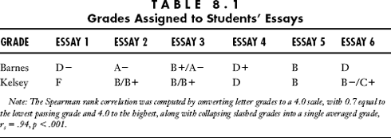

但这种相似性可能具有欺骗性。尽管两位老师的评分几乎相同，但他们对这些评分的理解却截然不同。当被问及“您对本班学生的理解程度有何总体评价？”时，巴恩斯先生回答说：

But such similarities can be deceiving. Although the teacher's grades were nearly identical, the meanings they gave to these grades were not. In response to the question, “What is your general assessment of the understanding of the students in this class?” Mr. Barnes answered:

嗯，我们一共收到了六篇作文。一篇A-，一篇B+，一篇D-，一篇D+，一篇B，没有C；不过，我觉得如果给这些成绩赋予某种数值系数并取平均值，这看起来就像是一个中等水平的班级……能力分布呈钟形曲线是合理的。

Well, we had six essays. One A—, B+, D—, D+, B, no Cs; however, I think if one were to give those some kind of numerical coefficient and average them out, it looks like an average class to me…. The bell-shaped curve of distribution of abilities makes sense.

对于同样的问题，凯尔西回答说：

To the same question, Kelsey responded:

我感觉这些学生认为理解历史就是死记硬背大量信息，复述一系列事实。他们很少提问，也没有任何解读——只是根据他们目前掌握的信息进行理解。

I get the impression that these students think that understanding history is memorizing a mass of information, recounting a series of facts. There is not a lot of questioning going on, there isn't any interpretation—just based on what I have now.

我的理论是——这其实并不新鲜——如今的学生写作水平如此糟糕，包括我自己在内……是因为他们除了老师布置的作业之外，几乎什么都不读……他们读书不是为了学习写作技巧，而是为了记住一些考试所需的知识点，好让他们能拿到周末买车的分数，甚至考上理想的大学。但他们根本不关注所给材料的写作风格。而我认为，人们学习写作的方式就是通过阅读。所以，补救措施就是：多读书，写得更好。这就是因果关系。

My own theory is that—it's hardly novel—today's students write so poorly, including this one…because they read hardly anything at all, except for what's assigned…. They do not read for any kind of knowledge about how to write but for remembering a few facts for a test that will get them the grade that they need to get the car for the weekend or maybe even to get into the college of their choice. But they don't pay attention to the style of the writing in the material that they're given. And this, I believe, is how people learn how to write—from reading. So remediation would be: Read more, write better. Cause and effect.

凯尔西女士的看法则不同：

Ms. Kelsey saw things differently:

我重点辅导这个孩子“表达自己的想法”，以及如何更有效地表达……我会引导他如何将自己知道的——脑子里的想法——整理成一个清晰的格式。我猜想，一旦格式更规范，其他方面也会迎刃而解，孩子们就能更好地表达自己真正的想法……从自己的感受开始，因为这是建立自己与信息之间桥梁的绝佳起点……我有时会安排这个孩子和能力更强的孩子结对，或者，如果有机会，我会单独辅导他，了解这种合作方式的效果。我可能还会组织一些小组活动，教全班同学如何列提纲……因为他有很多潜力没有被挖掘出来。

I concentrated with this kid on…“giving yourself a voice” and how can you do that more effectively…. I would work on how to get what you know—what's here in your head—into a format. I suspect that once it was in a better format, other things would begin to fall into place better, and kids could better express what they really know…. Start with their own feelings, start with that because it's a great place to build a bridge between yourself and the information…. I might pair this kid with a more able kid sometimes, or, if I get the chance, work with the kid individually to understand how that would work. Probably do some group work with the class about outlining…because there's a lot of potential here that's not being realized.

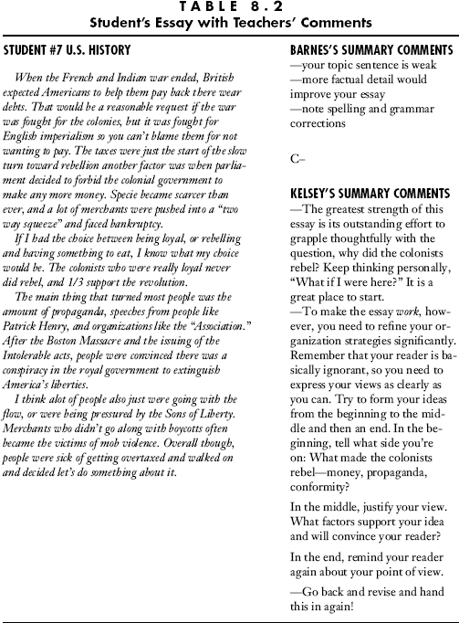

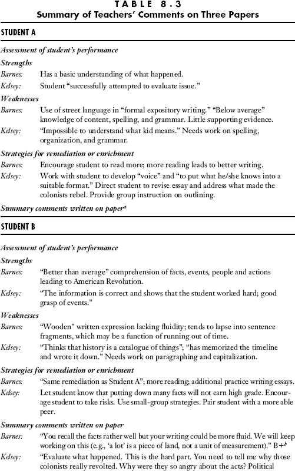

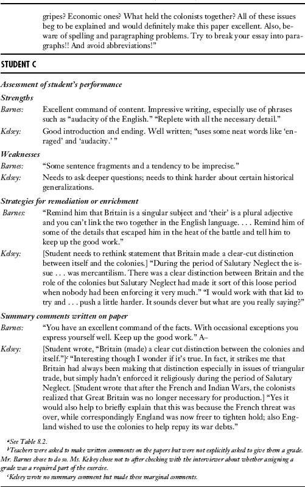

尽管凯尔西并没有忽视作文方面的问题，但她主要关注的是如何提高*历史*论文的质量。在这一环节，教师无需给论文打分，只需为学生提供建设性的反馈即可。巴恩斯先生选择给论文打分，而凯尔西女士没有，这可能表明他们对这项任务的理解有所不同。对巴恩斯先生来说，这些论文或许是等待最终评估的成品；而对凯尔西女士来说，它们或许是需要修改的初稿。事实上，在三个案例中的两个案例中，她都鼓励学生修改论文并重新提交。

While she did not ignore problems of composition, Kelsey focused primarily on making these better *history* essays. In this part of the exercise, teachers were not asked to assign a grade, only to offer constructive feedback to the authors. The fact that Mr. Barnes chose to grade the essays, and Ms. Kelsey did not, may indicate different orientations to this task. For Barnes, these papers may have represented finished products awaiting final evaluations, whereas for Kelsey they may have represented first drafts awaiting revision. Indeed, in two of three cases, she encouraged students to rework their essays and hand them in again.

提出关于教师知识的问题

Raising Questions About Teacher Knowledge

作为了解教师思维的窗口，这些简短的描述揭示了什么？首先，一些相似之处显而易见。两位教师都希望学生提出条理清晰、论证充分的观点。两位教师都希望文章体现良好的写作规范。两位教师给出的分数也惊人地相似，即使有差别，也仅有半分之差。然而，当我们跳出这些表象，审视这些教师的表现时，最引人注目的并非它们的相似之处，而是它们之间的差异。

As windows into teacher thinking, what do these brief sketches suggest? First, there are some obvious similarities. Both teachers wanted students to present organized arguments and supported claims. Both wanted the essays to embody principles of good form. Both awarded grades that showed remarkable similarity, varying, if at all, by half-grade shades of difference. Yet when we stand back from these performances, we are struck not by their similarity, but by their difference.

巴恩斯先生以一位拥有二十七年批改作业经验的专家的自信来处理这项任务。他稳步审阅每份试卷，指出事实错误和拼写错误，并鼓励学生多读书以提升写作水平。事实上，巴恩斯先生流畅的批改方式让人想起教师专业知识文献中经常描述的那种程式化的教学流程。 <sup>28</sup>而凯尔西女士则截然不同，她的批改速度较慢，她的判断也带有保留意见、限定条件和替代假设：这些试卷反映的更多是学生之前的学习情况，还是他们真正的知识水平？如果提供提示和其他辅助材料，学生们是否能写出更好的文章？他们是否能够更好地运用其他媒介来展示自己的知识？凯尔西女士指出，在她自己的课堂上，她会将作文与其他形式的评估（例如制作时间轴和“学习海报”）结合起来，因为很多学生“虽然不太善于用词，但他们的理解能力很强。显然，我希望在课堂上帮助他们更好地运用词汇……但我也会寻找其他方法来帮助他们表达自己。”

Mr. Barnes approached this task with the confidence of someone who has spent twenty-seven years grading papers. He worked steadily through the papers, noting factual and spelling errors and urging students to read more so that they will write better. Indeed, Barnes' fluid approach recalls the kind of scripted processing often described in the literature on teacher expertise.<sup>28</sup> Ms. Kelsey, on the other hand, proceeded slowly, and her judgments carried hedges, qualifications, and alternative hypotheses: Do the papers tell us more about student's prior instruction than what they really know? Might students have written better essays with prompts and other supports? Would they have been better able to display their knowledge using other media? Indeed, Kelsey noted that in her own classroom she combines essays with other forms of assessment (such as making timelines and “learning posters”) because many students “don't use words well but they really understand a lot. And obviously I want to help them use words in my class…but I also find other ways to help them express themselves.”

仅凭这些表现很难找出这些差异的根源。在此，我们提出一系列可能解释这些差异的假设。

With only these performances to go on, it is difficult to locate the source of these differences. Here we sketch out a series of hypotheses that might account for them.

*假设A：教师对学生和教师的角色和责任持有不同的观点*。这些表现差异可能是由于……由于教师对自身和学生的角色与责任有着不同的理解，巴恩斯可能会要求学生对获取教师提供的信息负责。如果学生认真听讲，他们就能学到所需的内容。如果学生关注作者的写作风格，他们就能成为更好的读者和写作者。在这种观点看来，教学遵循一条清晰的路径：引导学生阅读优秀的书籍，并让他们专注于作者的写作风格；要求他们在写作作业中展现所学知识；纠正事实和风格上的错误。

*Hypothesis A: The teachers hold different beliefs about the roles and responsibilities of students and teachers*. These differences in performance may be due to teacher's different conceptions of the roles and responsibilities of teachers and students. Barnes might hold students accountable for acquiring the information teachers provide. If students pay attention, they will learn the content they need. If students pay attention to author's styles, they will become better readers and writers. In this view, teaching follows a straight path. Direct students to good books and focus their attention on the author's writing. Require them to demonstrate their knowledge in writing assignments. Correct errors of fact and style.

另一方面，凯尔西女士可能认为学生在学习和写作历史方面存在困难。他们可能存在一些不完整的概念，需要加以挑战。他们可能不熟悉如何阅读和撰写议论文。他们可能不习惯创新和个性化的思考。在这种观点看来，教师有责任创造一个支持学生尝试自我表达和新学习方式的环境。

Ms. Kelsey, on the other hand, may believe that students struggle to learn and write about history. They may possess incomplete conceptions that need to be challenged. They may be unfamiliar with reading persuasive prose and composing persuasive essays. They may be uncomfortable with innovative and personal thinking. In this view, teachers are responsible for creating environments that support student experimentation with self-expression and new forms of learning.

*假设B：两位教师持有不同的学习理论*。一个相关的假设是，两位教师持有不同的学习理论。巴恩斯先生或许认为学习是通过接触和吸收实现的。只要学生有足够的时间接触学习材料（并被鼓励练习），他们最终就能吸收所需的知识。凯尔西女士似乎认为知识是建构的，而非吸收的，学生在建构历史理解方面需要帮助。

*Hypothesis B: The teachers hold different theories of learning*. A related hypothesis is that the teachers hold different theories of learning. Perhaps Mr. Barnes believes that learning comes about through exposure and absorption. Provided that students are exposed to materials for sufficient periods (and encouraged to practice), they will, eventually, absorb what they need to know. Ms. Kelsey seems to believe that knowledge is constructed, not absorbed, and that students need help in constructing their historical understandings.

*假设C：教师们对历史课程的理解存在差异*。这些差异可能部分源于教师们对历史课程理解的不同。巴恩斯纠正了一些事实错误，例如将英国东印度公司和西印度公司混淆，这些错误不太可能让大多数学生感到困扰，但在他看来，这些错误“至关重要”。为了确保学生掌握正确的事实，他划掉了一篇作文中的“一大堆茶叶”（学生写的是“殖民者……把一大堆茶叶从船上推下去”），并用铅笔写上了“342箱”。虽然凯尔西女士也纠正了事实错误，但她似乎更关注她所说的“大局”。她将评论的重点放在这些作文缺乏解读和分析上，而不是事实内容本身。教师评论中不同的侧重点可能反映了他们对学生应该了解的历史类型的不同看法。

*Hypothesis C: The teachers hold different conceptions of the history curriculum*. These differences might be partially accounted for by the teacher's different conceptions of the history curriculum. Barnes corrects factual errors unlikely to cause anguish to most students, such as mixing up the British East and West India Companies, but in his opinion such errors make “all the difference in the world.” Committed to insuring that students have their facts straight, he crossed out the words “a whole bunch of tea” in one essay (the student had written, “The colonists…pushed a whole bunch of tea off a boat”) and penciled in “342 chests.” Although Ms. Kelsey also corrected factual errors, she seemed more concerned with, in her words, the “big picture.” She focused her comments on the lack of interpretation and analysis in these papers, rather than on their factual content. The different emphases in teacher's comments may reflect different beliefs about the kind of history that is most important for students to know.

*假设D：教师们对历史知识的潜在理解不同*。假设C可以被视为每位教师对历史理解的副产品。如果巴恩斯先生认为事实知识和细节——有趣的人物和事件的罗列——*才是*历史知识的重点呢？如果凯尔西女士更多地思考约瑟夫·施瓦布（Joseph Schwab ）<sup>29</sup>所说的历史的“句法结构”呢？例如，历史知识是如何被创造和论证的，解释和论证所扮演的角色，证据的谬误，以及如何运用证据来构建论证？

*Hypothesis D: The teachers have different underlying conceptions of historical knowledge*. Hypothesis C could be viewed as a by-product of each teacher's understanding of history. What if Mr. Barnes believes that factual knowledge and detail—catalogues of interesting people and events—*are* the focal points of historical knowledge? What if Ms. Kelsey thinks more about what Joseph Schwab<sup>29</sup> called the “syntactical structures” of history: how historical knowledge is created and justified, the roles played by interpretation and warrant, the fallacies of evidence, and the use of evidence to craft arguments?

这四个假设或许可以部分解释我们观察到的差异。但这项练习仅仅让我们对教师的知识、信念和技能领域有了初步的了解。为了拓宽我们的视野，我们接下来将进行下一个练习。

These four hypotheses could account in part for the differences we observed. But this exercise provides only a glimpse into the world of teacher knowledge, belief, and skill. To broaden our vision, we turn to the next exercise.

练习2：文献资料的使用

EXERCISE 2: USE OF DOCUMENTARY MATERIALS

描述

Description

在“文献资料运用”练习中，<sup>30</sup>教师有30分钟时间审阅一份包含8篇文字资料和3幅图片资料的资料包，内容涉及列克星顿和康科德战役。文字资料包括一手和二手资料；图片展示了战役的三种不同版本，分别绘制于不同的时期。30分钟后，教师们接受了访谈，讨论他们将如何在课堂上运用这些资料。他们还被要求评论这些资料“讲述了怎样的故事，以及它们与我们国家历史有何关联”。

In the Use of Documentary Materials exercise,<sup>30</sup> teachers were given thirty minutes to review a packet of eight written and three pictorial documents about the battles of Lexington and Concord. The written materials included primary and secondary sources; the pictures showed three versions of the battles, each painted at a different time. After thirty minutes, teachers were interviewed about how they might use these materials in the classroom. They were also asked to comment on what “story [the documents] tell and how they bear on our nation's history.”

教师的回应

The Teacher's Responses

*巴恩斯**先生*。采访开始了：

*Mr. Barnes*. The interview began:

*面试官：*首先，您能否简要描述一下您可能会在教学中使用这些材料的一些方法？

*Interviewer:* First, could you briefly describe some ways that you might use some of these materials in your teaching?

*巴恩斯先生：*嗯，首先，我*不会*在普通历史课上使用这些教材。但我可以在AP课程中使用，因为我认为它们的阅读难度对于我教的普通高中生来说太高了。我知道我的AP学生虽然会反对其中的模糊之处以及需要他们做出选择和判断，但他们最终还是能够理解。他们更希望老师直接告诉他们发生了什么，然后他们自己记住就好。

*Mr. Barnes:* Well, to begin with, I *wouldn't* use them in my regular history classes. But I could use them in my AP classes because I think the reading level is too difficult for the typical average high school student that I deal with. I know that my AP students could deal with it even though they would object to the ambiguity and to the fact that they would have to make some choices and judgments. They would rather just be told what happened and then remember it for the test.

巴恩斯先生进一步解释说，对于他那些才华横溢的学生来说，文献可以提供“对历史研究的真正意义的体会”。

For his able students, Mr. Barnes elaborated, documents could provide “a flavor of what historical research is all about.”

我会首先告诉他们，历史并非总是像教科书上描述的那样简单明了。他们学习的时间越长，历史课上得越多，就越有可能对某些历史事件的真相感到困惑，尤其是那些涉及冲突和分歧的事件，比如动机、原因等等。史学研讨会通常会探讨这个问题。如果他们决定主修历史，那么可以肯定的是，在完成历史学习之前，他们会多次用到这类方法。但即使对于那些不继续深造历史、不选修史学课程的人来说，证据的冲突也蕴含着重要的意义：人们必须能够阅读事件的文字或图片，并判断某些事件的有效性、相对重要性或价值。

I would lead off by telling them that history is not always as simple as it may seem from reading about it from a textbook in terms of what actually happened. And that the longer they stay in school and the more history classes they take, the more confused they may become as to the true nature of certain events in our history, especially events involving conflict and disagreement in terms of motive and causation and so on. This is often explored in seminars on historiography. And if they decide to become history majors, they can rest assured that this type of technique is something that they will use numerous times before they get through with their study of history. But even for those who don't go on and study history at an advanced level and take courses in historiography, there's a good lesson here in the conflict of evidence, that people have to be able to read about events, or to be able to look at pictures about events and make choices as to the validity, the relative weight or merit, of certain kinds of events.

当被问及他将计划哪些课堂活动时，巴恩斯将重点放在了谁在列克星顿打响了第一枪这个问题上：

When asked about classroom activities he would plan, Barnes focused on the question of who fired the first shot at Lexington:

所有学生都可以在课堂上或作为家庭作业阅读所有书面文件和图片资料。然后，第二天我们可以就此展开讨论……哪一方先开火？是殖民者先开火，还是根本无法确定？……还有很多其他方法。你可以使用拼图活动<sup>31</sup> ……你可以让孩子们阅读这些资料，然后测试他们能找出两种基本观点和两种基本差异。或者你可以让阅读过所有资料的学生分别做口头报告，讲述他们认为发生了什么以及为什么会发生。你还可以让他们写一篇论文，比如研讨会论文……尝试得出某种结论，说明哪些证据似乎更有效，为什么，以及他们尽可能准确地推断事件的本质……所以，基本上，你可以将内容分解成几个部分，让学生分别阅读资料，然后向小组或全班汇报；或者让所有学生阅读所有资料，然后在课堂上对每份资料进行概括性的分析。先从其中一个开始，然后把剩下的都看完。我觉得它们各有优点。

All of the students could read all of the written documents and the pictorial documents during a class period or as a homework assignment. And then, the following day, we could have a discussion about them…. Which [side] fired first? Did the colonists fire first or was it impossible to know?…There's all kinds of other ways. You could use a jigsaw activity<sup>31</sup>…you could simply have kids read these and give them a test as to what were the two basic points of view, the two basic differences. Or you could have oral reports, individualized oral reports from kids who have read all of these, what they think happened and why they think it happened. You could have a paper, like a seminar paper…trying to reach some kind of conclusion as to what evidence seems more valid and why and their conclusion about the nature of events as near as they can determine…. So basically it's either break it up into component parts with individual students taking documents and reporting either to groups or to the whole class, or all students reading all documents and then a generalized dissection of each one during class time. Just start with one and go through the rest of them. I think they both have merit.

当被问及如果有些学生不理解文件的要点他会怎么做时，巴恩斯先生说他会采用“传统的教学方法。如果他们猜不出来，我就告诉他们。”

When asked what he would do if some students didn't understand the main points of the documents, Mr. Barnes said he would use the “good old didactic approach. If they can't guess, I'll tell them.”

*凯尔西**女士*。巴恩斯先生则专注于他最优秀的学生。凯尔西女士为不同能力水平的学习者开发了这些文件的多种用途。她说，这些文件提供了

*Ms. Kelsey*. Mr. Barnes focused on his most able students. Ms. Kelsey generated multiple uses of these documents for learners at various ability levels. She said that the documents offer

这是一种绝妙的方式，能让孩子们开始从历史的角度思考究竟发生了什么……这不仅能锻炼他们的精确性，还能让他们思考我们对历史的解读会如何受到我们自身观点的影响。[这]也是让孩子们接触当时的语言和人们的认知的好方法。让他们真正深入其中，仔细琢磨，并且……首先要培养一些关键技能，以便判断事情的真相。同时也要探究不同说法之间的差异及其原因。[其中一个目的]让我眼前一亮的是历史诠释以及随着时间推移，我们的诠释中出现的偏见问题……我会从不同的观点入手，探讨每种观点如何运用偏见来论证自身……这里也蕴含着一个情感目标，那就是让学生真正沉浸其中，亲身体验……我会鼓励孩子们这样做，思考他们自身对所处世界的认知。这与当今新闻报道中的偏见问题有着很好的联系。这也可以成为他们记录自身经历的练习……如果要给技能层级排序，我认为这项技能的难度略低于评估偏见，具体从哪里入手则取决于学生的水平。对他们中的很多人来说，语言理解能力很模糊，不够精确，这种答案可以蒙混过关，勉强拿到及格分，但却无法真正深入地展现事件真相。对于水平较低的学生，我可能会让他们思考一会儿。哪份文件能最详细地讲述事件的真相……我可以结合一个练习，让他们对某个事物进行解释。而对于能力很强的学生——实际上，我可以采用多种方式，将作业分成几个难度级别——我会鼓励他们引用文件内容，并尝试展开论证。如果是AP学生，这将是一个很棒的基于文件的分析题（DBQ）。

a fabulous way to get the kids to start to think historically about what really happened…. It's a good exercise in precision and certainly in point of view on how our interpretations of history would be altered by our points of view upon it. [It would] be a great way to get kids to work with the language of the time and the perceptions that people had. To really get down and mess with it, and start working on some critical skills in determining what really happened. But also how each account might vary and why. [One purpose] that just jumps out at me is the question of historical interpretation and bias that appears in our interpretations over time…. I'd start with the points of view and how each point of view uses bias to make its case…. There's an affective goal there, too, that the students should really get in and really experience that as well…. I would encourage kids to do that, to think about their own perceptions of reality in the world they experience. It could be a wonderful tie-in to the contemporary bias in journalism. It could also be an exercise in recording precisely what they have experienced…. If I were going to think about a hierarchy of skill, I think it's a little lower on the hierarchy than trying to assess bias, and it would depend on the level of my kids where I'd start working. For a lot of them, their sense of language is so fuzzy and imprecise, something that you can slide past the teacher and get an okay grade on, rather than giv[ing] people a juicy sense of what happened. With a lower level set of kids, I might just let them think for awhile. Which [document] really tells you with the most detail what really happened…. I could couple that with an exercise where they build an explanation of something. And then with very able students—no, actually, I could do this in a variety of ways and make the assignment in a couple of tiers—I might encourage kids to then quote from documents and try to develop an argument. It would be a great DBQ [Document-Based Question] if it were AP kids.

在凯尔西女士看来，这些文献展现了丰富的课程和教学可能性（见表8.4）。她同意巴恩斯先生的观点，即原始文献对大多数学生来说都是挑战，但她对这种挑战在教学上的意义持有不同看法。文献带来的问题会让巴恩斯先生望而却步，他只会将其用于能力最强的学生。而凯尔西女士则会将其用于所有学生，并根据学生不同的能力、经验和兴趣，设计不同“层次”的活动。她对文献给低水平学生、高水平学生甚至教师带来的困难都心知肚明（正如她下文的评论所表明的那样）。但她相信，如果教师首先“搭建桥梁”，让学习者能够接触到历史的原始素材，那么学生就能克服这些困难。

To Ms. Kelsey, these documents presented a range of curricular and pedagogic possibilities (see Table 8.4). She agreed with Mr. Barnes that original documents challenge most students but disagreed about the instructional implications of this challenge. The problems posed by documents would deter Mr. Barnes from using them except with his most able students. Ms. Kelsey, on the other hand, would use them with all students, but would craft activities at different “tiers” for students of varied abilities, experiences, and interests. She held no illusions about the difficulties documents pose for lower-level students, higher-level students, and even teachers (as her comments below attest). But she believed that students can overcome these difficulties if teachers first “build bridges” that allow learners to engage with the raw material of history:

第一天，我会先安排一个练习，练习内容是关于精准观察……我会先搭建一个桥梁，然后谈论一些时事新闻……我会结合学生的个人经历：比如，你今天早上起床后发生了什么？上周我们参加的集会发生了什么？诸如此类，一些我们可以讨论的话题。其他孩子可能会读报纸或看新闻……我会以此为桥梁，回到我们之前讲过的目击者证词，我会先分析每个证词的内容，然后让他们逐条讨论。就像我刚才做的那个练习一样。我会让他们讨论文件的内容。他们必须总结自己确定的事实。区分事实和推断相当有难度……我参加过一个研讨会，看到很多老师在这方面都磕磕绊绊，如果我们都做不到，我知道孩子们肯定也做不到……我会让他们合作……也许可以两人一组。最多三个。这……相当有挑战性，有些孩子可能很难总结文件的内容。但我认为几乎每个人都能问一两个问题，而且这很有趣。所以我会一步步讲解，和孩子们一起深入理解，让他们做一个图表。然后我会分析谁更值得信任。我会添加一些英国方面的文件，这样你就可以真正深入其中，再次体验。你可以让孩子们进行角色扮演……我会以一篇作文作为活动的总结。

The very first day I would start with an exercise that does talk about precise observation…. I would start by building a kind of a bridge and I would talk about something in contemporary events…. [I'd] work with [student's] own personal experience: What happened this morning when you got out of bed? When we had the assembly last week that we all went to? Something like that, something that we could discuss. Other kids read the newspaper or watch the news…. I'd use that as my bridge and I'd go back to this episode where we have these eyewitness accounts, and I would start by looking at what each account said and I would probably have them go through something like [the exercise] I just went through. I would have them talk about what the documents said. They have to summarize the facts that they know for sure. That's pretty hard work there, the difference between a fact and an inference…. I was in a seminar where I saw a bunch of teachers stumbling over that, and if we stumble, I know that the kids will…. I would have them cooperate…partners, perhaps, comes to mind. Three at the most. This is…pretty intense, and certain kids are going to have trouble summarizing what the document said. But just about everybody I think can usually ask a question or two, and they're pretty fun. So I would go through that, and I would really build that with the kids and have them build a kind of chart. Then I would analyze who can you trust more. I would add some more documents from the British point of view and then you could really get in and re-experience that some more. You could have the kids enact them…. I would culminate the activity with an essay of some kind.

查阅文件，重新审视假设

DOCUMENTS STUDIED, HYPOTHESES REVISITED

两位老师的教学计划中，学生都需要阅读和讨论文献资料。他们可能会进行辩论，也会进行一些写作。巴恩斯先生计划布置学生将文献资料作为家庭作业，或者在课堂阅读作业中使用。学生阅读文献后，会在课堂上进行讨论，或者互相汇报。

In both teacher's plans, students would read and discuss documents. They might engage in debate and would do some kind of writing. Mr. Barnes planned to send students off to work with documents as homework, or perhaps use them during an in-class reading assignment. After students read the documents they would discuss them in class or report back to each other.

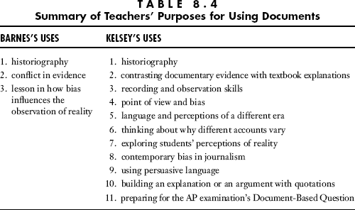

凯尔西女士的出发点则有所不同。列克星顿战役发生在很久以前，学生们可能难以理解。将个人经历与过去联系起来。或许她需要从更直接的事物入手——比如学生自身的经历，或者他们在电视上看到的内容。此外，学生和成年人一样，难以区分事实和推论，可能需要审视自己的假设。他们或许需要练习如何质疑证据的可靠性。鉴于这些材料的复杂性，她会将学生分成小组，并布置一系列任务，以便所有学生都能参与其中。

Ms. Kelsey began with a different set of premises. The Battle of Lexington took place a long time ago, and students might have difficulty making personal connections to the past. Perhaps she would need to begin with something more immediate—either student's own experiences or something they have seen on television. Moreover, students, like adults, have trouble distinguishing fact from inference and may need to examine their assumptions. They might need practice in asking questions about the trustworthiness of evidence. Because of the complexity of these materials, she would put students into small groups and provide them with a range of tasks so that all students could participate.

两位老师都认真思考了如何在课堂上使用教学材料。她们都考虑到了学生的能力和学科内容。那么，为什么她们对这些材料的用途以及可能使用的活动类型却有如此不同的看法呢？

Both teachers thought hard about using documents in their classrooms. Both took into account student abilities and subject matter. Why, then, did they think so differently about the purposes of these documents and the kinds of activities they might use?

在第一次练习之后，我们推测两位老师可能对历史知识持有不同的理解（假设D）：巴恩斯先生认为历史主要关乎事实，而凯尔西女士则认为历史具有解释性和视角性。但在这里，两位老师的观点却出奇地相似。巴恩斯先生曾说过，历史“涉及大量事实的筛选、大量数据的解读，然后做出尽可能合理的推测”，并将这一过程比作“引人入胜的侦探故事”。这些评论为假设D提供了新的视角。两位老师似乎都认识到历史知识的解释性本质、证据的核心地位以及视角的影响。从这个意义上讲，两位老师的观点比我们最初预想的更为相似。

After the first exercise, we speculated that the two teachers might hold different conceptions of historical knowledge (Hypothesis D), with Mr. Barnes seeing history as primarily about facts and Ms. Kelsey seeing it as interpretative and perspectival. But here the two teachers sounded alike. At one point, Mr. Barnes remarked that history “involves a lot of sifting of facts, a lot of interpretation of data, and then making the best educated guess possible” likening the process to a “fascinating detective story.” These comments shed new light on Hypothesis D. It seems that both teachers recognize the interpretative nature of historical knowledge, the centrality of evidence, and the influence of point of view. In this sense there is greater similarity in the teacher's views than we originally thought.

尽管巴恩斯和凯尔西对历史知识的复杂性可能持有相似的观点，但他们对学校历史的本质却持有不同的看法（假设C）。巴恩斯先生似乎将学校历史分为两种：一种是面向普通学生的、包含事实和事件的历史；另一种是面向立志上大学的学生的、包含事实和事件，但同时又包含对历史知识诠释性方面的理解的历史。因此，教学计划就变成了一个匹配过程，教师首先判断学生的能力，然后找到学生能够掌握的材料。历史知识由事实和诠释两部分组成。事实知识先于诠释知识，而根据巴恩斯先生的说法，能力较弱的学生可能永远无法接触到历史的诠释性层面。

Although Barnes and Kelsey may hold parallel views about the complexity of historical knowledge, they differ in their beliefs about the nature of school history (Hypothesis C). Mr. Barnes seems to think of school history in two ways: a history of facts and events for average students; and a history of facts and events, with some understanding of the interpretative aspects of historical knowledge, for the college-bound. Instructional planning, then, becomes a matching process in which teachers make judgments about student's ability and then locate materials students can handle. Knowledge of history comes in blocks of facts and interpretations. Factual knowledge precedes knowledge of interpretation, and less able students, according to Mr. Barnes, may never reach the interpretative side of the subject.

尽管她就读的高中也按能力分班，但凯尔西女士对历史课程有着不同的看法。她认为她本科学习的历史与她现在就读的历史之间有着密切的联系。她教的是青少年。在她看来，事实知识和诠释密不可分，二者交织在一起，无法分割。当然，凯尔西会根据学生的能力调整作业和活动，但这些调整都服务于一个共同的目标——让*所有*学生都参与到诠释历史的过程中来。

Though her high school also tracks by ability, Ms. Kelsey embraces a different view of the history curriculum. She sees a close connection between the history she studied as an undergraduate and the history she teaches adolescents. In her view, factual knowledge and interpretation are bound together, so interwoven that it is impossible to disentangle the two. To be sure, Kelsey modifies her assignments and activities according to her student's ability, but these variations serve a common goal—engaging *all* students in the process of interpreting the past.

我们从本次练习中进一步看到了对假设B（学习理论）的支持。与之前的练习一样，巴恩斯先生多次提及接触/吸收学习理论。学生只要认真聆听并注意教师“呈现”、“传达”和“讲述”的主题，就能学习。另一方面，凯尔西女士则反复强调建立历史与学生生活之间的联系，以及创造情境帮助学生理解过去与现在的关联。然而，我们很难说这些差异源于教师对学习的信念，还是源于他们对历史知识的概念化（假设D），因为两者往往相辅相成。如果知识是预先包装好的，那么教学就很简单：只需把这些“包装”传递给学生即可。但如果知识是动态的，教师就不能简单地传授预先包装好的事实，因为理解这些“事实”在很大程度上取决于理解它们所嵌入的不断变化的解释框架。

We see further support in this exercise for Hypothesis B (learning theories). As in the previous exercise, Mr. Barnes made numerous references to an exposure/absorption theory of learning. Students learn if they listen and pay attention to the topics teachers “present” “get across” and “tell.” Ms. Kelsey, on the other hand, repeatedly emphasized the building of connections between history and student's lives, and the need to create situations that help students see the relevance of past to present. Yet it is difficult to say whether these differences stem from teacher's beliefs about learning or conceptualizations of historical knowledge (Hypothesis D), for the two go hand-in-hand. If knowledge comes prepackaged, teaching is straightforward: Just deliver the packages. But if knowledge is dynamic, teachers cannot simply hand over prepackaged facts, for understanding these “facts”rests in no small measure on understanding the ever-shifting interpretative frameworks in which they are embedded.

这项练习的数据也有助于我们扩展假设A（角色与职责）。在分析凯尔西女士的教学计划时，我们注意到她的学生也会阅读文献资料，但她会先示范如何质疑这些文献。她会引导他们理清错综复杂的史学脉络，因为她深知他们很容易迷失方向。另一方面，巴恩斯先生的学生可能会把阅读文献作为家庭作业或在课堂上使用，但无论哪种方式，他们几乎不会为这项作业做任何准备。巴恩斯先生假定学生会自行探索文献；而凯尔西女士则认为，为学生提供理解文献的途径是她的责任。

Data from this exercise also help us to expand Hypothesis A (roles and responsibilities). In analyzing Ms. Kelsey's plans, we noted that her students would also read documentary materials, but first she would model for them how she might question the documents. She would lead them through the tangle of historiography, knowing full well how easily they can lose the trail. Barnes' students, on the other hand, might read documents for homework or use them during class, but either way, they would receive little preparation for the assignment. Mr. Barnes assumes that students will navigate their own way through the documents; Ms. Kelsey assumes that it is her responsibility to provide stepping-stones along the route.

基于这些数据，我们提出了另一个假设。我们在此次实验中发现的差异，或许与其说是学习理论或角色观念的差异，不如说是教师教学内容知识的差异。这种教学内容知识是学科知识与学习者知识的交汇点，李·舒尔曼（Lee Shulman） <sup>32</sup>将其描述为“教师的独特领域”（我们将这种可能性称为假设E）。教学内容知识的本质在于转化，即教师将学科知识转化为能够弥合已知与未知之间鸿沟的表征的过程。他们希望学生们能学到东西。我们注意到巴恩斯先生的教学计划只有几处改动。而凯尔西女士的教学计划则在内容上进行了多种多样的调整。

Still another hypothesis emerges from these data. The differences we found in this exercise might have less to do with theories of learning or conceptions of role than with differences in teacher's pedagogical content knowledge, the intersection of subject matter knowledge and knowledge of learners that Lee Shulman<sup>32</sup> characterized as the “unique province of teachers” (We refer to this possibility as Hypothesis E.) The essence of pedagogical content knowledge is transformation, the process by which teachers turn their subject matter knowledge into representations that bridge the chasm between what they know and what they want their students to learn. We noted only a few transformations in Mr. Barnes' plan. Ms. Kelsey's plans, on the other hand, displayed varied transformations of content.

教学内容知识也包括教师预测学习内容对学习者而言可能难易程度的能力。巴恩斯先生意识到这些材料的难度，因此只允许AP学生使用，但他似乎并未意识到这些材料对能力强的学生——即使是那些SAT成绩高、GPA好、学科成绩优异的学生——也构成了巨大的挑战。相比之下，凯尔西女士指出，即使是教师也可能在处理这些材料时遇到困难。为了简化任务，她会删除重复的材料，并将学生分成两人或三人小组进行合作学习。<sup>33</sup>

Pedagogical content knowledge also embraces teacher's ability to anticipate content likely to prove difficult or easy for learners. Aware of the difficulty of these materials, Mr. Barnes restricted their use to AP students, but he showed little awareness of the formidable challenges these documents present to able students—even those with high SAT scores, good grades, and high scores on subject matter achievement tests. In contrast, Ms. Kelsey noted that even teachers can have trouble with documents. To simplify the task, she would eliminate redundant documents and arrange students into pairs or trios to work collaboratively.<sup>33</sup>

我们不禁思考，对教学内容知识的关注本身是否体现了更深层次的问题。因此，我们重新审视并修正了假设D（历史知识）。巴恩斯是否可能因为没有意识到准备活动所带来的智力挑战而没有进行相关设计？同样地，凯尔西是否因为作为历史学家，比巴恩斯更关注语言倾向、偏见和视角转换等问题，所以才设计了相关活动？事实上，凯尔西会核实证据、推测文献的来源、提出多个相互竞争的假设，并提炼出能够捕捉证据模式的主题，而巴恩斯先生却只谈到了文献中的一个维度：谁先开枪的争论。尽管巴恩斯和凯尔西可能都将历史视为“侦探工作”，但至少在这个例子中，凯尔西似乎是一位更精明的侦探。

We wonder whether the focus on pedagogical content knowledge is itself a manifestation of something still deeper. And so, we revisit and recast Hypothesis D (historical knowledge). Is it possible that Barnes did not plan preparatory activities because he was not aware of the intellectual challenges they presented? Correspondingly, did Kelsey craft activities on slanted language, bias, and perspective-taking because she was more attuned to these aspects, qua historian, than Barnes? Indeed, whereas Kelsey corroborated evidence, speculated about the origins of documents, raised multiple competing hypotheses, and generated themes that captured patterns in the evidence, Mr. Barnes talked only of a single dimension in the documents: the dispute over who fired the first shot. Although Barnes and Kelsey may both view history as “detective work,” Kelsey appears—at least in this exercise—to be the shrewder detective.

我们意识到，造成这些差异还有其他原因。或许凯尔西女士更加努力，或许巴恩斯先生只是粗略浏览文件，而没有仔细阅读。我们无法从现有数据中得知这些。因此，我们将这组假设带到第三个也是最后一个练习中。

We recognize that there are other ways to account for these differences. Perhaps Ms. Kelsey tried harder. Perhaps Mr. Barnes skimmed documents instead of reading them carefully. We cannot know this from our data. And so we bring our set of hypotheses to the third and final exercise.

练习3：教材分析

EXERCISE 3: TEXTBOOK ANALYSIS

描述

Description

在三个小时的教材分析练习中，<sup>34</sup>*教师评估了保罗·托德和默尔·柯蒂斯广为使用的《美国民族的崛起》*一书中的一段节选*。<sup>35</sup>*我们要求他们设想这本书的内容。一个城市学区正在考虑采用该方案，他们的任务是

During the three hours of the Textbook Analysis Exercise,<sup>34</sup> teachers evaluated a selection from Paul Todd and Merle Curtis' widely used *Rise of the American Nation.<sup>35</sup>* We asked them to imagine that the book was being considered for adoption by an urban school district and that their task was to

提供*坦诚的评价*……思考以下几个方面：教科书所呈现的历史的可靠性、该书对学生的吸引力、写作质量、该书作为提高社会研究技能的工具的潜力、该书对不同类型学生的适用性、其总体优势和劣势，以及任何其他与该书可能被采用相关的信息。

provide a *candid review*…. Think about such aspects as the soundness of the history the textbook presents, the book's appeal to students, the quality of the writing, the book's potential as a tool for enhancing social studies skills, the book's appropriateness for different kinds of students, its general strengths and weaknesses, and any other information relevant to its possible adoption.

为了使分析更有针对性，教师们被要求重点关注美国革命的三个子主题：(a) 少数族裔和女性的角色；(b) 波士顿惨案；(c) 税收和代表权问题。教师们收到了选定的文本、配套教师手册的节选（包括现成的练习题和测试示例）以及一份包含问题和充足答题空间的答题表。示例问题包括：“就历史学的最新研究成果而言，该文本如何？”“不同阅读水平的学生可能会对文本有何反应？” “该文本是否适合历史/社会研究课堂中使用的不同教学方式？”一系列简短的问题引导教师关注文本的特定部分。本次练习不包含访谈环节。

To provide a focus for the analysis, teachers were asked to give special consideration to three subtopics of the American Revolution: (a) the role of minorities and women; (b) the Boston Massacre; and (c) the issue of taxation and representation. Teachers received the text selection, a short excerpt from the accompanying teacher's manual (including examples of ready-made worksheets and tests), and a response form with questions and ample space to write answers. Sample questions included the following: “How does the text measure up with regard to recent scholarship in history?” “How might students of different reading levels react to the text?” “How appropriate is the text for the different types of teaching styles used in history/social studies classrooms?” A series of shorter questions directed teachers to specific sections of the text. This exercise did not include an interview component.

教师的回应

The Teacher's Responses

最基本的一点是，两位教师的写作量不同：凯尔西女士写了1892个字，巴恩斯先生写了1001个字。然而，我们意识到，回答的字数并不等同于回答的深度或广度。 <sup>36</sup>在分析教师的回答时，我们发现他们在以下几个方面存在分歧：(a) 文本所呈现的历史的可靠性；(b) 这本书对学生理解的影响；(c) 教师手册中练习题和活动的教学实用性。

At the most basic level, the two teachers differed in how much they wrote: 1,892 words for Ms. Kelsey, 1,001 words for Mr. Barnes. We were aware, however, that length of response is not equivalent to depth or breadth of response.<sup>36</sup> In analyzing the teacher's responses, we found that they disagreed on (a) the soundness of the history presented by the text, (b) the book's effect on student understanding, and (c) the pedagogical usefulness of the worksheets and activities in the teacher's manual.

*文本的历史可靠性*。在评估文本的历史可靠性时，尤其是在其与妇女和少数族裔历史的关联性方面，巴恩斯先生写道：

*Historical soundness of the text*. In evaluating the historical soundness of the text, particularly as it applied to the history of women and minorities, Mr. Barnes wrote:

我认为，本书对少数族裔和妇女在革命中的作用进行了严谨的历史论述，其对这两个群体的关注程度超过了我目前使用的其他教材。我之前使用过的任何教材都没有像《崛起》一书那样，用整整两段篇幅来*论述*“革命中的妇女”……而且，就《崛起》一书所涵盖的三个子主题而言，我也没有发现任何近期学术研究忽略了其他相关*成果。*

I believe that the text presents sound history concerning the role of minorities and women in the Revolution, surpassing the texts I currently use in the amount of attention devoted to these two groups. No text I have used before devoted as much as the two entire paragraphs in *Rise* allotted to “Women in the Revolution”…I know of no recent scholarship which is neglected in *Rise* concerning the three subtopics.

凯尔西女士对此表示反对：

Ms. Kelsey disagreed:

这不过是些老生常谈的煽动性言论，带有典型的白人男性政治史偏见。令人失望的是，书中对近期研究成果的提及如此之少，尤其是像南希·科特（Nancy Cott ）<sup>37</sup>关于殖民地女性的著作，以及一些历史学家关于少数族裔的研究。例如，第97页的奴隶船插图虽然广为人知，我也在其他地方见过，但它并非“唯一一幅写生作品”——不妨查阅当时的奴隶贸易手册，其中详细描绘了如何最有效、最彻底地奴役奴隶，包括手铐和鞭子的精细图解。*这些*资料通常会引发孩子们的思考——相比之下，这幅插图简直就像一艘游轮。此外，尽管书中象征性地提到了克里斯帕斯·阿图克斯（Crispus Attucks），但奴隶贸易以及非裔美国人对殖民地经济和文化的贡献却被一带而过，女性也只是被当作客串角色出现。

This is standard rah-rah stuff, with the bias one generally sees toward white, male, political history. It's upsetting to see so little mention of recent work, especially stuff like Nancy Cott<sup>37</sup> on colonial women or various historian's work on minorities. The illustration [of a slave ship] on page 97, for example, is well-known and I've seen it elsewhere, but it's not true that it's the “only picture drawn from life”—check out slave trading manuals from the period, which show how bodies could be packed most efficiently and subdued—they have detailed drawings of manacles and whips. *That* generally sets the kids thinking—this illustration, by comparison, is like a cruise ship. Also, despite the token reference to Crispus Attucks, the slave trade and Afro-American contributions to the economy and culture of the colonies are glossed over, and women, too, are relegated to cameo appearances.

教师对教科书中关于庞蒂亚克叛乱的描述所作出的反应，更加凸显了这些差异。原文如下：

These differences were thrown into relief by the teacher's responses to the textbook's account of Pontiac's Rebellion. The passage read:

在渥太华族酋长庞蒂亚克的英明领导下，印第安人联合起来，阻止了白人对他们土地的进一步入侵。近一年来，印第安人和白人陷入了殊死搏斗。印第安人摧毁了尼亚加拉以西的大部分英国堡垒。死亡和破坏席卷了整个西部边境。最终，英国和殖民地军队重新夺回了这些堡垒。印第安人接受了宽容的和平条款。庞蒂亚克宣称：“我们将摒弃一切邪恶之事，并彼此努力，看谁能为维护我们之间如此牢固的友谊做出最大的贡献。” <sup>38</sup>

Under the able leadership of Pontiac, an Ottawa chief, the Indians joined forces to prevent any further invasion of their lands. For nearly a year, the Indians and whites were locked in a desperate struggle. The Indians destroyed most of the British forts west of Niagara. Death and destruction raged along the length of the western frontier. Finally, British and colonial troops recaptured the forts. The Indians accepted generous peace terms. Pontiac declared, “We shall reject everything that tends to evil, and strive with each other to see who shall be of the most service in keeping up that friendship that is so happily established between us.”<sup>38</sup>

巴恩斯先生认为这种解释“清晰、准确且符合年级要求”。凯尔西女士再次表示反对：

Mr. Barnes characterized this explanation as “clear, accurate, and grade-appropriate.” Again, Ms. Kelsey disagreed:

糟糕。我很难相信事情会如此美好，而且不幸的是，我的学生们反应太慢，不会对这样的段落提出质疑。第2-4段含糊不清的措辞让人觉得，只有英国和殖民地军队才是秩序（以及美德）的化身。而庞蒂亚克的引言令人作呕，因为它脱离了他当时困境的恰当语境。像摩根的*《美国奴隶制，美国自由*》（1975）这样的著作清楚地表明了殖民者实际施加的残酷暴行。（顺便问一句，那些所谓的“慷慨的和平条款”究竟*是*什么？此外，这些早期的土地冲突巧妙地预示了后来“昭昭天命”的推行——作者却忽略了这一概念。）

Uh-oh. I have a hard time believing things were this rosy and, unfortunately, my students will be all too slow to question a passage like this. The vague passages in paragraphs 2–4 make it sound like only the British and colonial troops were the repositories of order (and by implication virtue). And the Pontiac quote is nauseating, isolated as it is from the appropriate context of his plight. Works like Morgan's *American Slavery, American Freedom* [1975] clearly indicate the cruelty which colonists in fact inflicted. (By the way, what *were* those “generous peace terms”? Also, these early land conflicts neatly presage later pushes for “manifest destiny”—a conceptual opportunity the author ignores.)

*对学生理解的影响*。教师们对这本书对学生理解的影响也存在分歧。针对“这本书在纠正许多学生存在的历史误解方面的有效性”这一问题，巴恩斯先生认为这本书……这段文字在两处“尤其有效”：首先，在波士顿倾茶事件的图片说明中，图片显示袭击发生在白天，但文本提醒读者“实际上袭击者是在夜间偷偷登上船的”； <sup>39</sup> 其次，在波士顿惨案的版画说明中，文本提醒读者“实际上在1770年3月的那天，只有10名士兵和大约60名抗议者发生了冲突”。 <sup>40</sup> 另一方面，凯尔西女士将“学生的误解”解释为她在练习1中提到的关于历史的根深蒂固的普遍观念。她认为这段文字“强化了误解，几乎没有消除误解”，因为“对女性、黑人和美洲原住民文化的糟糕描述会加深学生绝望的信念，即历史就是政治、战争和白人的功绩。”

*Effects on student's understanding*. The teachers also disagreed about the book's effects on student understanding. In response to a question about the text's effectiveness in “addressing the historical misconceptions that many students possess.” Mr. Barnes thought the book was “especially effective” in two places: first, in a caption to a picture of the Boston Tea Party, which has the raid taking place during daylight, the text warns readers that “actually the raiders sneaked on board the ship at night”;<sup>39</sup> and second, in a caption for an engraving of the Boston Massacre, the text alerts readers that “actually there were only ten soldiers and about sixty protesters who clashed on that March day in 1770.”<sup>40</sup> Ms. Kelsey, on the other hand, interpreted “student misconceptions” as the broad, entrenched beliefs about history she referred to in Exercise 1. She saw the text as “reinforcing misconceptions, hardly ameliorating them” because “the poor treatment accorded women, Blacks, and Native American cultures will tend to reinforce student's despairing conviction that history is all politics, wars, and the deeds of white men.”

*补充材料的教学实用性*。这些不同的观点也体现在教师对教材补充材料的评价上。巴恩斯先生写道，这些材料包含*“许多*优秀的技能培养活动和理念”。他唯一的异议是，建议的作文题或许可以采用“客观题的形式”提出。

*Pedagogical usefulness of supplementary materials*. These divergent views carried over to the teacher's evaluations of the text's supplementary materials. Mr. Barnes wrote that these materials contained *“many* excellent skill building activities and ideas.” His sole objection was that a suggested essay question might have been better asked in an “objective format.”

凯尔西女士的态度则不那么积极。例如，两位老师都对一份关于地图绘制技能的练习题做出了回应。<sup>41</sup>这份名为“完成地图：西部土地”的练习题要求学生“标注13个殖民地”，确定“ 1774年《魁北克法案》添加到魁北克的西部领土的南部边界”，并列出“1763年公告线以西未主张土地的五个殖民地”。巴恩斯先生将这份练习题列入他将使用的六项“优秀的技能培养活动”之一。凯尔西女士则不太热情。

Ms. Kelsey was less positive. For example, both teachers responded to a worksheet on mapping skills.<sup>41</sup> Entitled “Completing a Map: Western Lands” this worksheet asked students to “label the 13 colonies” identify “the southern boundary of western territory added to Quebec by the Quebec Act of 1774” and name “the five colonies [that] did not claim land west of the Proclamation Line of 1763” Mr. Barnes listed the worksheet among the six “excellent skill building activities” he would use. Ms. Kelsey was less enthusiastic:

这张地图练习册完全剥夺了孩子们发挥创造力的*机会*，无论是色彩运用、符号设计还是解读。地图过于简略，除了政治信息外，几乎一无所获，因此遗漏了南方主要水道、阿巴拉契亚山脉的重要性、阿迪朗达克山脉和绿山的位置等关键信息。它甚至没有标出波士顿和查尔斯顿。因此，这张地图严重阻碍了学生对殖民地时期多样性和统一性*的初步认知。*

The map worksheet gives kids *no chance* to get creative, whether with color, symbols, or interpretation. The map is also too sketchy to give anything but political information and thus leaves out critical information like the South's main waterways, the importance of the Appalachians, the position of the Adirondacks and Green Mountains. It fails to show either Boston or Charleston. And it thus severely hampers student's embryonic perceptions of *both* diversity and unity in the colonies.

盘点库存

TAKING STOCK

教材分析练习澄清了我们之前的一些猜测，也加深了另一些猜测。例如，“我不知道最近有什么学术研究”这样的评论。“被忽视的”这一观点表明，巴恩斯先生自六十年代以来并未关注美国历史的发展。他似乎对“教科书历史”（即学校教科书中的事实和时间顺序内容）有着广泛的了解，但对历史学家用来赋予历史意义的解释框架却知之甚少。由此可见，两位教师在学科知识方面存在*实质性差异，这进一步印证了假设D（历史知识）。*

The Textbook Analysis exercise clarified some of our earlier hunches and deepened others. Comments such as “I know of no recent scholarship which is neglected” show that Mr. Barnes has not followed developments in American history since the sixties. He seems to have extensive knowledge of “textbook history” the factual and chronological content found in school textbooks, but seems less knowledgeable about the interpretive frameworks historians use to bring meaning to the past. It appears, then, that there are *substantive* differences in the subject matter knowledge of the two teachers, an extension of Hypothesis D (historical knowledge).

或许教师们最激烈的分歧在于该书对女性和少数族裔的处理方式。我们推测，这种分歧源于两位教师评判该书优劣的标准截然不同。巴恩斯先生将这本书与其他教科书进行比较，尤其是他自己使用的两本。凯尔西女士则以不同的标准来评判该书——她将南希·科特关于女性史的著作或埃德蒙·摩根关于奴隶制的著作作为参照。按照这个标准，书中侧边栏和章节末尾对女性和少数族裔的处理方式显得十分粗糙。在练习1之后，我们推测巴恩斯和凯尔西对自身角色和责任的理解存在差异（假设A）。在这里，我们找到了进一步的证据来支持这一论断，尤其关注教师对自身在课程材料方面角色的认知。对巴恩斯先生而言，教师的决策呈现出一种非此即彼的二元性。当他评价这本书的某些方面时，要么称赞其优秀，要么像对待作文题那样，认为应该替换掉。在他看来，教师们要么接受要么拒绝课程材料，却很少对其进行调整和修改。这种观点可以解释巴恩斯在前一次练习中的回答，当时他坚持认为原始文献可以用于AP课程，但不适合普通学生。

Perhaps the teacher's sharpest disagreement concerned the book's treatment of women and minorities. We speculate that this disagreement stemmed from the qualitatively different touchstones each teacher used to judge the book's soundness. Mr. Barnes compared the book with other textbooks, especially the two he uses. Ms. Kelsey held the text to a different standard—works by Nancy Cott in women's history or Edmund Morgan on slavery. Using this standard, the treatment of women and minorities in sidebars and end-of-the-chapter sections seemed shabby indeed. After Exercise 1, we speculated that Barnes and Kelsey hold different conceptions of their roles and responsibilities (Hypothesis A). Here we find further evidence for that assertion but with particular reference to the teacher's perception of their role vis-a-vis curricular materials. For Mr. Barnes, teacher decision making took on a binary quality. When he evaluated some aspect of the book, he either said it was excellent or, as in the case of the essay question, that it should be replaced. In his view, teachers accept or reject curricular materials but do little to adapt and modify them. This view sheds light on Barnes' responses in the previous exercise, when he was adamant that primary documents could be used with AP but not with average students.

凯尔西女士认为课程材料需要进行调整和改造。我们在之前的练习中已经看到这一点，当时她描述了自己修改这套文件的计划。在这次练习中，她阐述了如何调整建议的活动和现成的练习题。例如，她认为练习题22很有价值，这是一份关于福吉谷情况的目击者记录，其中“开始触及一些严肃的问题，比如‘你认为这是一个可靠的信息来源吗？’ ”但她也意识到，如此重要的问题需要进行调整才能交给学生。

Ms. Kelsey sees curricular materials as something to adapt and transform. We saw this in the previous exercise when she described her plans to modify the set of documents. In this exercise, she described how she would mold suggested activities and ready-made worksheets. For example, she saw value in Worksheet 22, an eyewitness account of the conditions at Valley Forge that “starts to get at some serious issues like ‘Do you think it is a reliable source?’ ” But she recognized that a question of this magnitude needed to be adapted before it could be given to students.

或许，教师对“采用本书的利弊”的总结性评论最能体现这些不同的方法。对巴恩斯先生来说，采用本书的主要好处在于“将一本编写精良、内容新颖、适合相应年级的教科书引入课堂”。“把教材和配套的精美材料送到每位老师手中。”主要的缺点在于费用：花这么多钱买书，“学生们可能仍然会拒绝阅读……因为归根结底，它只是一本教科书。”巴恩斯先生倾向于用非黑即白的眼光看待教育决策：应该采用这本书，但学生们不会读它。

Perhaps these different approaches are best exemplified in the teacher's summary comments about the “benefits and drawbacks of adopting this book.” For Mr. Barnes, the chief benefit of adoption would be to “put a well-written, up-to-date, grade-level-appropriate textbook into the hands of students and a fine set of accompanying materials into the hands of each teacher.” The chief drawback would be the expense: spending so much money on books that “students might still refuse to read…because it is, after all, only a textbook.” Mr. Barnes tended to cast educational decisions in black and white: The book should be adopted but students wouldn't read it.

人们或许会认为凯尔西女士不会从采用这本书中获益良多。然而事实恰恰相反，她找到了将书中的不足转化为教学契机的方法：“（这本书）可以被富有创造力的老师以多种方式改编。它的阅读难度适中，信息上的疏漏可以成为宝贵的批判性思维练习，尤其是在补充材料的帮助下。”看来，不同的前提促使每位老师对课程持有不同的态度。对巴恩斯先生而言，课程材料提供的是固定的选项。而对凯尔西女士而言，它们则蕴含着可以根据特定情境和目标进行调整的潜力。

One might imagine that Ms. Kelsey would find few benefits in adoption. On the contrary, she found a way to turn the book's shortcomings into pedagogical opportunities: “[The text could] be adapted in many different ways by a creative teacher. The reading level is reasonable, and glitches in information could be valuable critical thinking exercises, especially with supplementary materials.” Different premises, it seems, motivate each teacher's stance toward curriculum. For Mr. Barnes, curricular materials present fixed options. For Ms. Kelsey, they present potentialities to be shaped to fit particular contexts and goals.

教师的书面评语中还透露出其他一些差异。凯尔西女士对历史与学生学习动机之间关系的敏锐洞察力和关注度在这项练习中再次得到体现，这印证了假设E（教学内容知识）。在评估教师手册中关于学生研究玛丽·沃伦、约翰·汉考克、约瑟夫·沃伦、塞缪尔·亚当斯以及其他美国独立战争人物的建议时，她评论道：“我的学生对研究塞缪尔·亚当斯的兴趣，就跟我对听扭曲姐妹乐队（一支20世纪80年代的摇滚乐队）的兴趣一样。这项活动急需一些亮点。”同样，在练习2中，她多次提到阅读原始资料的情感体验，指出阅读历史人物的文字对青少年来说是多么激动人心，这是“引导孩子们开始进行历史思考的绝佳方式”。 <sup>42</sup>

Still other differences echo between the lines in the teacher's written comments. Ms. Kelsey's sensitivity and attention to the relationship between history and student motivation surfaced again in this exercise, supporting Hypothesis E (pedagogical content knowledge). In evaluating a suggestion in the teacher's manual that students conduct research projects on Mary Warren, John Hancock, Joseph Warren, Samuel Adams, and other figures from the Revolution, she commented, “My kids are about as interested in researching Sam Adams as I am in hearing Twisted Sister [a 1980s rock group]. The activity badly needs some spark.” Similarly, in Exercise 2, she referred several times to the affective experience of reading original sources, how reading the words of the people who made history can be exciting for adolescents, a “fabulous way to get the kids to start to think historically.”<sup>42</sup>

这些评论表明了一种思考历史的方式，这种方式始终关注青少年的兴趣和倾向。它们表明，凯尔西女士认为，精心挑选、用心呈现的历史资料能够激发学生的兴趣和学习动力。相比之下，我们在巴恩斯先生的回答中很少发现与学生学习动力相关的内容。相反，我们发现巴恩斯先生认为学生缺乏学习动力，并且在历史课程中找不到任何能激发他们兴趣的东西。在审阅练习1中“A-”的作文时，他假定学生写的是“一个他可能并不感兴趣的话题”。在同一练习中，他还评论说，“现在的学生读书”只是为了取得好成绩，或者“为了周末买车，或者……”甚至是为了进入他们理想的大学。”在练习2中，他认为即使是他的AP学生也会对文献练习感到畏惧：“他们宁愿被告知发生了什么，然后记住它以备考试。”在这里，他假定学生不会阅读教科书，无论教科书多么有趣或写得多么好。我们找不到任何他谈到能激发学生兴趣、挑战学生或令学生不安的历史内容的例子，这与凯尔西女士回忆起向学生展示手铐和鞭子的图片并评论说*“这*通常会引发孩子们的思考”的情况截然不同。

These comments suggest a way of thinking about history that never loses sight of the interests and dispositions of adolescents. They suggest that Ms. Kelsey believes that historical materials, carefully selected and thoughtfully presented, can excite and motivate students. In contrast, we found little in Mr. Barnes' responses that spoke to student motivation. If anything, we found evidence that Barnes thinks students are unmotivated and find little in the history curriculum that excites them. When reviewing the “A-” essay in Exercise 1, he assumed that the student was writing “about a topic he might not have any personal interest in.” In the same exercise, he remarked that “today's students don't read” except to get a good grade or to “get the car for the weekend or maybe even to get into the college of their choice.” In Exercise 2, he believed that even his AP students would balk at a document exercise: “They would rather just be told what happened and then remember it for the test.” Here he assumed that students would not read textbooks, no matter how interesting or well-written. We could find no instance in which he spoke about historical content that excites, challenges, or unsettles students, nothing analogous to Ms. Kelsey's memory of presenting students with pictures of manacles and whips, about which she remarked: *“That* generally sets the kids thinking.”

判断的背景：时间和空间的痕迹

THE CONTEXTS OF JUDGMENT: WRINKLES IN TIME AND PLACE

我们重视专业判断，但这项分析也提醒我们其复杂性。一方面，我们有信心指出巴恩斯和凯尔西的表现确实存在差异，而且这些差异在很多方面都意义重大。此外，我们在完成本文之前审阅的另外六项练习的数据也支持了我们在此提出的假设，但同时也提出了一些补充说明和扩展。 <sup>43</sup>然而，从观察差异到基于这些差异做出决策，下一步就引发了关于教师将如何被评判——以及由谁来评判——的问题。接下来，我们将探讨其中的一些问题，首先从我们作为“评判者”自身遇到的担忧开始。

We value professional judgment, yet this analysis reminds us of its complexity. On one level, we feel confident in saying there were real differences in the performances of Barnes and Kelsey, and that these differences are significant in a number of ways. Moreover, data from six additional exercises, which we reviewed prior to completing this article, provide support for the hypotheses we lay out here, but not without added qualifications and expansions.<sup>43</sup> Yet taking the next step, moving from observations of differences to making decisions on their basis, raises questions about how teachers will be judged—and by whom. We now turn to some of these issues, beginning with concerns we encountered as “judges” ourselves.

如果我们声称自己没有更倾向于凯尔西的回答而非巴恩斯的，那将是不诚实的。我们也不会暗示我们对其中一位教师的肯定仅仅是巧合或历史的偶然事件。事实上，我们发现的这两位教师之间的差异，代表着我们作为个体以及作为学术共同体成员，在理解教学、学习和历史学科方面发生的重大转变。凯尔西女士在1984年，在一所著名的研究型大学学习成为一名教师，而当时认知革命的影响正以前所未有的速度显现。在她的课程学习中，她接触到了维果茨基的中介学习理论，并学习了各种应用这些理论的策略——合作小组作业、跨能力辅导、双人学习。一门关于读写能力的课程让她接触到了琳达·弗劳尔和约翰·海耶的写作模型，该模型非常强调撰写多份草稿的重要性。 <sup>44</sup>而她所处的教育环境也包含着对……的承诺。*所有*学生都能学习高阶内容，同时，教学中应注重搭建学习支架，以促进这一目标的实现。<sup>45</sup>

It would be dishonest for us to claim that we did not find ourselves favoring Kelsey's responses over Barnes'. Nor would we suggest that our affirmation of one teacher over the other was a coincidence or historical accident. Indeed, the differences we found between these two teachers represent major shifts in how we, as individuals and as members of academic communities, conceptualize teaching, learning, and the discipline of history. Ms. Kelsey studied to be a teacher at a time, 1984, and a place, a prestigious research university, where the effects of the cognitive revolution were being felt as never before. In her course work she encountered Vygotskian notions of mediated learning and studied various strategies—cooperative group work, cross-ability tutoring, dyadic learning—for applying them. A class on literacy introduced her to Linda Flower and John Haye's model of composition, with its strong emphasis on preparing multiple drafts of written work.<sup>44</sup> And the social milieu of her education program included a commitment to the learning of sophisticated content by *all* students, as well as an emphasis on the scaffolding of instruction that might allow this to come about.<sup>45</sup>

同样，她对历史的理解也反映了该学科的最新发展。过去几十年间，历史学发生了翻天覆地的变化，<sup>46</sup>传统的政治史和经济史被一些前所未闻的历史形式所取代（有些人甚至认为它们已被取代）。对这些发展的回顾指出：

Similarly, her understanding of history reflected recent developments in that discipline. History has undergone dramatic changes in the past few decades<sup>46</sup> as traditional political and economic history have been joined (some would say supplanted) by forms of history unheard of in previous eras. A review of these developments noted:

新社会史、新工人阶级史、新教育史，以及黑人史、原住民史、女性主义史和族裔史，仅仅涵盖了20世纪60年代末和70年代涌现的众多挑战传统历史综合方法的课题领域和方法论中的一小部分。<sup>47</sup>

The new social history, the new working class history, the new educational history, as well as black history, native history, feminist history, and ethnic history encompass only a few of the topic areas and methodologies which emerged to challenge the traditional historical synthesis in the late 1960s and 1970s.<sup>47</sup>

单一的叙事模式——歌颂那些伟大（且大多为白人）男性的成就——被各种相互竞争的声音所取代。不仅以前无权无势的人获得了权利，而且以前有权有势的人也发生了转变。<sup>48</sup>

The single narrative heralding the accomplishments of great, mostly white, men gave way to a panoply of competing voices. Not only have the previously powerless been enfranchised, but the previously enfranchised have been transformed.<sup>48</sup>

这些变化不仅仅是一系列新的研究主题，它们触及了历史学的认识论核心。到了20世纪80年代初，历史学家发现官方历史叙事的观念逐渐消退，因为历史学以及几乎所有其他学科都受到了语言学转向的冲击。历史叙事不再仅仅是书写出来的——它们是被*建构的；<sup>49</sup>**而*那种与作者立场隔绝、客观的历史观（这种观点在20世纪60年代中期还占据主导地位）<sup>50</sup>让位于一种带有甚至颂扬其创作者印记的历史观。<sup>51</sup>简而言之，像巴恩斯先生这样接受过当时训练的人，能够拥有凯尔西女士所展现的那种知识和知识*观*，实属罕见。同样，凯尔西女士在20世纪80年代中期毕业于一所著名历史系，获得学士学位。如果她*不*具备这些理解，就会被认为完全误解了重点。<sup>52</sup>

More than simply being a new set of topics, these changes cut to the epistemological core of the discipline. The notion of historians discovering the official story of the past faded by the early 1980s as history, along with practically every other discipline, reeled from the impact of the linguistic turn. No longer were historical narratives simply writ-ten—they were *constructed;<sup>49</sup>* and a disinterested history isolated from the commitments of its authors, a view that held sway as recently as the mid-1960s,<sup>50</sup> yielded to a history that bore, even celebrated, the imprint of those who composed it.<sup>51</sup> In short, it would have been remarkable for someone like Mr. Barnes, trained when he was, to emerge with the kinds of knowledge and the *view* of that knowledge that Ms. Kelsey displayed. Likewise, as someone who received her B.A. from a prestigious history department in the mid-1980s, had Ms. Kelsey *not* possessed these understandings she would have been seen as having missed the whole point.<sup>52</sup>

作为根植于教育学、心理学和历史学领域的研究者，我们都学会了以类似于前文所述的方式来构建我们的思维框架。此外，我们并非唯一持有这些观点的人，而是作为构建和共享这些理念的话语社群的成员而拥护它们。在某个重要方面，我们欣赏凯尔西女士的表现，因为她对学习和教学的看法与我们非常契合。的确，我们觉得再也找不到比这更合适的选择了。

As researchers with roots in the educational, psychological, and historical communities, both of us learned to frame our thinking in ways similar to those we lay out in the preceding paragraphs. Moreover, we are not unique in holding these perspectives, but espouse them as members of discourse communities that construct and share these commitments. In one important respect, we found favor with Ms. Kelsey's performances because her views on learning and teaching were in close alignment with our own. Indeed, we could not have imagined a better match.

我们尝试将自身、我们的教学练习以及这两位教师的反馈置于特定的历史背景中，这为这些数据提供了新的视角。教学不能脱离其所处的时代和地点而评判。如果这些练习是在1957年而非20世纪80年代末进行实地测试，巴恩斯先生的许多观察结果就不会受到质疑。例如，很少有人会质疑他认为历史教学就是传授一系列经济和政治史事实的观点；也很少有人会对他将波士顿倾茶事件发生在白天这一学生误解的例子感到惊讶。许多人会同意，原始文献更适合AP课程的学生，而不是普通课程或补习课程的学生。<sup>53</sup>同样，认为一组作文反映的是学生能力的正态分布——而非他们之前的学习、学习动机或考试实施条件——的观点，以及“熟能生巧”的作文写作理念，都会得到广泛认同。最后，巴恩斯所依赖的所谓“传统教学方法”在20世纪60年代和70年代的教育研究文献中得到了大量支持。这些文献致力于探索最有效的口头信息传递方式，以便学生能够在成绩测试中记住这些信息。<sup>54</sup>

This brief effort to place ourselves, our performance exercises, and the responses of these two teachers in context casts a different light on these data. Teaching cannot be judged apart from the time and place in which it is situated. Had these exercises been field-tested in 1957, not the late 1980s, many of Mr. Barnes' observations would not have been questioned. Few people, for example, would have challenged his belief that teaching history consisted of imparting a set of facts about economic and political history; few would have been surprised at his citing as an example of a student misconception the false belief that the Boston Tea Party took place during daylight. Many would have agreed that primary documents are more appropriate for AP students than those in the “regular” or “remedial” tracks.<sup>53</sup> Likewise, the belief that a set of essays reflected the normal distribution of student's abilities—not their prior instruction, their motivation to succeed, or the conditions of the test's administration—would have found a receptive audience, as would the notion that practice makes perfect in essay writing. Finally, Barnes' reliance on what he called the “old didactic approach” found much support in the education research literature of the 1960s and 1970s, a literature dedicated to establishing the most effective ways to deliver verbal information so that students could remember it on achievement tests.<sup>54</sup>

诚然，我们可以将巴恩斯先生的观点置于一个更合适的语境中，使其问题比上世纪80年代末设计的评估方法要少得多。此外，我们无需乘坐时光机就能在今天找到这样的语境。尽管学者和改革者可能呼吁废除分班制度 <sup>55</sup>并采用非传统的课堂教学模式 <sup>56</sup>，但大多数学校仍然实行分班制，大多数教学仍然以说教为主。尽管改革者和学者可能会提出不同的教育模式 <sup>57</sup> ，但教学看起来与本世纪大部分时间以来的模式惊人地相似 <sup>58</sup> 。

To be sure, we can place Mr. Barnes' ideas into a context that renders them less problematic than an assessment designed in the late 1980s. Moreover, we need not enter a time machine to find such contexts today. Although scholars and reformers might call for the abolition of tracking<sup>55</sup> and alternatives to frontal instruction,<sup>56</sup> most schools remain tracked, and most teaching remains didactic. Much as reformers and academics might argue for alternative images of schooling,<sup>57</sup> teaching looks eerily the same as it has looked for most of this century.<sup>58</sup>

即使我们实施变革，教师群体中信仰、知识、经验和性情的多样性依然存在，而且也应该存在。旧的理念仍将与新的理念并存，自由派和保守派也依然存在。这种混合使得判断问题永远难以解决，且极其复杂。在最后一部分，我们再次提出一系列可能性，并请读者逐一考虑。

Even if we were to implement change, diversity of belief, knowledge, experience, and disposition among teachers would, and should, remain. The old would still dwell alongside the new, the liberal alongside the conservative. This mixture leaves the question of judgment forever difficult and uncompromisingly complex. In the final section, we again offer a set of possibilities and ask the reader to consider each in turn.

替代评估，替代行动

ALTERNATIVE ASSESSMENTS, ALTERNATIVE ACTIONS

根据我们对凯尔西和巴恩斯的描述，可以得出几种可能的行动方案。我们的目标是描述其中一些方案并探讨它们。其含义在于提出而非解答关于解读和行动的难题。通过概述运用这些数据的不同方式，我们希望强调使用此类评估来设定教师卓越标准的复杂性。

Several possible courses of action arise from our descriptions of Kelsey and Barnes. Our goal is to describe some options and explore their implications, to pose but not answer dilemmas of interpretation and action. By sketching out different ways these data can be acted on, we hope to highlight the slippery nature of using such assessments to set standards of teacher excellence.

为了简化起见，我们采用了几种修辞手法。首先，我们假设我们只会根据此处呈现的数据采取行动，而不会考虑测试组合中的另外六项练习、现场直接观察以及在实际评估中会收集的其他信息来源。其次，我们将行动方案尽可能简化——仅以通过或不通过的二元决定——尽管任何绩效体系都必然会以低、中、高三个等级来呈现结果。第三，我们在讨论中扮演“魔鬼代言人”的角色，用极其生硬的措辞来描述各种可能性，希望这种生硬的措辞能更好地揭示每种可能性的潜在影响。

For simplicity's sake, we resort to several rhetorical fictions. First, we pretend that we would act only on the data presented here, not the additional six exercises in the battery, the direct observations in the field, and other sources of information that would be assembled in a real assessment. Second, we cast the courses of action as simply as possible—a binary decision of pass or fail—though any performance system will surely present its results on a continuum of low to medium to high. Third, we play devil's advocate in this discussion, stating possibilities in terms uncomfortably stark, hoping that such starkness better reveals the implications of each possibility.

*可能性一：巴恩斯先生通过评估，凯尔西女士未通过*。凯尔西女士的回答中洋溢着青春的理想主义，很容易让人产生共鸣。虽然许多人可能会赞赏她致力于帮助所有学生学习她认为重要的知识，但也有人会对此有所保留。例如，她强调“历史作为一种视角”，却忽略了将我们联系在一起的知识——许多评论家认为，这种共同的历史知识对于成为知情的公民至关重要。巴恩斯先生对“342箱”茶叶的关注，虽然脱离语境很容易被嘲讽，但它代表了一种根深蒂固的传统学习观。当三分之二的十七岁青少年无法将南北战争的确切日期精确到五十年前，当近三分之一的人不知道美国在二战中与哪些国家交战时，<sup>59</sup>我们又如何能证明像凯尔西那样，花费一周时间教授“记录和观察技能”是合理的呢？历史*是*一种诠释，但诠释必须建立在扎实的事实知识之上。凯尔西对事实的轻视或许表明，她需要与经验丰富的教师合作，以形成对历史知识本质更为平衡的认识。

*Possibility 1: Mr. Barnes passes the assessment, Ms. Kelsey fails*. It is easy to get swept up in the youthful idealism that permeates Ms. Kelsey's responses. While many might applaud her commitment to helping all students learn things she deems important, others would have reservations. For example, her focus on “history as perspective” deemphasizes the knowledge that binds us together, the shared knowledge of history that many commentators believe is necessary for informed citizenship. Mr. Barnes' focus on “342 chests” of tea, although easy to parody when ripped from context, represents a view of learning that has the weight of tradition behind it. When two-thirds of seventeen-year-olds cannot date the Civil War within fifty years, when nearly a third do not know what countries the United States fought in World War II,<sup>59</sup> how can we justify devoting a week of instruction, as Kelsey would do, to “recording and observation skills”? History *is* interpretation, but interpretation must be backed by solid knowledge of facts. Kelsey's deemphasis of facts might suggest that she needs to work with experienced teachers to develop a more balanced perspective on the nature of historical knowledge.

Nor is Barnes' lack of expertise in feminist or minority history a fault. The history classroom needs generalists, not people who can illuminate a single corner of our past. The explosion of new types of historical research has imperiled our ability to provide a “big picture” of the American past. A spirit of “every man his own specialist” has led to the fragmentation of knowledge and spawned legions of brick-makers with no builders in sight.<sup>60</sup> The social studies had already witnessed this kind of fragmentation in the 1960s, when a welter of “mini-courses” littered the curriculum. Ms. Kelsey's tendency to give in-depth treatment to issues such as women's history or social history might result in similar confusion in student's minds.

从凯尔西女士的言辞中可以明显看出，她更注重深度而非广度。然而，美国历史教师肩负着涵盖整个历史的重任，如果将她一个单元的教学计划扩展到一整年，显然是不切实际的。<sup>61</sup>任何主题都不可能达到同等的深度，而凯尔西的回答并没有让我们深入了解她是否意识到这一点，或者——更重要的是——她是否具备应对这一挑战的能力。她所倡导的这种教学模式在学校中几乎没有任何持久性。如果说有什么预示的话，那就是她的理想主义预示着她很快就会离开这个行业。另一方面，巴恩斯的方法体现了专家的快速处理能力，他能够瞬间应对海量信息。他的方法和观点体现了久经考验的教学法，一种经受住了时间考验的教学方法。在这个改革的时代，我们却急于摒弃这些传统，对它们能为学生提供的学习体验嗤之以鼻。正如*《社会研究评论》*的一篇社论所感叹的那样，“诸如机械操练和背诵之类的严格教学方法已经声名狼藉。具有前瞻性的课程试图将学生从旧观念中解放出来，就像将他们从狄更斯笔下的监狱中解放出来一样。” <sup>62</sup>

It is clear from Ms. Kelsey's words that she prefers depth over coverage. Yet U.S. history teachers are charged with covering our entire past, and her plans for one unit are unrealistic if extended across an entire year.<sup>61</sup> One cannot cover all topics in equal depth, and Kelsey's responses provide us with little insight into whether she acknowledges this or—more important—possesses the skills to deal with it. The brand of teaching she espouses has shown remarkably little staying power in schools. If predictive of anything, her idealism forecasts early flight from the profession. Barnes' approach, on the other hand, represents the quick processing of an expert, someone who has learned to cope with huge amounts of information in an instant. His method and outlook exemplify tried and true pedagogy, an approach to teaching that has withstood the test of time. We are quick in this age of reform to dismiss these traditions, sneering at the kind of experiences they provide for students. As an editorial in the *Social Studies Review* lamented, “Rigorous techniques such as drill and recitation have fallen into ignominy. Forward-thinking courses seek to liberate students from old attitudes, as though from Dickensian prisons.”<sup>62</sup>

凯尔西女士的言论听起来很合时宜，尤其对于那些习惯于当前改革论调的人来说。而巴恩斯则奉行一套经受住了改革浪潮考验的扎实教学法。因此，问题随之而来：我们对卓越教学的标准是否应该着眼长远，借鉴那些久经考验的优秀教学理念？或者，我们是否应该毫不掩饰地关注当下，寄希望于我们今天所提供的不仅是新的，而且是更好的？又或者，我们是否应该尝试两者兼顾，将传统与创新相结合，相信这种兼收并蓄的方式不会带来混乱，反而会带来优势？

Ms. Kelsey says things that sound good to ears trained on the rhetoric of current reforms. Barnes, on the other hand, practices a solid pedagogy that has weathered torrents of reform. And so these questions arise: Should our standard of teaching excellence consider the long view, taking into account venerable ways of conceptualizing good teaching? Or should our approach be unabashedly presentist, borne by the hope that what we offer today is not merely new but better? Or should we make some attempt to do both, grafting old onto new in the belief that eclecticism will lead not to confusion, but to strength?

*可能性二：巴恩斯先生评估不及格，凯尔西女士评估及格*。直白地说，有人可能会认为，教师负有道德责任，确保*所有*学生都能获得重要知识，并有机会以拓展思维的方式运用这些知识。根据这种观点，巴恩斯先生断然拒绝让除顶尖学生以外的任何人使用原始文献，犯了一个致命的错误。他认为，不同能力的学生应该接受不同的课程，并设定不同的目标。然而，只有精英学生才能接触原始文献的观点却站不住脚。当今的改革努力正对“学生应该获得专业知识或有机会接触启发性课程”这一观点提出质疑。<sup>63</sup>巴恩斯先生并非不认同“所有学生都能学习”的观点。他相信他们能够学习。但他不认同“所有学生都能学习复杂的学科知识并以深刻的方式思考”的说法。他的言论表明，他并不质疑学生带入课堂的固有标签。此外，几乎没有证据表明他的教学实践会促使他重新审视这些标签。

*Possibility 2: Mr. Barnes fails the assessment, Ms. Kelsey passes*. Stated in the starkest of terms, one might argue that teaching carries an ethical responsibility to insure that *all* students have access to important knowledge and the opportunity to use it in ways that stretch their minds. According to this argument, Mr. Barnes made a fatal error when he flatly rejected the use of primary documents for anyone but his top students. He believes that students of different abilities should be provided with different curricula and different goals. Yet the notion that only elite students should be provided access to specialized knowledge or given the opportunity to interact with stimulating curricula is being challenged by today's reform efforts.<sup>63</sup> It is not that Mr. Barnes would disagree with the idea that “all students can learn.” He believes they can. But he would disagree with the claim that all students can learn complex subject matter and think about it in sophisticated ways. His words suggest that he does not question the labels students bring with them to class. Moreover, there is little evidence that his pedagogical practices would lead him to reconsider these labels.

通过拒绝向巴恩斯先生颁发教师资格证，可能性2表明了其对教师在教学和学习方面应具备的知识、思想和信念的立场。然而，尽管存在这种立场——以及它所代表的改革者、政策制定者和学者的言论——巴恩斯先生仍然会在许多学校担任重要的教职员工。我们甚至可以说，“所有学生都能学习高深内容”这一理念是一种规范性的理想，尚未得到实证研究的支持。我们尚未发现任何研究表明补习生能够成功解读晦涩难懂的历史文献，也未发现任何研究系统地记录了教师在帮助*所有*学生学习识别、探索和解决历史问题方面取得的成功。我们相信——事实上，我们希望——未来会出现这样的研究。但与此同时，我们能否因为巴恩斯先生没有接受一个尚未被实证证实的美好愿望而惩罚他呢？

By denying certification to Mr. Barnes, Possibility 2 takes a stand on what teachers ought to know, think, and believe about teaching and learning. But despite this stand—and the statements of reformers, policymakers, and scholars that it represents—there are many schools in which Mr. Barnes would be a valued staff member. We would go so far as to say that the notion that “all students can learn sophisticated content” is a normative ideal not yet supported by empirical evidence. We know of no studies that demonstrate that remedial students can successfully interpret difficult historical sources, no studies that systematically document teacher's success helping *all* students learn to identify, explore, and solve historical problems. We believe—indeed, we hope—that such studies will be forthcoming. But in the meantime, can we penalize Barnes for not embracing a hope that has yet to be realized empirically?

那么，教师执教的历史、思想和社会背景在多大程度上应该纳入评估结果？巴恩斯和凯尔西应该用同样的标准来评判吗？或者，这些标准是否应该考虑到每位教师的学术和个人经历，甚至是他们所在学校的规范？

To what extent, then, should the historical, intellectual, and social contexts in which teachers practice be factored into the outcome of an assessment? Should Barnes and Kelsey be judged by the same standards? Or should these standards take into account each teacher's intellectual and personal history or even the norms of the schools in which they work?

*可能性三：两位教师均通过*。如果一群经验丰富的历史教师对巴恩斯先生的表现进行评估，他们很可能会一致认为他是一位称职的专业人士，理应通过评估。他们会注意到，他能够为自己的答案提供合理的解释，能够以符合他们自身理解的方式讨论教学，并且展现出对教科书中历史内容的深刻理解。他们还会注意到，他是一位思维缜密、深思熟虑的思考者。两位教师在几个方面存在差异——例如他们对历史的理解、他们对历史的实质性知识以及他们对历史/社会研究教育目标的信念——但这不应该影响他们的评估结果。这些差异不应受到质疑。相反，根据这种观点，这些差异应被视为教学工作中固有的组成部分，甚至应该受到赞扬。毕竟，历史学家对历史研究的本质并无共识，政策制定者和家长对教育目标或课程设置也存在分歧。心理学家和人类学家对学习的本质也尚未达成一致。对于诸如“学生应该了解哪些历史知识？”、“教师应该如何教学？”、“学生之间的哪些差异至关重要？”等问题，没有人能给出确切的答案。巴恩斯先生和凯尔西女士会给出不同的答案——我们的数据也证实了这一点。在一个民主社会中，我们希望能够建立起一个培育和支持思想与观点多样性的社群。

*Possibility 3: Both teachers pass*. If a group of experienced history teachers reviewed Mr. Barnes' performance, they would likely agree that he is a competent professional who deserves to pass the assessment. They would note that he could justify his answers, discuss teaching in a way consistent with their own understanding, and demonstrate deep knowledge of the history contained in textbooks. They would note that he is a thoughtful and deliberate thinker. The fact that the two teachers differ in several areas—their conceptions of history, their substantive knowledge of history, their beliefs about the goals of history/social studies education—should not be held up for question. Rather, according to this view, these differences should be accepted as inherent in the work of teaching, perhaps even celebrated. After all, historians do not agree about the nature of historical scholarship, nor do policymakers and parents agree on educational goals or curriculum. And psychologists and anthropologists have not reached agreement on the nature of learning. No one holds the definite answer to such questions as: What should students know about history? How should teachers teach? What differences among students matter? Mr. Barnes and Ms. Kelsey would answer these questions differently—our data bear witness to that. And in a democracy, we would hope to create communities that nurtured and supported diversity of thought and opinion.

然而，这里存在一些令人不安的问题。我们所推崇的多元化根植于知识。例如，我们珍视不同的历史观点，因为当它们相互交融，丰富我们对历史的整体理解时，我们便会重视这些观点。但学校中所谓的“知识多元化”往往源于其他方面。学校之所以存在多元化，是因为封闭的教学模式助长了孤立主义和个人主义。教师们在物理上和思想上彼此隔绝，彼此疏远，往往对教授相同主题、面向类似学生的同事的教学方法知之甚少。他们交流教学经验的机会寥寥无几，观摩其他成年人教学的机会更是少之又少。因此，学生们接触到的是一种杂乱无章的多元化，一种不同观点的拼凑，而作为初学者的他们却被要求将其融会贯通。建立在公认的知识、背景和观点差异之上的多元化固然值得称道；但源于孤立和无知的多元化对任何人都没有好处，尤其对学生而言更是如此。

Yet there is something unsettling here. The diversity we seek to celebrate is rooted in knowledge. For example, we value diverse historical views when they engage each other in ways that enrich the totality of our understanding. But the intellectual diversity in schools often has roots elsewhere. Schools are diverse because the closed-door norms of teaching support isolationism and privatism. Physically and intellectually separated from each other, teachers grow apart and often have little idea how a colleague teaching the same topic to similar students might go about it. The opportunities to talk about teaching are few; the opportunities to watch other adults doing it, even fewer. Consequently, students experience a haphazard diversity, a hodgepodge of different views that they, as novices, are expected to synthesize. A diversity built on acknowledged differences of knowledge, background, and opinion is laudable; but one that results from isolation and ignorance benefits no one, least of all students.

此外，我们不禁要问，某些形式的多元化是否价值有限？例如，我们应该推崇“无所不包”的多元化吗？还是应该让多元化遵循基于知识和原则的标准？

Moreover, we wonder whether some forms of diversity are of limited value. For example, should we celebrate a diversity of “anything goes”? Or should diversity be held accountable to standards grounded in knowledge and principles?

*可能性四：两位教师均获得临时合格资格，并有机会提升技能和知识*。或许可以通过为两位教师提供持续的专业发展培训来解决上文提到的背景问题。巴恩斯先生在学校工作近30年，几乎没有机会体验到学校之外发生的思想变革。然而，这些变革对人们思考教学的方式有着深远的影响。这些变革从根本上改变了我们对知识、公平、民主、历史和教育的看法——历史学家们也对此进行了深入探讨。心理学家、哲学家和政治活动家们都深知，这些理念如今正逐渐以学校改革的形式渗透到社会各个层面。如果巴恩斯先生是推动这些转变的讨论社群的一员，或者如果他能更容易地接触到这些社群，他或许也会对教学、学生和历史产生不同的思考。他不会局限于他获得硕士学位时所处的那个年代的思想潮流，而是会随着知识的增长而成长，随着视角的变化而改变。

*Possibility 4: Both teachers pass provisionally and are provided opportunities to improve their skills and knowledge*. Perhaps the problems of context raised above could be addressed by ongoing professional development for both teachers. Mr. Barnes has been in schools for close to 30 years and has had little opportunity to experience the intellectual shifts that have occurred outside them. Yet these shifts have implications for how one thinks about teaching. Fundamental shifts in how we view knowledge, equity, democracy, history, and education—shifts that historians and psychologists, philosophers and political activists are well aware of—are just now trickling down as school reforms. If Mr. Barnes were a member of the communities of discourse that spurred these shifts or if he were provided with easy access to them, he, too, might have come to think in different ways about teaching, students, and history. Rather than being limited by the intellectual currents of the decade when he completed his master's degree, he would have grown as knowledge grew, changed as perspectives changed.

凯尔西女士同样是时代的产物。她似乎对一些我们也认同的理念情有独钟：写作中的声音表达；建构主义学习；以及帮助所有学生，而不仅仅是最聪明的学生，学习具有挑战性的内容。她似乎拥有许多年轻教师所具备的理想主义和浪漫情怀，这些年轻教师尚未经历过多年教育经验所带来的理论与实践的冲突。与其他教师讨论她的假设和信念无疑会对她有所帮助，无论是澄清和完善她的知识和信念，还是修正和完善它们。

Ms. Kelsey is likewise a child of her time. She seems enamored of ideas we also find appealing: voice in writing; constructivism in learning; and helping all students, not just the brightest, learn challenging content. She seems blessed with the idealism and romanticism of many young teachers who have not experienced the clashes of educational theory and practice that come with years of experience. Discussing her assumptions and beliefs with other teachers would undoubtedly help her, either by clarifying and sharpening her knowledge and beliefs or by altering and amending them.

结论

CONCLUSION

在列举这些不同的可能性时，我们或许已经耗尽了一些读者的耐心。提供多种方案可能会被视为犹豫不决的表现。或许我们应该把时间花在设计一些可以确定执行的练习上。如果一个工具允许做出多种选择——这些选择不仅程度不同，方向也不同——那么我们该如何评价它的有效性呢？实际上，验证过程又该如何开始呢？

In sketching out these different possibilities, we may have tried some reader's patience. Offering alternative scenarios may be taken as a sign of indecision. Maybe our time would be better spent designing exercises that can be acted upon with certainty. If an instrument allows multiple decisions—decisions differing not only in degree but in direction—what can be said about its validity? Indeed, how can the process of validation begin?

具有讽刺意味的是，我们把这些不同的情境视为一个起点。每一种情境都体现了李·J·克朗巴赫（Lee J. Cronbach）提出的“解释性视角”的效度观 <sup>64</sup> ，该视角通过构建看待已积累研究结果的不同方式来寻求验证。套用克朗巴赫的话来说，效度并非工具的属性，而是论证的属性。每一种情境或论证都以不同的方式运用我们的数据，并最终得出不同的结论。每一种情境都为我们提供了一个扮演“魔鬼代言人”的机会，通过提出问题、质疑假设，促使我们重新思考那些我们如此珍视以至于忘记它们只是希望和愿景，而非有据可查的真理。

Ironically, we view these different scenarios as a start. Each speaks to the “explanatory perspective” on validity sketched out by Lee J. Cronbach,<sup>64</sup> a perspective that pursues validation by formulating alternative ways to view accumulated findings. Validity, to paraphrase Cronbach, is not a property of instruments but a property of arguments. Each scenario, or argument, uses our data differently and leads to different decisions. Each offers us the chance to play devil's advocate by raising questions, questioning assumptions, and making us rethink things we prize so dearly that we forget they are hopes and aspirations, not documented truths.

毫无疑问，我们可以构建一个符合我们对优秀教学理念的单一方案。但这是一种危险的做法。即便这样的方案对我们来说很有说服力，它也仍然只是一种单一的视角。众多观点中，教学各有不同。通过描绘赋予同一数据不同意义的方式，我们旨在强调这样一个事实：不同的教学理念总是在争夺我们的支持。我们最终选择哪一种，反映了我们的价值观，以及我们对教师和孩子的期望。

No doubt we could have developed a single scenario consistent with our beliefs about good teaching. But this is a perilous way to proceed. As convincing to us as such a scenario might be, it would still be one way among many to view teaching. By sketching out different ways to attach significance to the same data, we call attention to the fact that competing images of teaching always vie for our allegiance. Choosing among them reflects what we value, what we want for our teachers and our children.

尽管我们赞同诸如美国国家专业教学标准委员会等机构提出的诸多承诺——例如，对优秀教学多元化的诠释、对以知识和技能为指导的教学实践、以及对以绩效评估作为更准确的教学指标的承诺——但我们对数据收集后的后续发展仍持谨慎态度。教学，如同凯尔西和巴恩斯在这些练习中遇到的历史一样，受制于地域和时间。即便基于此类练习产生的大量数据，评委们也很难就“更好”和“更差”的教学做出关乎生死存亡的重大决定。我们提出这一观点并非出于谴责，而是为了发出警告。正如我们难以向普通大众解释教学的复杂性一样，我们也难以向政策制定者阐明，他们关于优秀教学的决策将充满怎样的冲突和矛盾。

Although we embrace many of the commitments enunciated by organizations like the National Board for Professional Teaching Standards—commitments to multiple images of good teaching, to teaching as an enterprise informed by knowledge and skill, to using performance assessments as more accurate proxies of teaching—we leave this analysis cautious about what happens after the data are in. Teaching, like the history that Kelsey and Barnes encountered in these exercises, is bound by place and time. Judges will be hard-pressed to make high-stakes decisions about “better” and “worse” teaching even from the rich data generated by exercises like these. We offer this observation not as condemnation but as warning. Just as it is difficult to communicate the complexities of teaching to the lay public, so it will be difficult to communicate to policymakers how full of conflict, how rife with contradictions, their decisions about accomplished teaching will be.

附言

A POSTSCRIPT

我们将以一个与之前截然不同的情境来结束本次探索。之前的所有情境都基于一个几乎被忽视的基本假设：评估教学的最佳方法是评估教师个体。这一假设是现代心理测量学的基石，而新兴的绩效评估文献中鲜有对其提出挑战。<sup>65</sup>

We bring this exploration to a close with a scenario fundamentally different from those that precede it. All the previous scenarios draw on an assumption so basic it almost goes unnoticed: Each assumes that the best way to assess teaching is to assess the individual teacher. This assumption is a pillar of modern psychometrics, and there is little in the emerging literature on performance assessment that challenges it.<sup>65</sup>

但我们越是思考教师的个体评估，就越会产生更多的问题。例如，我们最感兴趣的是教学的累积效应，而不是学生在一门课程后所学到的东西。经过四年的高中学习，学生是否形成了历史思维？他们是否熟悉不同的历史视角，并能运用这些视角思考当下？课程划分是否会在学生的脑海中形成壁垒，还是教师会帮助学生将美国的发展与海外事件联系起来？<sup>66</sup>这些问题都超越了单一课程的范畴。换句话说，学生的教育体验并非每位教师努力的简单叠加，而是这些努力汇聚融合，最终形成更大成果的过程。如果*……* 历史理解是多种视角的整合，是不同种类和形式知识的协调，我们难道不应该关注那些能够反映教师*团队*合作能力的评估，而不是那些能够反映每个教师单独能力的评估吗？

But the more we think about individual teacher assessment, the more questions we have. For example, what interests us most are the cumulative effects of teaching, not what students learn after a single course. After four years of high school, have students developed a historical cast of mind? Are they acquainted with different ways of viewing the past, and can they use them to think about the present? Do curriculum divisions become walled off in student's minds, or do teachers help students forge connections between developments in America and events beyond its shores?<sup>66</sup> These questions all go beyond a single course. In other words, student's educational experience is not the summative value of each teacher's efforts, but rather what happens when these efforts come together and coalesce into something larger. If the *sine qua non* of historical understanding is the integration of multiple perspectives, the coordination of different kinds and forms of knowledge, shouldn't we look to assessments that capture what *groups* of teachers can do together rather than what each can do apart?

在这种教育理念中，课堂上的各个班级会以各种方式互动，从而拓展和强化某些观点，平衡和缓和另一些观点，并挑战和质疑其他观点。我们不会让学生自行辨别老师的不同观点，而是会强调这些差异，并利用它们来教导学生认识思想的差异和理性辩论。这种课程的成功取决于一群成年人能否齐心协力，汇聚各自的才能。教学本质上是一种社会活动，需要一套评估体系和相应的心理测量理论，来全面捕捉教师群体*为*学生创造的体验。

In this image of education, classes would engage each other in ways that expand and amplify some perspectives, balance and temper others, and challenge and confront still others. We would not leave it up to students to sort out their teacher's different perspectives but would highlight these differences and use them to teach students about intellectual difference and reasoned debate. The success of such a curriculum would rest on the ability of a group of adults to join together and pool their talents. Teaching would be a fundamentally social enterprise and would demand a set of assessments, and an accompanying psychometric theory, that would capture the totality of experiences that these individuals, a *faculty*, create for students.

如果学校的结构如此，如果个人文件柜的意象被电子文件共享的意象（及其隐喻）所取代，我们相信，教师群体中普遍存在的智识差异将会转变为基于参与度和知识的差异。如果巴恩斯和凯尔西在这样的学校任教，我们或许不会期望巴恩斯接受女性主义历史学家的观点，也不会期望凯尔西在学生关于波士顿倾茶事件的作文上用铅笔写上“342个箱子”。但我们会期待他们之间进行健康的思想交流，不仅探讨历史知识的本质，也探讨如何激发那些可能被认为缺乏学习动力，甚至更糟，能力不足的学生的学习热情。在这样的学校里，这两位教师或许能更好地理解自己持有这些观点的原因。我们也期待，随着时间的推移，他们会找到利用彼此不同观点进行教学的方法。

If schools were so structured, if the image of the individual file cabinet gave way to the image—and metaphor—of an electronic file share, we believe that the prevailing intellectual diversity among teachers would yield to a diversity based on engagement and knowledge. If Barnes and Kelsey were to teach in such a school, we might not expect Barnes to embrace the perspectives of feminist historians nor expect Kelsey to begin penciling “342 chests” on student's essays about the Boston Tea Party. But we would expect a healthy exchange of ideas, not only about the nature of historical knowledge but also about how to engage students who might otherwise be cast as unmotivated or, worse, unable. In such a school, these two teachers might better understand why they hold the views that they do. And we would expect that over time they would discover ways to exploit their differing views for pedagogical purposes.

为教师制定新标准是一回事，创造条件让他们达到这些标准则是另一回事。要让教师大规模达到这些标准，我们所熟知的学校模式必须改变。然而，我们不禁要问，例如，有多少政策制定者会支持这样一种教学模式：教师每天三分之一的时间用于反思和持续学习他们所教授的学科？一栋为教师提供独立隔间、远离铃声和其他干扰的校舍？一种不再是循序渐进的研讨会，而是更像真正专业发展所体现的持续学习活动的教师在职培训模式？

Setting new standards for teachers is one thing; providing the conditions for their attainment quite another. For teachers to attain such standards on a vast scale, schools as we know them would have to change. Yet we wonder, for example, how many policymakers would endorse a school day in which a third of the teacher's time was devoted to reflection on and ongoing study of the discipline he or she teaches? A school building that provided teachers with carrels of their own, removed from the hubbub of ringing bells and other demands? An approach to teacher in-service that looked less like an EST seminar and more like the sustained learning activities that characterize true professional development?

这样的学校虽然不多，但确实存在。<sup>67</sup>如果它们成为常态，我们甚至可能会发现，个别评估反而会阻碍变革。因此，我们希望这些评估能够成为学校改革的中转站，而非终点。作为催化剂，表现性评估或许能够引导我们关注教师之间相互学习、互惠互利的*社群*。当这种情况发生时，个别评估将失去其存在的意义，并被纳入我们未来的变革浪潮之中。

Schools like these are few, but they do exist.<sup>67</sup> If they were to become the norm, we might even find individually administered assessments playing a role that thwarted change. Our hope, then, is that these assessments will become a way station in school reform, not its terminus. Acting as a catalyst, performance assessments might lead us to focus on *communities* in which teachers learn and benefit from each other. When this happens, individual assessments will have outlived their purpose and will be swept up in the changes that are our future.

笔记

NOTES

本章是我与苏珊娜·威尔逊（Suzanne Wilson）基于我们在斯坦福大学的共同研究经验撰写的最后一篇文章。它发表于1993年冬季刊的《*美国教育研究杂志》*（第30卷，第729-770页）。许多人对本文的早期草稿提出了意见，包括：希尔达·博尔科（Hilda Borko）、杰里·布罗菲（Jere Brophy）、厄尔·巴特菲尔德（Earl Butterfield）、拉里·库班（Larry Cuban）、珍妮丝·富尼耶（Janice Fournier）、帕姆·格罗斯曼（Pam Grossman）、玛丽·肯尼迪（Mary Kennedy）、盖亚·莱因哈特（Gaea Leinhardt）、丹·珀尔斯坦（Dan Perlstein）、黛博拉·麦卡琴（Deborah McCutchen）、苏·诺伦（Sue Nolen）、彼得·塞克斯（Peter Seixas）和罗杰·索德（Roger Soder）。由于我们只采纳了其中的一些建议，因此本文内容由我们全权负责。我们还要感谢李·舒尔曼（Lee Shulman），他始终如一的学术指导激励我们完成了这项分析。本文发表几年后，我又发表了一篇关于绩效评估的社会用途的文章。参见 Samuel Wineburg，“T. S. Eliot、合作与快速变化的世界中的评估困境”，*Phi Delta Kappan* 79 (1997)，59–65 ( http://www.pdkintl.org/kappan/kwin9709.htm )。

This chapter represents the final piece I wrote with Suzanne Wilson based on our joint research experience at Stanford University. It appeared in the Winter 1993 issue of the *American Educational Research Journal* (vol. 30, pp. 729–70). Many people commented on previous drafts of this article: Hilda Borko, Jere Brophy, Earl Butterfield, Larry Cuban, Janice Fournier, Pam Grossman, Mary Kennedy, Gaea Leinhardt, Dan Perlstein, Deborah McCutchen, Sue Nolen, Peter Seixas, and Roger Soder. Because we heeded only some of their suggestions, we alone are responsible for the content. We also thank Lee Shulman, whose enduring intellectual company inspired us to finish this analysis. Several years after this article appeared, I published a second article on the social uses of performance assessments. See Samuel Wineburg, “T. S. Eliot, Collaboration, and the Quandaries of Assessment in a Rapidly Changing World” *Phi Delta Kappan* 79 (1997), 59–65 (http://www.pdkintl.org/kappan/kwin9709.htm).

1. Edward H. Haertel，“评估教学功能”，《*教育应用测量*》 1 (1988)，99-107；T. J. Quirk、B. J. Witten和 S. F. Weinberg，“国家教师考试同时效度和预测效度研究综述”，《*教育研究评论*》 43 (1974)，89-113；Linda Darling-Hammond，“疯狂的教学测试”，载于 B. Gross 和 R. Gross 编，*《伟大的学校辩论*》 （纽约，1985）。

1. Edward H. Haertel, “Assessing the Teaching Function” *Applied Measurement in Education* 1 (1988), 99–107; T. J. Quirk, B. J. Witten, and S. F. Weinberg, “Review of Studies of the Concurrent and Predictive Validity of the National Teacher Examination” *Review of Educational Research* 43 (1974), 89–113; Linda Darling-Hammond, “Mad Hatter Tests of Teaching” in B. Gross and R. Gross, eds., *The Great School Debate* (New York, 1985).

2. Edward H. Haertel，“教师评估的新形式”，载于 Gerald Grant 编辑的《*教育研究评论》*，第 17卷（华盛顿特区，1991 年），第 3-29 页。

2. Edward H. Haertel, “New Forms of Teacher Assessment” in Gerald Grant, ed., *Review of Research in Education*, vol. 17 (Washington, D.C., 1991), 3–29.

3.参见 B. Berry 和 R. Ginsberg，“培养优秀教师：从政策到实施”，Phi *Delta Kappan* 71 (1990)，616–21。

3. See B. Berry and R. Ginsberg, “Creating Lead Teachers: From Policy to Implementation” *Phi Delta Kappan* 71 (1990), 616–21.

4. Lorrie A. Shepard 和 A. E. Kreitzer，“德克萨斯州教师考试”*教育研究者*16 (1987)，22-31。

4. Lorrie A. Shepard and A. E. Kreitzer, “The Texas Teacher Test” *Educational Researcher* 16 (1987), 22–31.

5.参见 B. Davey，“通过使用绩效评估任务来评价教师能力：概述”，《教育人员评估*杂志》* 5 (1991)，121-32；Barbara W. Grover，“教师评估困境：现状与应有状态！”，*《教育人员评估杂志》* 5 (1991)，103-19。

5. See B. Davey, “Evaluating Teacher Competence Through the Use of Performance Assessment Tasks: An Overview” *Journal of Personnel Evaluation in Education* 5 (1991), 121–32; Barbara W. Grover, “The Teacher Assessment Dilemma: What Is Versus What Ought To Be!” *Journal of Personnel Evaluation in Education* 5 (1991), 103–19.

6.达林-哈蒙德， 《疯帽子》。

6. Darling-Hammond, “Mad Hatter.”

7.同上，第 532 页。

7. Ibid., 532.

8.国家专业教学标准委员会，*《迈向教师职业的高标准和严格标准：国家专业教学标准委员会的初步政策和观点》*（底特律，1989 年）。

8. National Board for Professional Teaching Standards, *Toward High and Rigorous Standards for the Teaching Profession: Initial Policies and Perspectives of the National Board for Professional Teaching Standards* (Detroit, 1989).

9.参见 Holmes Group，《明日*学校：专业发展学校设计原则》*（密歇根州东兰辛，1990 年）；卡内基教育与经济论坛，《*一个准备就绪的国家：21 世纪的教师*》（纽约，1986 年）；Nel Noddings，“职业中的女权主义批判”，载于 C. B. Cazden 主编，*《教育研究评论》*，第 16 卷（华盛顿特区，1990 年），第 393-424 页。

9. See Holmes Group, *Tomorrow's Schools: Principles for the Design of Professional Development Schools* (East Lansing, Mich., 1990); Carnegie Forum on Education and the Economy, *A Nation Prepared: Teachers for the 21st Century* (New York, 1986); Nel Noddings, “Feminist Critiques in the Professions” in C. B. Cazden, ed., *Review of Research in Education*, vol. 16 (Washington, D.C., 1990), 393–424.

10. B. F. Skinner，“学习的科学与教学的艺术”，*《哈佛教育评论》* 24 （1954），91。

10. B. F. Skinner, “The Science of Learning and the Art of Teaching” *Harvard Educational Review* 24 (1954), 91.

11. Gaea Leinhardt，“数学教学专业知识”，《*教育领导》* 43（1986），28-33。

11. Gaea Leinhardt, “Expertise in Mathematics Teaching” *Educational Leadership* 43 (1986), 28–33.

12. James C. Greeno，“思考的视角”，《*美国心理学家*》44（1989），134-41。

12. James C. Greeno, “A Perspective on Thinking” *American Psychologist* 44 (1989), 134–41.

13. Lee S. Shulman，“理解者教书：教学中的知识增长”，《*教育研究者》* 15（1986），4-14。

13. Lee S. Shulman, “Those Who Understand Teach: Knowledge Growth in Teaching” *Educational Researcher* 15 (1986), 4–14.

14. David C. Berliner，“寻找专家教育家”，《*教育研究者*》 15，第7期（1986年），5-13页。

14. David C. Berliner, “In Search of the Expert Pedagogue” *Educational Researcher* 15, no. 7 (1986), 5–13.

15. Annemarie Palincsar 和 Ann Brown，“理解促进和理解监控活动的互惠教学”*认知与教学*1 (1984)，117–75。

15. Annemarie Palincsar and Ann Brown, “Reciprocal Teaching of Comprehension-Fostering and Comprehension-Monitoring Activities” *Cognition and Instruction* 1 (1984), 117–75.

16. Allan Collins、Jan Hawkins 和 Sharon M. Carver，“为弱势学生提供认知学徒制”，载于 Barbara Means、Carol Chelemer 和 Michael Knapp 编，《*向有风险的学生教授高级技能》*（旧金山，1991 年），第 216-243 页。

16. Allan Collins, Jan Hawkins, and Sharon M. Carver, “A Cognitive Apprenticeship for Disadvantaged Students” in Barbara Means, Carol Chelemer, and Michael Knapp, eds., *Teaching Advanced Skills to At-Risk Students* (San Francisco, 1991), 216–43.

17. TAP 的首席研究员是 Lee S. Shulman。在四年的发展历程中，TAP 发布了一百多篇文章、技术报告和其他文件。本文所述的每项练习在 TAP 技术报告中都有更详细的描述，其中包括完整的评分指南、管理员须知、考生须知以及练习材料副本。

17. The principal investigator for TAP was Lee S. Shulman. During its four-year history, TAP issued over a hundred articles, technical reports, and other documents. Each of the exercises described here is described more fully in a TAP technical report, which includes a full scoring guide, instructions to administrators, instructions to candidates, and copies of exercise materials.

18.参见 Joan Baratz-Snowden，“绩效评估以识别优秀教师：国家专业教学标准委员会制定其研究和发展路线”，《*教育人员评估杂志*》5（1991），133-45；国家专业教学标准委员会，*《高标准和严格的标准》*。

18. See Joan Baratz-Snowden, “Performance Assessment for Identifying Excellent Teachers: The National Board for Professional Teaching Standards Charts Its Research and Development Course” *Journal of Personnel Evaluation in Education* 5 (1991), 133–45; National Board for Professional Teaching Standards, *High and Rigorous Standards*.

19. Lee S. Shulman 和 Gary Sykes，“国家教师委员会：寻求一个大胆的标准”，为教师职业工作组准备的论文（马里兰州海厄茨维尔：卡内基教育与经济论坛，1986 年 5 月）。

19. Lee S. Shulman and Gary Sykes, “A National Board for Teaching: In Search of a Bold Standard” paper prepared for the Task Force on Teaching as a Profession (Hyattsville, Md.: Carnegie Forum on Education and the Economy, May 1986).

20.参见 Angelo Collins，“生物教师评估档案袋”，《*教育人员评估杂志*》5 (1991)，147–67；Rick Marks，“教学内容知识：从数学案例到修正概念”，*《教师教育杂志》* 41 (1990)，3–11；Kenneth Wolf，“学校教师档案袋：设计、实施和评估中的问题”，*《Phi Delta Kappan》* 73 (1991)，129–36。

20. See Angelo Collins, “Portfolios for Biology Teacher Assessment” *Journal of Personnel Evaluation in Education* 5 (1991), 147–67; Rick Marks, “Pedagogical Content Knowledge: From a Mathematical Case to a Modified Conception” *Journal of Teacher Education* 41 (1990), 3–11; Kenneth Wolf, “The Schoolteacher's Portfolio: Issues in Design, Implementation, and Evaluation” *Phi Delta Kappan* 73 (1991), 129–36.

21.请参阅本书第 7 章。

21. See Chapter 7 in this volume.

22.参见舒尔曼，《那些理解的人》4-14页，以及李·舒尔曼，《知识与教学：新改革的基础》，载《*哈佛教育评论》* 57 (1987), 1–22；Pamela L. Grossman、Suzanne M. Wilson 和 Lee S. Shulman，“实质性教师：教学的学科知识”，载于 M. C. Reynolds 编，《*新教师的知识基础*》 （纽约，1989 年），23–36；Suzanne M. Wilson、Lee Shulman 和 Anna E. Richert，“‘150 种不同的认知方式’：教学中的知识表征”，载于 James Calderhead 编，《*探索教师的思维》*（伦敦，1987 年），104–24。

22. See Shulman, “Those Who Understand” 4–14, and Lee Shulman, “Knowledge and Teaching: Foundations of the New Reform” *Harvard Educational Review* 57 (1987), 1–22; Pamela L. Grossman, Suzanne M. Wilson, and Lee S. Shulman, “Teachers of Substance: Subject Matter Knowledge for Teaching” in M. C. Reynolds, ed., *Knowledge Base for the Beginning Teacher* (New York, 1989), 23–36; Suzanne M. Wilson, Lee Shulman, and Anna E. Richert, “‘150 Different Way’ of Knowing: Representations of Knowledge in Teaching” in James Calderhead, ed., *Exploring Teacher's Thinking* (London, 1987), 104–24.

23.参见美国国家历史教育中心，“教师历史学术准备”，美国*国家历史教育中心通讯*1（1991 年），4、10。

23. See National Center for History in the Schools, “Teacher's Academic Preparation in History” *National Center for History in the Schools Newsletter* 1 (1991), 4, 10.

24.同上。

24. Ibid.

25.有关历史中的其他六个练习和小学数学中的九个练习的描述，请参阅 Lee Shulman、Edward H. Haertel 和 Tom Bird 的《*迈向教学的替代评估：进展中的工作报告》*（加利福尼亚州帕洛阿尔托，1988 年）。

25. See Lee Shulman, Edward H. Haertel, and Tom Bird, *Toward Alternative Assessments of Teaching: A Report of Work in Progress* (Palo Alto, Calif., 1988), for a description of the other six exercises in history and the nine exercises in elementary math.

26.同样，我们没有计算评分者间一致性或Cohen's *Kappa*系数，因为我们的判断并非代码或评分的比较，而是解释的比较。在这方面，我们赞同Donna S. Sabers、K. S. Cushing和David C. Berliner*在《美国教育研究杂志》* 28 (1991), 70页发表的论文“教师在具有同时性、多维性和即时性的任务中的差异”，他们认为“在分配数字方面的一致性与研究人员对忠实描述数据的命题的一致性一样，都具有主观性”。

26. Likewise, we have not calculated an interrater agreement or Cohen's *Kappa* for our judgments because they were not comparisons of codes or ratings but comparisons of interpretations. In this sense, we concur with Donna S. Sabers, K. S. Cushing, and David C. Berliner, “Differences Among Teachers in a Task Characterized by Simultaneity, Multidimensionality, and Immediacy” *American Educational Research Journal* 28 (1991), 70, who argue that “agreement in assigning numbers is no less subjective than agreement of researchers about propositions that faithfully describe the data.”

27. Suzanne M. Wilson 和 Louette McGraw，*《学生论文评估》，历史*，技术报告编号H-3（加利福尼亚州帕洛阿尔托，1989 年）。

27. Suzanne M. Wilson and Louette McGraw, *Evaluation of Student Papers, History*, Tech. Rep. No. H-3 (Palo Alto, Calif., 1989).

28.例如，参见 Berliner，“专家教育家”；Gaea Leinhardt 和 James G. Greeno，“教学的认知技能”，《教育心理学*杂志*》 78 (1986)，75–95；Ralph T. Putnam，“为学生构建和调整内容：一项关于现场和模拟辅导的研究”，*《美国教育研究杂志》* 24 (1987)，13–48；Sabers、Cushing 和 Berliner，“教师之间的差异”。

28. See, for example, Berliner, “Expert Pedagogue”; Gaea Leinhardt and James G. Greeno, “The Cognitive Skill of Teaching” *Journal of Educational Psychology* 78 (1986), 75–95; Ralph T. Putnam, “Structuring and Adjusting Content for Students: A Study of Live and Simulated Tutoring Addition” *American Educational Research Journal* 24 (1987), 13–48; Sabers, Cushing, and Berliner, “Differences Among Teachers.”

29. Joseph J. Schwab，“探究与阅读过程”，载于 Ian Westbury 和 Neil J. Wilkof 编，《*科学、课程与博雅教育》*（1958 年；重印版，芝加哥，1978 年），第 149-163 页。

29. Joseph J. Schwab, “Enquiry and the Reading Process” in Ian Westbury and Neil J. Wilkof, eds., *Science, Curriculum, and Liberal Education* (1958; reprint ed., Chicago, 1978), 149–63.

30. John McGreevy 和 Lawrence Hyink，*《文献历史练习》*，技术报告编号H-1（加利福尼亚州帕洛阿尔托，1989 年）。

30. John McGreevy and Lawrence Hyink, *Documentary History Exercise*, Tech. Rep. No. H-1 (Palo Alto, Calif., 1989).

31.在来到评估中心体验“小组合作”练习之前，巴恩斯从未听说过阿伦森的“拼图教学法”，正如他在其他场合的评论所表明的那样：“我来这里之前从未想到过这种方法，那就是运用拼图教学法。”简而言之，这是一种让学生学习不同内容，然后在小组环境中整合学习成果的策略。参见埃利奥特·阿伦森，*《拼图课堂》*（加利福尼亚州比佛利山庄，1978年）。

31. Until he came to the assessment center and experienced the “Cooperative Small Groups” exercise, Barnes had not heard of Aronson's “jigsaw technique” as his comments elsewhere attest: “A secondary way, which I would not have thought of until I came here, would be to use this jigsaw technique.” Briefly, this is a strategy in which individuals learn different content and pool their learning in a group setting. See Elliot Aronson, *The Jigsaw Classroom* (Beverly Hills, Calif., 1978).

32.舒尔曼，《那些理解的人》。

32. Shulman, “Those Who Understand.”

33.将教学内容知识的视角重新审视练习1，可以为我们提供另一个角度。教学的一个重要方面是懂得如何提供反馈以促进学生作业的改进。具体性通常被视为关键，而懂得如何“提供反馈”则从……开始。当问题从“如何让这篇文章更好”转变为“如何让这篇文章成为一篇更好的*历史*写作”时，我们注意到两位教师在对学生论文的*书面*评语的具体程度上存在显著差异，尤其是在历史内容方面。

33. Turning the lens of pedagogical content knowledge back on Exercise 1 provides another perspective on that exercise. An important aspect of teaching is knowing how to provide feedback that leads to improvements in student's work. Specificity is often viewed as key, and knowing how to “provide feedback” goes from general pedagogical knowledge to pedagogical *content* knowledge when the question moves from “how can you make this a better essay” to “how can you make this a better piece of *historical* writing.” We noted a dramatic difference between the two teachers when it came to the specificity of their written comments on student's papers, particularly with respect to issues of historical content.

34. Samuel Wineburg 和 Deborah Kerdeman，*《教科书分析，历史》*（技术报告编号H-7，（加利福尼亚州帕洛阿尔托，1989 年）。

34. Samuel Wineburg and Deborah Kerdeman, *Textbook Analysis, History* (Tech. Rep. No. H-7, (Palo Alto, Calif., 1989).

35. Paul Todd 和 Merle Curti，*《美国民族的崛起》*（佛罗里达州奥兰多，1982 年）。

35. Paul Todd and Merle Curti, *Rise of the American Nation* (Orlando, Fla., 1982).

36. Suzanne M. Wilson， 《理解历史理解：学科知识与美国*历史**教学》*（斯坦福大学博士论文，1988 年）。

36. Suzanne M. Wilson, *Understanding Historical Understanding: Subject Matter Knowledge and the Teaching of U.S. History* (Ph.D. diss., Stanford University, 1988).

37.凯尔西在这里指的是美国历史学家南希·科特，她是《*女性的纽带》*（纽黑文，1977 年）和*《苦涩的根源》*（纽约，1975 年）等作品的作者。

37. Here Kelsey refers to the Americanist Nancy Cott, author of such works as *Bonds of Womanhood* (New Haven, 1977) and *Root of Bitterness* (New York, 1975).

38. Todd 和 Curti，《*崛起》*，98-99。

38. Todd and Curti, *Rise*, 98–99.

39.同上，第 109 页。

39. Ibid., 109.

40.同上，第 106 页。

40. Ibid., 106.

41.表格上的问题允许教师有一定的回答自由度，教师的回答在某些方面有所重叠，但在其他方面则不然。例如，“文本与社会研究技能”一栏的提示是：“文本及其配套的教师指南（包括练习题）是促进还是阻碍了社会研究技能（例如，地图阅读、图表理解、数据评估、原始资料、原创艺术作品等）的发展？[请在适当情况下注明页码]” 教师可以自由回答任何或所有补充材料，但在某些情况下，他们会被引导至特定的页面和示例。

41. The questions on the form allowed for some leeway in response, and the teacher's responses overlapped at some points but not others. For example, the prompt under “The text and social studies skills” was phrased: “Does the text and accompanying teacher's guides (including the worksheets) help or hinder the development of social studies skills (e.g., map reading, understanding of charts and figures, evaluating data, primary sources, original art work, etc.)? [cite page numbers when appropriate]” Teachers were free to respond to any or all of the supplementary materials, but in some cases they were directed to specific pages and examples.

42.参见John A. Scott，“历史文学与民主教育”，《*历史教师*》25（1992），153-73。

42. See John A. Scott, “Historical Literature and Democratic Education” *History Teacher* 25 (1992), 153–73.

43.参见 Suzanne M. Wilson 和 Samuel S. Wineburg 的论文“使用基于表现的练习来衡量历史教师的教学内容知识”，该论文发表于 1991 年 4 月在芝加哥举行的美国教育研究协会年会；Samuel S. Wineburg的*《以候选人为中心的教学评估方法》* ，技术报告编号H-15（加利福尼亚州帕洛阿尔托，1989 年）；以及 Samuel S. Wineburg 的论文“关于基于表现的教学评估的未解之谜：一个案例研究”，该论文发表于 1991 年 4 月在芝加哥举行的美国教育研究协会年会。

43. See Suzanne M. Wilson and Samuel S. Wineburg, “Using Performance-Based Exercises to Measure the Pedagogical Content Knowledge of History Teachers” paper presented at the Annual Meeting of the American Educational Research Association, Chicago, April 1991; Samuel S. Wineburg, *A Candidate-Centered Approach to the Assessment of Teaching*, Tech. Rep. No. H-15 (Palo Alto, Calif., 1989); and Samuel S. Wineburg, “Unanswered Questions About Performance-Based Assessments of Teaching: A Case Study” paper presented at the Annual Meeting of the American Educational Research Association, Chicago, April 1991.

44.参见琳达·弗劳尔，*《写作中的问题解决策略》*（纽约，1981 年）。

44. See Linda Flower, *Problem Solving Strategies in Writing* (New York, 1981).

45. Palincsar 和 Brown，“互惠式教学”；David J. Wood、Jerome S. Bruner 和 G. Ross，“辅导在解决问题中的作用”，《*儿童心理学和精神病学杂志*》 17 (1976)，89-100。

45. Palincsar and Brown, “Reciprocal Teaching”; David J. Wood, Jerome S. Bruner, and G. Ross, “The Role of Tutoring in Problem Solving” *Journal of Child Psychology and Psychiatry* 17 (1976), 89–100.

46.参见迈克尔·卡门，《我们*面前的过去：美国当代历史写作》*（伊萨卡，1980 年）；彼得·诺维克，*《那个高尚的梦想：“客观性问题”与美国历史学界》*（英国剑桥，1988 年）。

46. See Michael Kammen, *The Past Before Us: Contemporary Historical Writing in the United States* (Ithaca, 1980); Peter Novick, *That Noble Dream: The “Objectivity Question ” and the American Historical Profession* (Cambridge, England, 1988).

47. Peter Seixas，“平行危机：历史与社会研究课程”，《*课程研究杂志*》 25（1993），235-50，引文出自第237-38页。

47. Peter Seixas, “Parallel Crises: History and the Social Studies Curriculum” *Journal of Curriculum Studies* 25(1993), 235–50, quotation from pp. 237–38.

48.参见 Robert F. Berkhofer，“诗学对（正常）历史实践的挑战”，*《今日诗学》* 9（1988），435-52；William Cronon，“故事的容身之处：自然、历史和叙事”，《*美国历史杂志》* 78（1992），1347-76。

48. See Robert F. Berkhofer, “The Challenge of Poetics to (Normal) Historical Practice,” *Poetics Today* 9 (1988), 435–52; William Cronon, “A Place for Stories: Nature, History, and Narrative” *Journal of American History* 78 (1992), 1347–76.

49.克罗农， 《故事之地》。

49. Cronon, “A Place for Stories.”

50.例如，参见 Henry Steele Commager，“历史学家应该做出道德判断吗？” *《美国遗产》* 17 (1966)，92-93。

50. See for example Henry Steele Commager, “Should the Historian Make Moral Judgments?” *American Heritage* 17 (1966), 92–93.

51. Kammen，《我们*之前的过去》*。

51. Kammen, *Past Before Us*.

52.我们感谢 Peter Seixas 帮助我们理解了这一点的重要性。

52. We thank Peter Seixas for helping us understand the importance of this point.

53.这种课程差异化构成了詹姆斯·B·康南特改革美国教育计划的基础。参见詹姆斯·B·康南特，《*美国教师的教育*》 （纽约，1963年）；以及罗伯特·L·汉佩尔在《*最后的堡垒》*（波士顿，1986年）中对“康南特计划”的精辟分析，尤其是第3章。

53. Such curriculum differentiation formed the basis of James B. Conant's plan to reform American education. See James B. Conant, *The Education of American Teachers* (New York, 1963); and see Robert L. Hampel's keen analysis of the “Conant Plan” in *The Last Little Citadel* (Boston, 1986), especially ch. 3.

54. J. H. Hiller，“概念模糊性的言语反应指标”，*《美国教育研究杂志》* 8 （1971），151-61。

54. J. H. Hiller, “Verbal Response Indicators of Conceptual Vagueness,” *American Educational Research Journal* 8 (1971), 151–61.

55.例如，参见 Jeannie Oakes 的《*追踪：学校如何构建不平等》*（纽黑文，1985 年）。

55. See for example Jeannie Oakes, *Keeping Track: How Schools Structure Inequality* (New Haven, 1985).

56. Roland G. Tharp 和 Ronald Gallimore，“唤醒学校活力”，*《美国教育家》* 13 （1989），20-25，46-52。

56. Roland G. Tharp and Ronald Gallimore, “Rousing Schools to Life,” *American Educator* 13 (1989), 20–25, 46–52.

57.加州州立教育部，*《加州公立学校 K-12 数学课程框架》*（萨克拉门托，1985 年）和*《加州公立学校 K-12 历史社会科学框架》*（萨克拉门托，1988 年）；霍姆斯集团，*《明日学校》；*全国数学教师委员会，《*学校数学课程和评估标准》*（弗吉尼亚州雷斯顿，1989 年）；西奥多·R·西泽，*《霍勒斯的学校：重新设计美国高中》*（波士顿，1992 年）。

57. California State Department of Education, *Mathematics Curriculum Framework for California Public Schools, K-12* (Sacramento, 1985), and *History-Social Science Framework for California Public Schools, K-12* (Sacramento, 1988); Holmes Group, *Tomorrow's Schools;* National Council of Teachers of Mathematics, *Curriculum and Evaluation Standards for School Mathematics* (Reston, Va., 1989); Theodore R. Sizer, *Horace's School: Redesigning the American High School* (Boston, 1992).

58. Larry Cuban，“持续教学：1900-1980 年的高中课堂”，Phi *Delta Kappan* 64 (1982)，113-18；John I. Goodlad，*《学校》*（纽约，1984 年）。

58. Larry Cuban, “Persistent Instruction: The High School Classroom 1900–1980” *Phi Delta Kappan* 64 (1982), 113–18; John I. Goodlad, *A Place Called School* (New York, 1984).

59. Diane R. Ravitch 和 Chester E. Finn, Jr.，《我们*的 17 岁青少年知道什么？**关于第一次全国历史和文学评估的报告》*（纽约，1987 年）。

59. Diane R. Ravitch and Chester E. Finn, Jr., *What Do Our 17-Year-Olds Know? A Report on the First National Assessment of History and Literature* (New York, 1987).

60.参见T.S. Hamerow ，*《历史与历史学家的反思》*（麦迪逊，1987年）；Gertrude Himmelfarb，*《新历史与旧历史》*（纽约，1987年）。

60. See T. S. Hamerow, *Reflections on History and Historians* (Madison, 1987); Gertrude Himmelfarb, *The New History and the Old* (New York, 1987).

61.感谢 Jere Brophy 让我们注意到这一点。

61. I thank Jere Brophy for bringing this point to our attention.

62. “重新审视欧洲”*社会研究评论*2（1992 年秋季）。

62. “Europe Reconsidered” *Social Studies Review* 2 (Fall 1992).

63.参见 Lauren B. Resnick 和 Daniel P. Resnick，“评估思维课程：教育改革的新工具”，载于 Bernard R. Gifford 和 Mary C. O'sConnor编，《*改变评估：能力、成就和教学的替代观点》*（波士顿，1991 年），第 37-75 页。

63. See Lauren B. Resnick and Daniel P. Resnick, “Assessing the Thinking Curriculum: New Tools for Educational Reform” in Bernard R. Gifford and Mary C. O'sConnor, eds., *Changing Assessments: Alternative Views of Aptitude, Achievement and Instruction* (Boston, 1991), 37–75.

64. Lee J. Cronbach，“关于有效性论证的五种观点”，载于 Howard Wainer 和 Henry I. Braun 编，*《测验有效性》*（新泽西州希尔赛德，1988 年），第 3-18 页。

64. Lee J. Cronbach, “Five Perspectives on the Validity Argument” in Howard Wainer and Henry I. Braun, eds., *Test Validity* (Hillside, N.J., 1988), 3–18.

65.参见 Richard J. Stiggins 和 Barbara Plake 编辑的《绩效评估》[特刊]，《*教育应用测量*》4，第4 期（1991 年）。

65. See Richard J. Stiggins and Barbara Plake, eds., “Performance Assessment” [special issue], *Applied Measurement in Education* 4, no. 4 (1991).

66.参见 Paul Gagnon，“为什么要学习历史？” 《*大西洋月刊》*，第176 期（1988 年），第 43-66 页。

66. See Paul Gagnon, “Why Study History?” *Atlantic Monthly*, no. 176 (1988), 43–66.

67.参见 Deborah Meier，“重塑教学”，*《教师学院记录》* 93 (1992)，594–609；Sizer，*《霍勒斯的学校》*。关于工作场所教师专业发展的例子，参见 Sam Wineburg 和 Pam Grossman，*《跨学科课程：实施的挑战》*（纽约，2000）；以及 Pam Grossman、Sam Wineburg 和 Steve Woolworth，“追求教师共同体”，《*教师学院记录》*（即将出版）。

67. See Deborah Meier, “Reinventing Teaching, ”*Teachers College Record* 93 (1992), 594–609; Sizer, *Horace's School*. For an example of teacher professional development in the workplace, see Sam Wineburg and Pam Grossman, *Interdisciplinary Curriculum: Challenges to Implementation* (New York, 2000); and Pam Grossman, Sam Wineburg, and Steve Woolworth, “In Pursuit of Teacher Community” *Teachers College Record* (in press).

## 第四

## IV

## 历史即国家记忆

## HISTORY AS NATIONAL MEMORY

## 9

## 9

## 迷失在言语中

## Lost in Words

## *历史课堂中的道德模糊性*

## *Moral Ambiguity in the History Classroom*

**流行**文化为我们提供了大量令人昏昏欲睡的历史课堂的典型画面。在1986年上映的青少年电影*《春天不是读书天》*中，老师以一段独白开始了缓慢的讲课：

**P**opular culture provides us with stock images of mind-numbing history classrooms. The teacher in *Ferris Bueller's Day Off*, an adolescent movie released in 1986, begins his tortoise-paced lecture with the following soliloquy:

1930年，共和党控制的众议院试图缓解——有人知道吗？——大萧条的影响。他们通过了——有人知道吗？——关税法案。霍利-斯穆特关税法案——有人知道是提高了还是降低了关税吗？——该法案提高了关税，试图为联邦政府增加收入。它奏效了吗？有人知道吗？有人知道结果吗？它并没有奏效，美国陷入了大萧条的泥潭。今天，我们又在就此展开类似的辩论？有人知道这是什么吗？课堂上有人知道吗？有人知道吗？有人知道吗？有人见过拉弗曲线吗？

In 1930, the Republican-controlled House of Representatives endeavored to alleviate the effects of the—anyone? anyone?—Great Depression. Pass the—anyone? anyone?—the tariff bill. The Hawley-Smoot Tariff Act, which—anyone? raised or lowered?—raised tariffs in an effort to collect more revenues for the federal government. Did it work? Anyone? Anyone know the effects? It did not work and the United States sank deeply into the Great Depression. Today we have a similar debate over this? Anyone know what this is? Class? Anyone? Anyone? Anyone seen this before, the Laffer Curve?

这段简短的摘录生动地展现了社会上糟糕（愤世嫉俗者或许会称之为“典型”）的历史老师的所有特征：单调乏味的讲解，强迫学生穿越历史，戴着眼镜、唯唯诺诺的老师发表着苏格拉底式的独白，黑板上密密麻麻地写满了无关紧要的笔记——所有事实都要被匆匆记下，然后迅速抹去。学生们则沉默不语，眼神空洞，少数人在潦草地记笔记，大多数人则打着哈欠，百无聊赖。无论这种形象是如何形成的——是源于痛苦的经历，还是媒体的反复渲染——它显然已成为社会集体想象的一部分。

This brief excerpt illustrates all of the features of society's bad (cynics might claim “typical”) history teacher. The monotone presentation. The forced march through the past. The bespectacled Caspar Milquetoast figure delivering a Socratic monologue. The blackboard teeming with inconsequential notes—all facts to be briefly committed to memory and expunged with the same haste. The students, for their part, sit mute and glassy-eyed, a few scribbling notes but most yawning in boredom. However this image got there—through bitter experience or sheer media repetition—it is clearly part of society's collective imagination.

毫无疑问，有些老师就像费里斯·布勒的历史老师一样。<sup>1</sup>但还有一些老师，或许在我们容易忽略的地方，与这种刻板印象形成了鲜明的对比。理查德·斯廷森就是如此。<sup>2</sup>他所在的高中，从乏味的州政府规定的课程，到单调的工业绿教室墙壁，再到“普通”学生和职业教育学生的混杂，以及学校位于旧金山南部破败的工人阶级社区，所有这些条件都无法表明他的班级与众不同。事实上，就其外在特征而言，它与大众文学和学术文献中描述的那些低抱负、低期望的场所的特征完全吻合。<sup>3</sup>

No doubt there are teachers who resemble Ferris Bueller's history instructor.<sup>1</sup> But there are other teachers, perhaps in places we might overlook, who provide a striking contrast to the caricature. Such is the case with Richard Stinson.<sup>2</sup> None of the conditions in his high school, from the uninspired state-mandated curriculum, to the drab industrial-green walls of his classroom, to the mixture of “regular” and vocational ed youth who are his students, to the location of the school in a rundown working class neighborhood south of San Francisco would earmark his class as one that departs from the ordinary. Indeed, in terms of its outward characteristics it matches the attributes of low-aspiration, low-expectation venues recognizable from the popular as well as the scholarly literatures.<sup>3</sup>

但理查德·斯廷森并非普通的教育家。他拥有十七年的教学经验，从大学历史专业一路走来，最终成为瑟蒙德高中的社会研究系主任。在此过程中，他逐渐意识到，历史对学生的影响远不及他自己——他成长于传教士家庭，曾游历世界各地。他明白，在引导学生深入探讨复杂的宪法或州权问题之前，首先必须抓住他们的注意力。他必须帮助他们认识到，历史的遥远性只是一层外壳，其下隐藏着至关重要的永恒议题。这种信念并非一种教育信条或抽象的教学理念。斯廷森在瑟蒙德高中以打破常规的教学方式而闻名，他愿意尝试非常规的教学方法，以激发学生对十一年级美国历史的兴趣——这门学科通常即使在该校其他教师中也鲜有人问津。

But Richard Stinson is not the ordinary pedagogue. With seventeen years teaching experience, he has traveled a long path from his college history major to his stewardship as chair of the Social Studies Department at Thurmund High School. Along the way he came to understand that the past would not grip students in the same way that it had gripped him, growing up as the son of missionaries and traveling to remote corners of the globe. He knew that before he could thrust students into complicated issues of constitutional law or states rights, he would first have to capture their attention. He would have to help them see the remoteness of the past as an outer shell beneath which lay enduring issues of burning importance. This belief was more than a pedagogic creed or an abstract teaching philosophy. Stinson had earned a reputation at Thurmund as a break-the-mold teacher, willing to do the unconventional to inspire student interest in eleventh-grade U.S. history, a subject that typically aroused little interest even among other teachers at the same school.

以下这节课发生在1986年12月，当时正值罗纳德·里根秘密向尼加拉瓜反政府武装输送资金的丑闻被曝光之际，而斯廷森的课堂也正值为期两周的观察学习期间。斯廷森参与了一项旨在了解优秀教师专业知识的研究项目；他是由同事、行政人员、学区工作人员以及学生本人提名的。以下案例研究凸显了一个事实：即使在一位杰出教师的指导下，历史教学的核心问题也很容易自行发展演变，即使我们竭尽全力也无济于事。

The following class session took place during a two-week observational sequence in Stinson's classroom in December 1986, at the time when Ronald Reagan's secret funneling of money to the Nicaraguan Contras was being revealed. Stinson was a participant in a research project aimed at understanding the expertise of skilled practitioners; he had been nominated by peers, administrators, district personnel, and students themselves. The following case study highlights the fact that even in the hands of an exemplary teacher, the issues at the heart of history teaching can easily take on a life of their own, defying our best and most valiant attempts to fix their course.

对峙

THE CONFRONTATION

理查德·斯廷森十七年的教学生涯中，没有任何事能让他为周三上午的这堂课做好准备——当然，之前两节课的进行也完全出乎他的意料，那两节课几乎都按计划进行。这节课是美国政府成立单元的第三节，通常是三节课中最直接的一节。和以往一样，斯廷森计划讨论昨天的活动：一个由他的十一年级学生两天前构思、前一天玩过的游戏。他打算帮助学生思考这个游戏——尤其是其中体现的权力斗争和妥协——与美国社会中类似力量的相似之处。他还打算引导他们思考一篇周末要交的论文，题目是“我们创造的游戏与美国社会中人们的共同生活之间有什么相似之处？”

Nothing in Richard Stinson's seventeen-year teaching career prepared him for class that Wednesday morning—certainly not the two previous lessons in the sequence, which had gone pretty much as planned. This lesson, the third in the opening unit on the formation of the American government, was usually the most straightforward of the three. As in the past, Stinson planned to discuss yesterday's activity, a game conceived by his eleventh-graders two days before and played by them the previous day. He planned to help students think about the parallels between this game—especially the power struggles and compromises that characterized it—and similar forces at work in American society. He would also help them think about an essay due at the end of the week on the question “What are the parallels between the game we created and people living together in U.S. society?”

他之前教过这单元很多次，发现即使效果不佳，也依然有效。虽然他在花园岭生活多年，目睹了许多变迁——从一个稳定的白人中产阶级家庭居住的郊区，变成了一个种族多元化、租房者多于房主的社区——但这一项作业却始终如一。他从过去的经验中得知，这能为学生提供一个强有力的隐喻，帮助他们理解“关键时期”的动荡——即殖民者在约克镇取得胜利到费城宪法起草之间那段紧张而充满不确定性的时期。

He had taught this unit many times before and found that even when it “bombed” it worked. Although he had seen many changes during his years in Garden Ridge, watching it turn from a stable bedroom community of white, middle-class families to an ethnically diverse community in which renters outnumbered homeowners, this assignment remained a constant. From past experience he knew that it provided students with a powerful metaphor for understanding the turbulence of the “Critical Period” that tense and uncertain time between the colonist's victory at Yorktown and the drafting of the Constitution in Philadelphia.

斯廷森老师周三的计划是让第二节课的“将军课”学生回顾昨天的课程——这无疑是本学年最不寻常的五十分钟。周二上课时，学生们把书放在桌子上，穿上外套，然后走到学校的网球场。在那里，他给每组学生发了一袋器材——两支羽毛球拍、一个飞盘、一个软球、几个乒乓球，还有粉笔和黑板——并重申了他们必须遵守的唯一规则：他们可以随意使用这些器材，只要能想办法用到*每*一件器材就行。

Stinson's plan for this Wednesday was to ask his second-period “generals” class to review yesterday's session, easily the most unusual fifty minutes of the school year. When they came to class on Tuesday, students placed their books on their desks, put on their jackets, and went outside to the school tennis courts. There he gave each side a bag of equipment—two badminton racquets, a Frisbee, a Nerf ball, and several ping pong balls along with chalk and a blackboard—and repeated the only rule they had to keep: They could do anything they wanted with this equipment as long as they found some way to use *every* piece of it.

这堂课上发生的事情和之前很多次一样：一群精力旺盛的青少年，兴奋地逃离教室，冲进网球场，准备开打。他们迅速复习了前一天的规则，然后就开始了。但没过多久，他们就发现这些规则不够用，于是开始自行调整。大多数学生都没带球拍和球，只能站在那里干瞪眼。他们漫无目的地在场边看着同伴们玩得不亦乐乎。这些旁观者开始与更积极的参与者协商，提出调整建议并引入新规则，所有这些都是为了让更多的人参与进来。

What happened during this class recapitulated what had happened many times before: a group of highly energetic adolescents, thrilled about abandoning the classroom, burst on to the tennis court ready to play. They quickly reviewed the rules from the previous day and began. But before long they found these rules insufficient and started making adjustments. Most students were left without racquets or balls and stood aimlessly on the sidelines watching their peers have all the fun. These bystanders started negotiating with the more active players, suggesting adaptations and introducing new rules, all in an attempt to find a way for more people to be involved.

身高超过六英尺的斯廷森站在场边，气场十足，但他除了提醒学生们前一天商定的规则外，几乎什么也没做。直到最后一节课的最后两分钟，他才开始发号施令，告诉学生们“好好想想这场比赛的意义，因为你们周五要交一篇论文”。但斯廷森知道，为了让学生们做好论文准备，他必须做得更多。如果放任不管，学生们很难将比赛的具体体验与关于宪法的抽象辩论联系起来。因此，第二天的课堂上，他安排了一次讨论，让学生们回顾这次比赛，并借此机会帮助他们理解，他们用球拍和球做出的妥协，与十八世纪美国建国先贤们做出的妥协之间的相似之处。

Standing over six feet tall, Stinson assumed a commanding presence on the sidelines, but he did little except remind students of the rules they had agreed upon the previous day. He became directive only in the last two minutes of the hour, when he told students to “think hard about what this game means because you'll have an essay due on Friday.” But Stinson knew that he had to do more than that to prepare students for this essay. Left to their own devices, students would have a hard time connecting the concrete experience of the game with an abstract debate over the Constitution. So, for class the following day he scheduled a discussion to debrief this experience, a time when he could help students see the parallels between the compromises they made with rackets and balls and those made by the nation's founders in the eighteenth century.

周三的课以简短的时事讨论开始，讨论的焦点是迅速发酵的伊朗门丑闻。斯廷森老师引导学生们注意贴在黑板上的一篇报纸文章：“民调显示里根支持率下降15个百分点”。“哟，他仍然是我的偶像！”唐尼说道，他身材高大，略显笨拙，头戴一顶黑色的麦克卡车帽。其他学生也纷纷加入，支持里根总统。许多比较活跃的学生戴着印有联合货运公司（Allied Van Lines）和联合货运公司（United Cargo）标志的帽子，这两家货运公司正是他们父母的雇主。还有一些学生穿着军装夹克，背后绣着苏比克湾和冲绳等地名。至少在这种氛围下，里根总统的声誉并未受到当天新闻的影响。

Class began on Wednesday with a brief discussion of current events, dominated by the fast-breaking Iran/Contra scandal. Stinson directed student's attention to a newspaper article taped to the board, “Poll Indicates Reagan's Approval Rating Down 15 Points” “Yo, he is still my main man” said Donnie, tall and ungainly and sporting a black Mack Truck cap. Other students joined in to support President Reagan. Many of the more vocal students were wearing caps with the logos of Allied Van Lines and United Cargo, the freight companies that employed their parents. Others wore military jackets with names like Subic Bay and Okinawa embroidered on the back. In this environment, at least, President Reagan's reputation was unscathed by the day's news.

当斯廷森走到教室中央时，学生们安静了下来。“周五要交的论文，我想让你们思考一下，你们设计的游戏和当今美国社会的人们之间有哪些相似之处。课前有几个同学说他们很难看出其中的联系。我希望通过讨论，我们能碰撞出一些新的思路。”斯廷森随后走到黑板前，将黑板分成两部分：“游戏”和“美国”。“好了，詹姆斯，”他开口问道，“你看出什么相似之处了吗？”詹姆斯身材瘦小，他把桌上的笔记本整齐地叠放在一起，看起来有些困惑。他犹豫了一下，说道：“嗯……我们不得不修改规则。”

Students quieted down as Stinson moved to the center of the class: “For your essay due on Friday, I want you to think about the parallels you see between the game you came up with and people living in American society today. A couple of people said before class that they were having trouble seeing connections. I hope that possibly, as we discuss this, we can get a few ideas going.” Stinson then went to the board and divided it into two sections: “The Game” and “U.S.A” “Okay, James” he began, “any parallels?” James, a slightly built boy who had arranged the notebooks on his desk into a symmetrical pile, seemed puzzled. Hesitating, he said, “Well,…we had to change the rules.”

“没错，”斯廷森大声说道。“我们改变了规则，尤其是在计分方式上。你能想到美国社会有哪些基本规则或法律吗？”“哪些条款被修改了？”詹姆斯一脸茫然，班上其他同学也一样。斯廷森对此并不感到意外。他知道学生们需要时间才能理解美国的法律体系是通过辩论和妥协建立起来的，而这种理解对于学生理解美国政府的形成至关重要。虽然有些学生可能已经察觉到游戏与美国立法程序之间的联系，但斯廷森希望这一点能够彻底明了。

“Exactly,” boomed Stinson. “We changed the rules, especially in how we scored. Can you think of any basic rules or laws in American society that have been changed?” James looked stumped, as did the rest of the class. This was no surprise to Stinson. He knew that it would take time for students to understand that America's system of laws was created through debate and compromise, an insight absolutely essential to student's understanding of the formation of American government. While some students may have sensed the connection between the game and American legislative processes, Stinson wanted it to be crystal clear.

“嗯，”他继续说道，“如果我们改变了游戏规则，那么与之对应的就是我们改变了在美国的生活方式，对吧？”这句话为学生们提供了所需的框架。艾伦立刻建议道：“是啊，就像大萧条时期以及所有那些社会福利项目一样。” 约翰补充道：“还有那些宪法修正案呢。”斯廷森催促他更具体一些。“比如禁止饮酒。” “没错，”斯廷森点点头。“很好！”

“Well” he continued, “if we have changed the rules of the game, then the parallel is that we've made alterations or changes in the way we live in America, no?” This prompt gave students the structure they needed. Immediately Ellen suggested, “Yeh, like the Depression and all those social programs,” John added, “And what about all those constitutional amendments.” Stinson pressed him to be more specific. “Like not being able to drink.” “Yes,” Stinson nodded. “Good!”

讨论开始变得热烈起来，斯廷森老师面带笑容，神采奕奕，一会儿在教室中央走动，一会儿又回到黑板前。妮可评论说游戏“一团糟”，斯廷森老师便借此机会解释说，他们即将学习的这段时期，从美国独立战争结束到宪法起草，被称为“关键时期”，这一时期充满了犹豫不决、行动迟缓和日益增长的不满——而这些恰恰是周二游戏的主题。斯泰西注意到并非每个人都参与了游戏，甚至没有参与制定规则，斯廷森老师便引导她将游戏与美国社会联系起来。 “嗯，在社会上，有些人投票，有些人不投票，但即使你不投票，你仍然要遵守那些规则。”很快，讨论就自然而然地展开了，这正是每位老师梦寐以求的。当一个学生回忆起游戏中的某个特点时，另一个学生就会想到美国社会中与之对应的例子。随着学生们在讨论中承担起更多责任，斯廷森老师也逐渐退居幕后。他认真听取了学生的意见，并默默地在黑板上填写了表格。

The discussion started to take off, and Stinson, now smiling and animated, darted from the center of the classroom to the side and back to the board. When Nicole commented that the game was “all confused,” Stinson used her response to explain how the period they were about to study, from the end of the Revolutionary War to the drafting of the Constitution, was known as the “Critical Period” a time marked by indecision, inaction, and growing discontent—the very qualities that characterized Tuesday's game. When Stacy observed that not everyone participated in playing the game, or even in making the rules, Stinson pushed her to make the connection to U.S. society. “Well, in society some people vote and some don't, but even if you don't vote you're still going to have to abide by those rules.” Before long the discussion was running by itself, every teacher's dream. When one student recalled a feature of the game, another generated its analogue in American society. As students assumed more responsibility for the discussion, Stinson receded into the background. He listened hard to student's comments and quietly filled in the chart on the blackboard.

一切的开端看似平常，谁也想不到这句简单的评论竟会引发如此轩然大波。唐尼的问题引发了一连串事件，对斯廷森管理课堂学术和道德氛围的能力提出了前所未有的挑战，这在他十七年的教学生涯中实属罕见。

It all began innocently enough, and no one could have predicted that this one comment would lead where it did. Donnie's question set off a chain of events that challenged Stinson's ability to manage the intellectual and moral climate of his classroom as few other challenges in his seventeen years of teaching had.

“ S先生，”唐尼开口说道，“您在游戏中一直关注着我们，就像政府一样，当我们制定规则时，您也有发言权。”

“Mr. S.” Donnie began, “you were watching over us in the game, kind of like the government or something, and when we made up a rule you had your little say in it too.”

“我只是设定了游戏规则，唐尼。那么，这又该如何类比呢？在美国，哪个机构或组织可以为我们设定规则呢？”

“I only set the parameters of the game, Donnie. What would be the parallel? What agency or institution in America sets the parameters on us?”

“你是说像最高法院那样的吗？”唐尼问道。

“You mean like the Supreme Court?” Donnie asked.

“那么，”斯廷森皱起眉头，“首席大法官会说他给我们设定了界限吗？”

“Well,” Stinson crunched up his forehead, “would the chief justice say that he puts parameters around us?”

唐尼似乎在效仿斯廷森的做法。“好吧，”唐尼停顿了一下，整理思绪，“假设你相当于最高法院或者宪法，然后还有人，比如校长，监督我们，做笔记。那算不算更高层次的政府形式呢？”

Donnie seemed to be following Stinson's lead. “Okay,” Donnie paused to gather his thoughts, “let's say that you were the equivalent of the Supreme Court or say the Constitution, and then there was somebody, like the principal, watching over us, taking notes. Would that be a higher form of government?”

斯廷森脸上写满了满意。他又一次抓住机会，让唐尼和班上其他同学更深入地思考：“当今世界，有哪个政府或法律力量能够告诉美国该怎么做吗？”

Stinson's satisfaction was written all over his face. Again he seized the opportunity to make Donnie and the rest of the class think harder: “Is there any government or legal force in the world today that can tell the U.S. what to do?”

一些学生回答说：“不可能！”另一些学生则对此嗤之以鼻。

Some students answered, “No way!” A few others laughed derisively at the thought.

“你们或许会笑，”斯廷森说着，从教室侧面走到前面，“但你们知道吗？作为联合国机构的国际法院认为，美国在尼加拉瓜的行动违反了国际法。我们通过在尼加拉瓜港口布雷和对尼加拉瓜采取公开的军事行动，被认定违反了国际法。但我想要提出的问题是：是否存在凌驾于宪法之上的权力？”

“You may laugh,” Stinson said, moving from the side of the class to the front, “but did you know that the World Court, which is an agency of the United Nations, has felt that the U.S. has operated in violation of international law in Nicaragua? By mining its harbors and taking overt military action against Nicaragua, we have been found in violation of international law. But the question I'm aiming at is this: Is there any authority that transcends the Constitution?”

学生们在课桌前坐立不安，但没有人说话。

Students fidgeted at their desks, but no one uttered a word.

“那么，”斯廷森继续说道，“道德权威或宗教权威呢？”

“Well,” Stinson continued, “What about moral authority or religious authority?”

仅仅提到宗教，就引来一阵“哦”和“啊”的惊叹声——这是学生们表示触及禁忌的信号。坐在前排的保罗似乎在重复着早已上演过无数次的剧本。“所以，S先生，您的意思是说有上帝吗？”

The mere mention of religion set off a flurry of “oohs” and “ahs” the student's signal that a taboo had been broached. Paul, sitting in the front row, seemed to initiate a script that had been played many times before. “So, Mr. S., are you saying there is a God?”

斯廷森犹豫了。“拜托，斯廷森先生。”学生们劝道，但斯廷森似乎在扮演一个早已烂熟于心的剧本中的角色，拒绝上钩。

Stinson hesitated. “Come on, Mr. S.” students chided, but Stinson, seeming to enact a part in a well-worn script, refused to take the bait.

“好的，唐尼，我问你一个问题：在纽伦堡审判中，受审的纳粹官员的辩护理由是什么？”

“Okay, let me ask you this, Donnie: What was the defense at Nuremberg of the Nazi officials in the dock?”

“服从上级命令，”辛迪插嘴道。

“Obeying a superior,” Cindy piped up.

“是的，辛迪，他们是在执行上级的命令，他们没有违抗的余地，因为他们被告知该做什么。这种辩护能让他们免于……”

“Yes, Cindy, they were following orders from their superiors, and they weren't in a position to disobey because they were being told what to do. Did that defense get them off the…”

斯廷森还没说完，克里斯就打断了他：“你知道吗，S先生，有32名纳粹分子被判无罪释放。”

Before Stinson could complete his sentence, Chris interrupted, “You know, Mr. S., thirty-two Nazis were acquitted.”

是的，斯廷森知道。他也知道克里斯肯定知道，因为克里斯、唐尼和戴夫这三个周三放学后“战争俱乐部”的成员几乎对二战的每一个细节都了如指掌，从中途岛战役的伤亡人数到德累斯顿轰炸的破坏程度，无所不知。但这句话并没有让斯廷森感到意外。